# Code - Response of early life-stages of forest-forming seaweeds from warm-edge and central populations to marine heatwaves

### **3c)** Bleaching

#### 1. Visualise differences

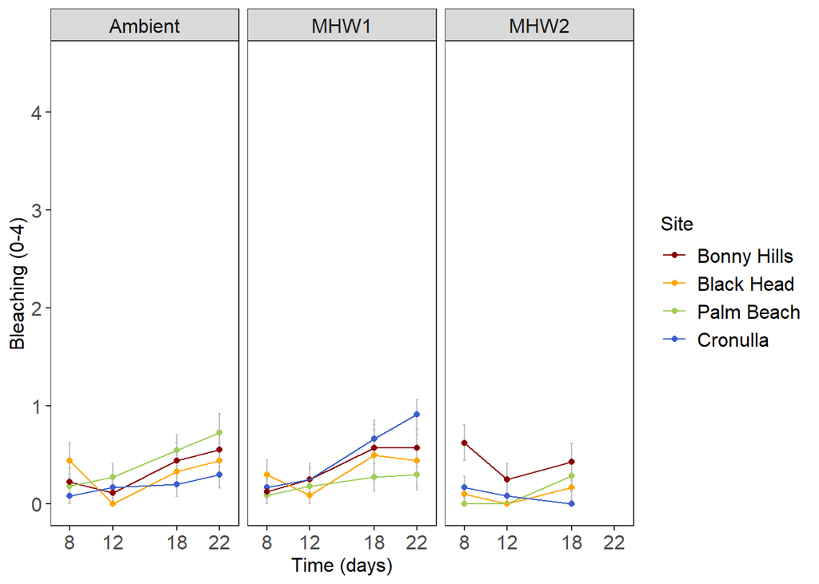

```r
Bleaching_plot <- Juv_means %>%
  filter(Day_equivalent == 8|Day_equivalent == 12|Day_equivalent == 18| Day_equivalent == 22)  %>%
ggplot(aes(x= Day_equivalent, y= Mean_bleaching, colour = Site)) +
   geom_errorbar(aes(ymin=Mean_bleaching-se_bleaching, ymax=Mean_bleaching+se_bleaching),colour = "grey", width=.2) +
  geom_point() +
  geom_line()+
Theme1 +
labs( y="Bleaching (0-4)", x="Time (days)")  +
 scale_colour_manual(values = c("darkred", "orange", "darkolivegreen3", "royalblue3"))   +
theme(strip.text.x = element_text(size = 12))+
scale_y_continuous(limits = c(0, 4.5), breaks = seq(0, 4, by = 1))+
scale_x_continuous(limits = c(7, 23), breaks = c(8, 12, 18,22))+
facet_wrap(~ factor(Treatment, c("Ambient","MHW1","MHW2")), ncol = 3)



Bleaching_plot
```

```r
ggsave("Bleaching_juv.jpeg", width = 220, height = 60, units = "mm")
```

#### 2. Statistical analyses

##### 2.1. Day 8

1. Run LMM for bleaching at day 8

```r
Juveniles_stat8_1$log_Bleaching <- log(Juveniles_stat8_1$Bleaching +1)
my_lmer<- lmer(Bleaching ~ Site*Treatment + (1|Location), data=Juveniles_stat8_1)
summary(my_lmer)
```

```
## Linear mixed model fit by REML ['lmerMod']
## Formula: Bleaching ~ Site * Treatment + (1 | Location)
##    Data: Juveniles_stat8_1
##
## REML criterion at convergence: 126.9
##
## Scaled residuals:
##      Min       1Q   Median       3Q      Max
## -1.62300 -0.52699 -0.27597  0.05107  2.51897
##
## Random effects:
##  Groups   Name        Variance Std.Dev.
##  Location (Intercept) 0.01147  0.1071
##  Residual             0.13934  0.3733
## Number of obs: 121, groups:  Location, 6
##
## Fixed effects:
##                               Estimate Std. Error t value
## (Intercept)                    0.43125    0.13262   3.252
## SiteBonny Hills               -0.20698    0.17629  -1.174
## SiteCronulla                  -0.34792    0.16519  -2.106
## SitePalm Beach                -0.23946    0.16860  -1.420
## TreatmentMHW1                 -0.13340    0.17253  -0.773
## TreatmentMHW2                 -0.34398    0.17225  -1.997
## SiteBonny Hills:TreatmentMHW1  0.05397    0.25021   0.216
## SiteCronulla:TreatmentMHW1     0.21674    0.23019   0.942
## SitePalm Beach:TreatmentMHW1   0.03002    0.23529   0.128
## SiteBonny Hills:TreatmentMHW2  0.75310    0.24976   3.015
## SiteCronulla:TreatmentMHW2     0.42731    0.22998   1.858
## SitePalm Beach:TreatmentMHW2   0.15424    0.24076   0.641
##
## Correlation of Fixed Effects:
##             (Intr) StBnnH StCrnl StPlmB TrMHW1 TrMHW2 SBH:TMHW1 SC:TMHW1
## SitBnnyHlls -0.667
## SiteCronull -0.716  0.536
## SitePalmBch -0.702  0.526  0.564
## TretmntMHW1 -0.687  0.513  0.552  0.541
## TretmntMHW2 -0.684  0.514  0.549  0.538  0.526
## StBHl:TMHW1  0.469 -0.702 -0.377 -0.368 -0.687 -0.360
## StCrn:TMHW1  0.515 -0.384 -0.719 -0.405 -0.749 -0.394  0.515
## StPBc:TMHW1  0.507 -0.378 -0.407 -0.719 -0.736 -0.388  0.503     0.551
## StBHl:TMHW2  0.469 -0.704 -0.377 -0.369 -0.360 -0.685  0.495     0.270
## StCrn:TMHW2  0.512 -0.385 -0.717 -0.403 -0.394 -0.749  0.269     0.515
## StPBc:TMHW2  0.493 -0.369 -0.396 -0.700 -0.380 -0.716  0.259     0.285
##             SPB:TMHW1 SBH:TMHW2 SC:TMHW2
## SitBnnyHlls
## SiteCronull
## SitePalmBch
## TretmntMHW1
## TretmntMHW2
## StBHl:TMHW1
## StCrn:TMHW1
## StPBc:TMHW1
## StBHl:TMHW2  0.265
## StCrn:TMHW2  0.291     0.513
## StPBc:TMHW2  0.505     0.491     0.537
```

```r
my_glmer_anova <- car::Anova(my_lmer)
my_glmer_anova
```

```
## Analysis of Deviance Table (Type II Wald chisquare tests)
##
## Response: Bleaching
##                  Chisq Df Pr(>Chisq)
## Site            7.0682  3    0.06975 .
## Treatment       0.2971  2    0.86194
## Site:Treatment 13.4601  6    0.03628 *
## ---
## Signif. codes:  0 '***' 0.001 '**' 0.01 '*' 0.05 '.' 0.1 ' ' 1
```

2. Post-hoc test

```r
emm3 <- emmeans(my_lmer, specs = pairwise ~ Treatment|Site, type = "response", adjust = "tukey")
summary(emm3)
```

```
## $emmeans
## Site = Black Head:
##  Treatment  emmean    SE   df lower.CL upper.CL
##  Ambient   0.43125 0.133 76.2   0.1664    0.696
##  MHW1      0.29785 0.126 71.6   0.0462    0.549
##  MHW2      0.08727 0.127 70.4  -0.1658    0.340
##
## Site = Bonny Hills:
##  Treatment  emmean    SE   df lower.CL upper.CL
##  Ambient   0.22427 0.132 77.2  -0.0393    0.488
##  MHW1      0.14484 0.140 81.9  -0.1343    0.424
##  MHW2      0.63339 0.140 81.8   0.3541    0.913
##
## Site = Cronulla:
##  Treatment  emmean    SE   df lower.CL upper.CL
##  Ambient   0.08333 0.116 61.7  -0.1491    0.316
##  MHW1      0.16667 0.116 61.7  -0.0658    0.399
##  MHW2      0.16667 0.116 61.7  -0.0658    0.399
##
## Site = Palm Beach:
##  Treatment  emmean    SE   df lower.CL upper.CL
##  Ambient   0.19179 0.121 66.4  -0.0497    0.433
##  MHW1      0.08840 0.121 66.4  -0.1530    0.330
##  MHW2      0.00205 0.132 77.2  -0.2615    0.266
##
## Degrees-of-freedom method: kenward-roger
## Confidence level used: 0.95
##
## $contrasts
## Site = Black Head:
##  contrast       estimate    SE  df t.ratio p.value
##  Ambient - MHW1   0.1334 0.173 105   0.771  0.7217
##  Ambient - MHW2   0.3440 0.173 105   1.992  0.1191
##  MHW1 - MHW2      0.2106 0.168 105   1.252  0.4257
##
## Site = Bonny Hills:
##  contrast       estimate    SE  df t.ratio p.value
##  Ambient - MHW1   0.0794 0.182 105   0.436  0.9006
##  Ambient - MHW2  -0.4091 0.182 105  -2.245  0.0684
##  MHW1 - MHW2     -0.4885 0.188 105  -2.602  0.0284
##
## Site = Cronulla:
##  contrast       estimate    SE  df t.ratio p.value
##  Ambient - MHW1  -0.0833 0.152 104  -0.547  0.8483
##  Ambient - MHW2  -0.0833 0.152 104  -0.547  0.8483
##  MHW1 - MHW2      0.0000 0.152 104   0.000  1.0000
##
## Site = Palm Beach:
##  contrast       estimate    SE  df t.ratio p.value
##  Ambient - MHW1   0.1034 0.160 104   0.648  0.7939
##  Ambient - MHW2   0.1897 0.168 104   1.129  0.4986
##  MHW1 - MHW2      0.0864 0.168 104   0.514  0.8648
##
## Degrees-of-freedom method: kenward-roger
## P value adjustment: tukey method for comparing a family of 3 estimates
```

```r
emm3 <- emmeans(my_lmer, specs = pairwise ~ Site|Treatment, type = "response", adjust = "tukey")
summary(emm3)
```

```
## $emmeans
## Treatment = Ambient:
##  Site         emmean    SE   df lower.CL upper.CL
##  Black Head  0.43125 0.133 76.2   0.1664    0.696
##  Bonny Hills 0.22427 0.132 77.2  -0.0393    0.488
##  Cronulla    0.08333 0.116 61.7  -0.1491    0.316
##  Palm Beach  0.19179 0.121 66.4  -0.0497    0.433
##
## Treatment = MHW1:
##  Site         emmean    SE   df lower.CL upper.CL
##  Black Head  0.29785 0.126 71.6   0.0462    0.549
##  Bonny Hills 0.14484 0.140 81.9  -0.1343    0.424
##  Cronulla    0.16667 0.116 61.7  -0.0658    0.399
##  Palm Beach  0.08840 0.121 66.4  -0.1530    0.330
##
## Treatment = MHW2:
##  Site         emmean    SE   df lower.CL upper.CL
##  Black Head  0.08727 0.127 70.4  -0.1658    0.340
##  Bonny Hills 0.63339 0.140 81.8   0.3541    0.913
##  Cronulla    0.16667 0.116 61.7  -0.0658    0.399
##  Palm Beach  0.00205 0.132 77.2  -0.2615    0.266
##
## Degrees-of-freedom method: kenward-roger
## Confidence level used: 0.95
##
## $contrasts
## Treatment = Ambient:
##  contrast                 estimate    SE  df t.ratio p.value
##  Black Head - Bonny Hills   0.2070 0.176 104   1.173  0.6452
##  Black Head - Cronulla      0.3479 0.166 105   2.102  0.1592
##  Black Head - Palm Beach    0.2395 0.169 105   1.417  0.4919
##  Bonny Hills - Cronulla     0.1409 0.165 104   0.854  0.8282
##  Bonny Hills - Palm Beach   0.0325 0.168 104   0.193  0.9974
##  Cronulla - Palm Beach     -0.1085 0.156 104  -0.695  0.8987
##
## Treatment = MHW1:
##  contrast                 estimate    SE  df t.ratio p.value
##  Black Head - Bonny Hills   0.1530 0.179 106   0.855  0.8278
##  Black Head - Cronulla      0.1312 0.160 104   0.819  0.8452
##  Black Head - Palm Beach    0.2094 0.164 105   1.280  0.5777
##  Bonny Hills - Cronulla    -0.0218 0.171 105  -0.127  0.9993
##  Bonny Hills - Palm Beach   0.0564 0.175 105   0.323  0.9883
##  Cronulla - Palm Beach      0.0783 0.156 104   0.502  0.9585
##
## Treatment = MHW2:
##  contrast                 estimate    SE  df t.ratio p.value
##  Black Head - Bonny Hills  -0.5461 0.177 104  -3.078  0.0139
##  Black Head - Cronulla     -0.0794 0.161 105  -0.494  0.9602
##  Black Head - Palm Beach    0.0852 0.172 105   0.495  0.9600
##  Bonny Hills - Cronulla     0.4667 0.171 105   2.722  0.0375
##  Bonny Hills - Palm Beach   0.6313 0.182 105   3.465  0.0042
##  Cronulla - Palm Beach      0.1646 0.165 104   0.998  0.7510
##
## Degrees-of-freedom method: kenward-roger
## P value adjustment: tukey method for comparing a family of 4 estimates
```

3. Check model assumptions

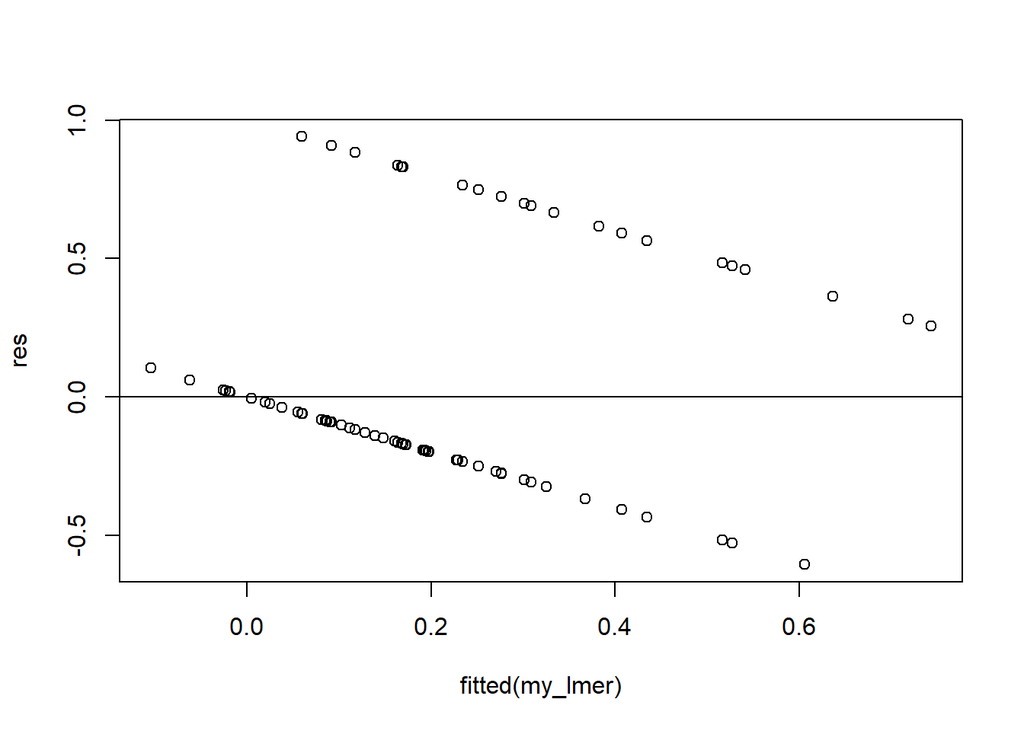

```r
res <- resid(my_lmer)
#produce residual vs. fitted plot
plot(fitted(my_lmer), res)

#add a horizontal line at 0
abline(0,0)
```

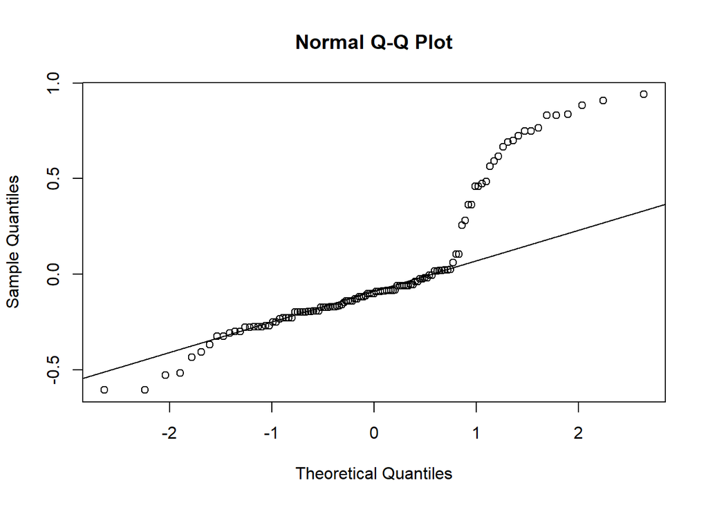

```r
#create Q-Q plot for residuals
qqnorm(res)

#add a straight diagonal line to the plot
qqline(res)
```

##### 2.2. Day 12

1. Run LMM for bleaching at day 12

```r
my_glmer<- lmer(Bleaching ~ Site*Treatment + (1|Location), data=Juveniles_stat12_1)
summary(my_glmer)
```

```
## Linear mixed model fit by REML ['lmerMod']
## Formula: Bleaching ~ Site * Treatment + (1 | Location)
##    Data: Juveniles_stat12_1
##
## REML criterion at convergence: 123.8
##
## Scaled residuals:
##     Min      1Q  Median      3Q     Max
## -0.7564 -0.5626 -0.2431 -0.0016  4.8662
##
## Random effects:
##  Groups   Name        Variance Std.Dev.
##  Location (Intercept) 0.001956 0.04423
##  Residual             0.138680 0.37240
## Number of obs: 122, groups:  Location, 6
##
## Fixed effects:
##                                 Estimate Std. Error t value
## (Intercept)                    0.0005372  0.1257047   0.004
## SiteBonny Hills                0.1146815  0.1756600   0.653
## SiteCronulla                   0.1661295  0.1644152   1.010
## SitePalm Beach                 0.2750543  0.1676603   1.641
## TreatmentMHW1                  0.0903600  0.1676571   0.539
## TreatmentMHW2                  0.0006807  0.1713531   0.004
## SiteBonny Hills:TreatmentMHW1  0.0489268  0.2466286   0.198
## SiteCronulla:TreatmentMHW1    -0.0070266  0.2263234  -0.031
## SitePalm Beach:TreatmentMHW1  -0.1841903  0.2311108  -0.797
## SiteBonny Hills:TreatmentMHW2  0.1395448  0.2490874   0.560
## SiteCronulla:TreatmentMHW2    -0.0840140  0.2290748  -0.367
## SitePalm Beach:TreatmentMHW2  -0.2721646  0.2396454  -1.136
##
## Correlation of Fixed Effects:
##             (Intr) StBnnH StCrnl StPlmB TrMHW1 TrMHW2 SBH:TMHW1 SC:TMHW1
## SitBnnyHlls -0.700
## SiteCronull -0.749  0.535
## SitePalmBch -0.735  0.525  0.562
## TretmntMHW1 -0.735  0.525  0.562  0.551
## TretmntMHW2 -0.718  0.513  0.549  0.538  0.538
## StBHl:TMHW1  0.498 -0.711 -0.381 -0.373 -0.679 -0.365
## StCrn:TMHW1  0.544 -0.389 -0.727 -0.408 -0.741 -0.399  0.503
## StPBc:TMHW1  0.534 -0.381 -0.408 -0.726 -0.726 -0.391  0.492     0.538
## StBHl:TMHW2  0.493 -0.705 -0.377 -0.370 -0.369 -0.686  0.501     0.274
## StCrn:TMHW2  0.537 -0.384 -0.717 -0.403 -0.403 -0.748  0.273     0.521
## StPBc:TMHW2  0.514 -0.367 -0.393 -0.700 -0.386 -0.715  0.261     0.286
##             SPB:TMHW1 SBH:TMHW2 SC:TMHW2
## SitBnnyHlls
## SiteCronull
## SitePalmBch
## TretmntMHW1
## TretmntMHW2
## StBHl:TMHW1
## StCrn:TMHW1
## StPBc:TMHW1
## StBHl:TMHW2  0.268
## StCrn:TMHW2  0.293     0.513
## StPBc:TMHW2  0.508     0.491     0.535
```

```r
my_glmer_anova <- car::Anova(my_glmer)
my_glmer_anova
```

```
## Analysis of Deviance Table (Type II Wald chisquare tests)
##
## Response: Bleaching
##                 Chisq Df Pr(>Chisq)
## Site           3.5106  3     0.3194
## Treatment      1.8798  2     0.3907
## Site:Treatment 3.2022  6     0.7831
```

```r
overdisp.glmer(my_glmer)
```

```
## Residual deviance: 15.103 on 109 degrees of freedom (ratio: 0.139)
```

2. Check model assumptions

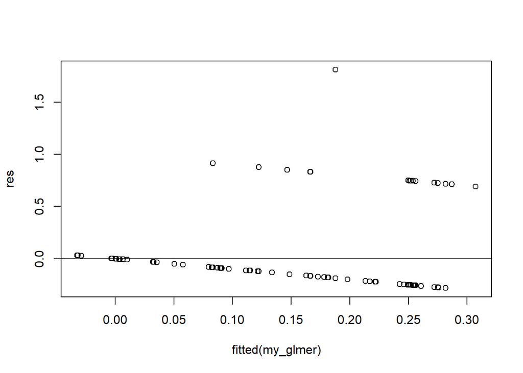

```r
res <- resid(my_glmer)
#produce residual vs. fitted plot
plot(fitted(my_glmer), res)

#add a horizontal line at 0
abline(0,0)
```

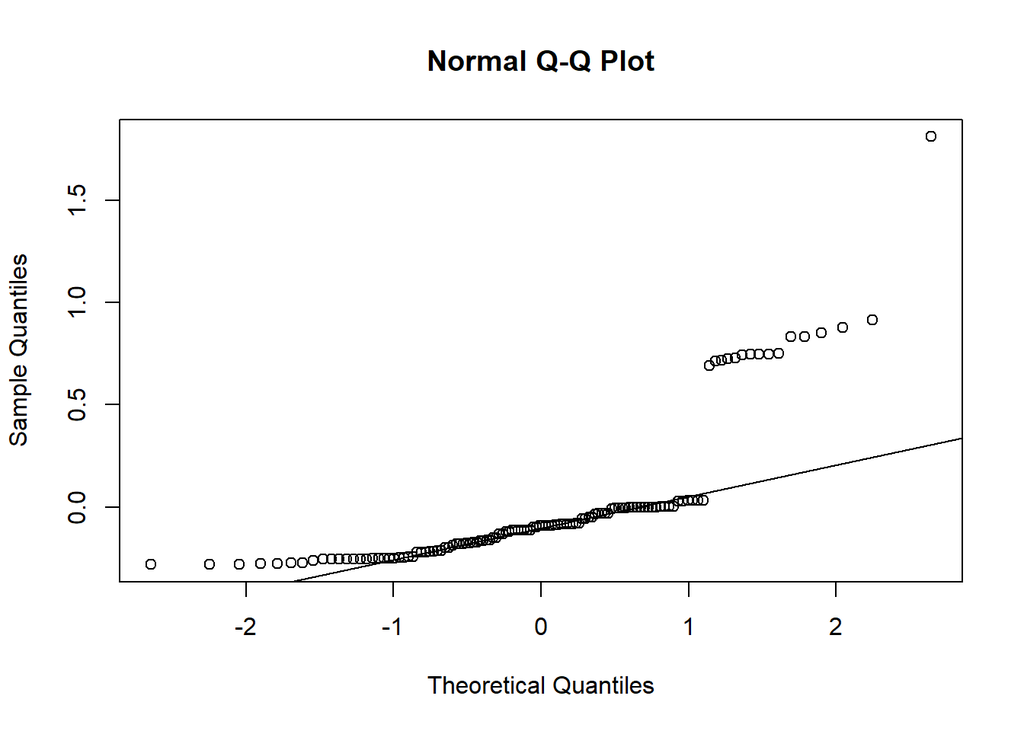

```r
#create Q-Q plot for residuals
qqnorm(res)

#add a straight diagonal line to the plot
qqline(res)
```

##### 2.3. Day 18

1. Run LMM for bleaching at day 18

```r
my_glmer1<- lmer(Bleaching ~ Site*Treatment + (1|Location), data=Juveniles_stat18_1)
summary(my_glmer1)
```

```
## Linear mixed model fit by REML ['lmerMod']
## Formula: Bleaching ~ Site * Treatment + (1 | Location)
##    Data: Juveniles_stat18_1
##
## REML criterion at convergence: 177.8
##
## Scaled residuals:
##     Min      1Q  Median      3Q     Max
## -1.3297 -0.7055 -0.3775  0.7989  2.7634
##
## Random effects:
##  Groups   Name        Variance Std.Dev.
##  Location (Intercept) 0.006089 0.07803
##  Residual             0.284844 0.53371
## Number of obs: 107, groups:  Location, 6
##
## Fixed effects:
##                               Estimate Std. Error t value
## (Intercept)                    0.33375    0.18128   1.841
## SiteBonny Hills                0.11475    0.25182   0.456
## SiteCronulla                  -0.13440    0.24534  -0.548
## SitePalm Beach                 0.21562    0.24047   0.897
## TreatmentMHW1                  0.17245    0.24596   0.701
## TreatmentMHW2                 -0.17268    0.28179  -0.613
## SiteBonny Hills:TreatmentMHW1 -0.05235    0.36452  -0.144
## SiteCronulla:TreatmentMHW1     0.29487    0.33543   0.879
## SitePalm Beach:TreatmentMHW1  -0.44815    0.33561  -1.335
## SiteBonny Hills:TreatmentMHW2  0.15827    0.38943   0.406
## SiteCronulla:TreatmentMHW2    -0.03861    0.37871  -0.102
## SitePalm Beach:TreatmentMHW2  -0.09848    0.38222  -0.258
##
## Correlation of Fixed Effects:
##             (Intr) StBnnH StCrnl StPlmB TrMHW1 TrMHW2 SBH:TMHW1 SC:TMHW1
## SitBnnyHlls -0.696
## SiteCronull -0.714  0.513
## SitePalmBch -0.731  0.525  0.538
## TretmntMHW1 -0.715  0.514  0.526  0.540
## TretmntMHW2 -0.622  0.448  0.459  0.469  0.459
## StBHl:TMHW1  0.481 -0.690 -0.354 -0.363 -0.673 -0.307
## StCrn:TMHW1  0.523 -0.376 -0.732 -0.395 -0.732 -0.336  0.493
## StPBc:TMHW1  0.526 -0.378 -0.386 -0.718 -0.735 -0.337  0.493     0.537
## StBHl:TMHW2  0.450 -0.647 -0.332 -0.340 -0.332 -0.723  0.446     0.243
## StCrn:TMHW2  0.463 -0.333 -0.648 -0.350 -0.342 -0.743  0.230     0.475
## StPBc:TMHW2  0.460 -0.330 -0.339 -0.629 -0.341 -0.736  0.229     0.249
##             SPB:TMHW1 SBH:TMHW2 SC:TMHW2
## SitBnnyHlls
## SiteCronull
## SitePalmBch
## TretmntMHW1
## TretmntMHW2
## StBHl:TMHW1
## StCrn:TMHW1
## StPBc:TMHW1
## StBHl:TMHW2  0.244
## StCrn:TMHW2  0.252     0.537
## StPBc:TMHW2  0.452     0.533     0.548
```

```r
overdisp.glmer(my_glmer1)
```

```
## Residual deviance: 26.682 on 94 degrees of freedom (ratio: 0.284)
```

```r
my_glmer_anova <- car::Anova(my_glmer1)
my_glmer_anova
```

```
## Analysis of Deviance Table (Type II Wald chisquare tests)
##
## Response: Bleaching
##                 Chisq Df Pr(>Chisq)
## Site           1.4252  3    0.69963
## Treatment      5.1810  2    0.07498 .
## Site:Treatment 7.0518  6    0.31608
## ---
## Signif. codes:  0 '***' 0.001 '**' 0.01 '*' 0.05 '.' 0.1 ' ' 1
```

2. Check model assumptions

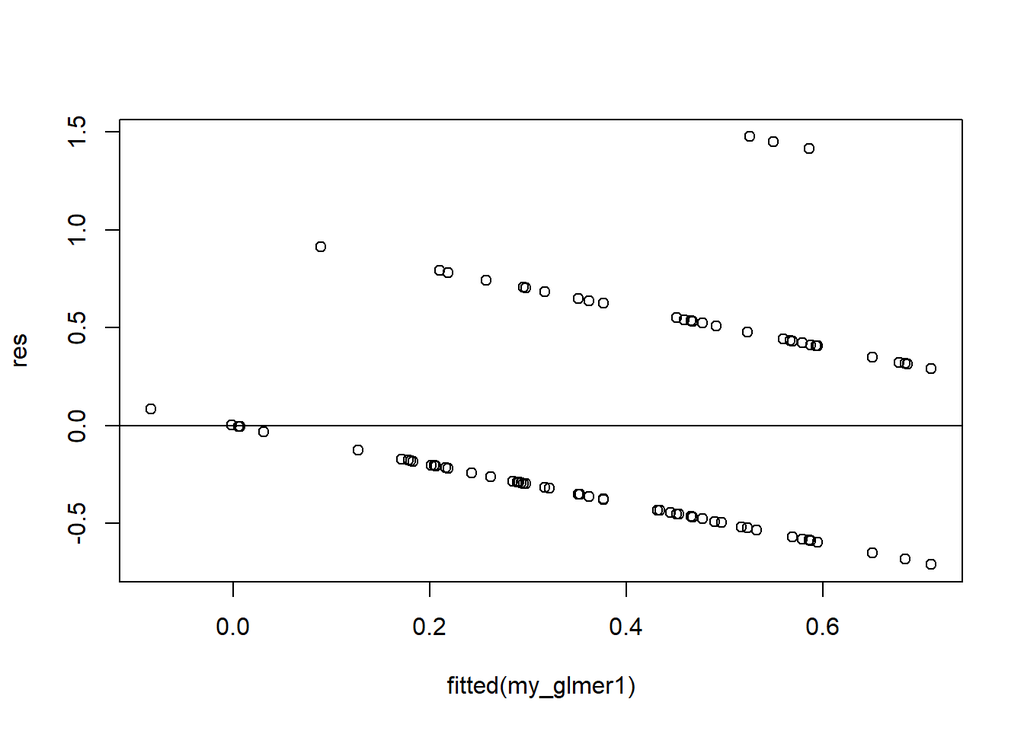

```r
res <- resid(my_glmer1)
#produce residual vs. fitted plot
plot(fitted(my_glmer1), res)

#add a horizontal line at 0
abline(0,0)
```

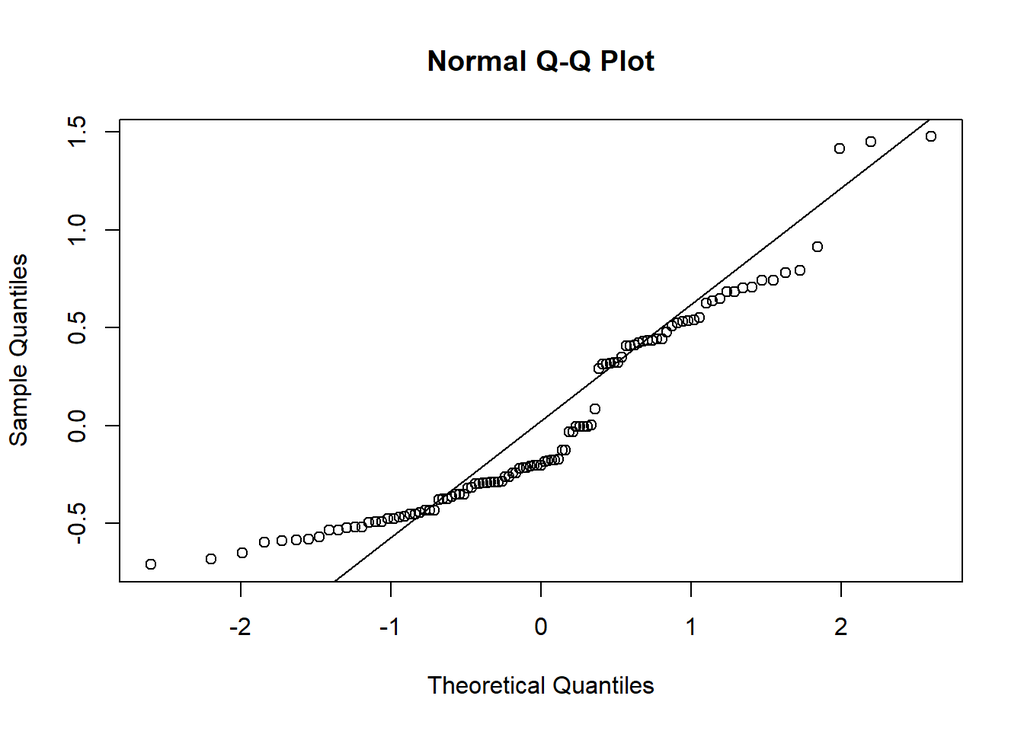

```r
#create Q-Q plot for residuals
qqnorm(res)

#add a straight diagonal line to the plot
qqline(res)
```

##### 2.4. Day 22

1. Run LMM for bleaching at day 22

```r
my_glmer1<- lmer(Bleaching ~ Site*Treatment + (1|Location), data=Juveniles_stat22_1)
summary(my_glmer1)
```

```
## Linear mixed model fit by REML ['lmerMod']
## Formula: Bleaching ~ Site * Treatment + (1 | Location)
##    Data: Juveniles_stat22_1
##
## REML criterion at convergence: 140
##
## Scaled residuals:
##     Min      1Q  Median      3Q     Max
## -1.6243 -0.7486 -0.4358  0.7251  2.6550
##
## Random effects:
##  Groups   Name        Variance Std.Dev.
##  Location (Intercept) 0.004843 0.06959
##  Residual             0.338783 0.58205
## Number of obs: 77, groups:  Location, 6
##
## Fixed effects:
##                                Estimate Std. Error t value
## (Intercept)                    0.447067   0.196546   2.275
## SiteBonny Hills                0.112237   0.274571   0.409
## SiteCronulla                  -0.146569   0.267529  -0.548
## SitePalm Beach                 0.282819   0.262096   1.079
## TreatmentMHW1                  0.002319   0.275320   0.008
## SiteBonny Hills:TreatmentMHW1  0.007431   0.402394   0.018
## SiteCronulla:TreatmentMHW1     0.613849   0.371062   1.654
## SitePalm Beach:TreatmentMHW1  -0.429557   0.375069  -1.145
##
## Correlation of Fixed Effects:
##             (Intr) StBnnH StCrnl StPlmB TrMHW1 SBH:TM SC:TMH
## SitBnnyHlls -0.699
## SiteCronull -0.718  0.513
## SitePalmBch -0.735  0.525  0.538
## TretmntMHW1 -0.700  0.500  0.513  0.526
## StBHl:TMHW1  0.478 -0.682 -0.350 -0.358 -0.683
## StCrn:TMHW1  0.518 -0.371 -0.721 -0.389 -0.741  0.506
## StPBc:TMHW1  0.515 -0.368 -0.377 -0.700 -0.734  0.501  0.544
```

```r
overdisp.glmer(my_glmer1)
```

```
## Residual deviance: 23.121 on 68 degrees of freedom (ratio: 0.34)
```

```r
my_glmer_anova <- car::Anova(my_glmer1)
my_glmer_anova
```

```
## Analysis of Deviance Table (Type II Wald chisquare tests)
##
## Response: Bleaching
##                 Chisq Df Pr(>Chisq)
## Site           1.0441  3    0.79058
## Treatment      0.2085  1    0.64792
## Site:Treatment 8.7135  3    0.03335 *
## ---
## Signif. codes:  0 '***' 0.001 '**' 0.01 '*' 0.05 '.' 0.1 ' ' 1
```

2. Post-hoc test

```r
emm3 <- emmeans(my_glmer1, specs = pairwise ~ Treatment|Site, type = "response", adjust = "tukey")
summary(emm3)
```

```
## $emmeans
## Site = Black Head:
##  Treatment emmean    SE   df lower.CL upper.CL
##  Ambient    0.447 0.199 61.2   0.0501    0.844
##  MHW1       0.449 0.199 61.4   0.0522    0.847
##
## Site = Bonny Hills:
##  Treatment emmean    SE   df lower.CL upper.CL
##  Ambient    0.559 0.197 63.4   0.1653    0.953
##  MHW1       0.569 0.227 62.7   0.1158    1.022
##
## Site = Cronulla:
##  Treatment emmean    SE   df lower.CL upper.CL
##  Ambient    0.300 0.187 61.5  -0.0735    0.674
##  MHW1       0.917 0.170 58.3   0.5756    1.258
##
## Site = Palm Beach:
##  Treatment emmean    SE   df lower.CL upper.CL
##  Ambient    0.730 0.178 59.9   0.3734    1.086
##  MHW1       0.303 0.187 61.6  -0.0713    0.677
##
## Degrees-of-freedom method: kenward-roger
## Confidence level used: 0.95
##
## $contrasts
## Site = Black Head:
##  contrast       estimate    SE   df t.ratio p.value
##  Ambient - MHW1 -0.00232 0.279 67.9  -0.008  0.9934
##
## Site = Bonny Hills:
##  contrast       estimate    SE   df t.ratio p.value
##  Ambient - MHW1 -0.00975 0.296 66.3  -0.033  0.9738
##
## Site = Cronulla:
##  contrast       estimate    SE   df t.ratio p.value
##  Ambient - MHW1 -0.61617 0.250 64.7  -2.466  0.0163
##
## Site = Palm Beach:
##  contrast       estimate    SE   df t.ratio p.value
##  Ambient - MHW1  0.42724 0.255 65.3   1.672  0.0992
##
## Degrees-of-freedom method: kenward-roger
```

```r
emm3 <- emmeans(my_glmer1, specs = pairwise ~ Site|Treatment, type = "response", adjust = "tukey")
summary(emm3)
```

```
## $emmeans
## Treatment = Ambient:
##  Site        emmean    SE   df lower.CL upper.CL
##  Black Head   0.447 0.199 61.2   0.0501    0.844
##  Bonny Hills  0.559 0.197 63.4   0.1653    0.953
##  Cronulla     0.300 0.187 61.5  -0.0735    0.674
##  Palm Beach   0.730 0.178 59.9   0.3734    1.086
##
## Treatment = MHW1:
##  Site        emmean    SE   df lower.CL upper.CL
##  Black Head   0.449 0.199 61.4   0.0522    0.847
##  Bonny Hills  0.569 0.227 62.7   0.1158    1.022
##  Cronulla     0.917 0.170 58.3   0.5756    1.258
##  Palm Beach   0.303 0.187 61.6  -0.0713    0.677
##
## Degrees-of-freedom method: kenward-roger
## Confidence level used: 0.95
##
## $contrasts
## Treatment = Ambient:
##  contrast                 estimate    SE   df t.ratio p.value
##  Black Head - Bonny Hills   -0.112 0.275 65.1  -0.408  0.9769
##  Black Head - Cronulla       0.147 0.268 64.6   0.547  0.9470
##  Black Head - Palm Beach    -0.283 0.264 66.5  -1.071  0.7085
##  Bonny Hills - Cronulla      0.259 0.268 64.5   0.966  0.7690
##  Bonny Hills - Palm Beach   -0.171 0.262 64.7  -0.650  0.9150
##  Cronulla - Palm Beach      -0.429 0.255 65.3  -1.681  0.3420
##
## Treatment = MHW1:
##  contrast                 estimate    SE   df t.ratio p.value
##  Black Head - Bonny Hills   -0.120 0.299 68.2  -0.400  0.9782
##  Black Head - Cronulla      -0.467 0.259 65.8  -1.807  0.2795
##  Black Head - Palm Beach     0.147 0.269 65.5   0.546  0.9474
##  Bonny Hills - Cronulla     -0.348 0.281 67.3  -1.238  0.6053
##  Bonny Hills - Palm Beach    0.266 0.293 68.3   0.909  0.8000
##  Cronulla - Palm Beach       0.614 0.250 64.7   2.458  0.0765
##
## Degrees-of-freedom method: kenward-roger
## P value adjustment: tukey method for comparing a family of 4 estimates
```

3. Check model assumptions

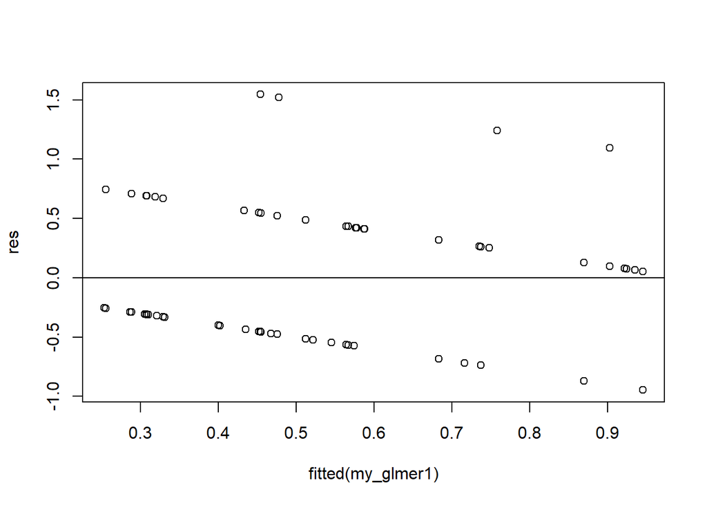

```r
res <- resid(my_glmer1)
#produce residual vs. fitted plot
plot(fitted(my_glmer1), res)

#add a horizontal line at 0
abline(0,0)
```

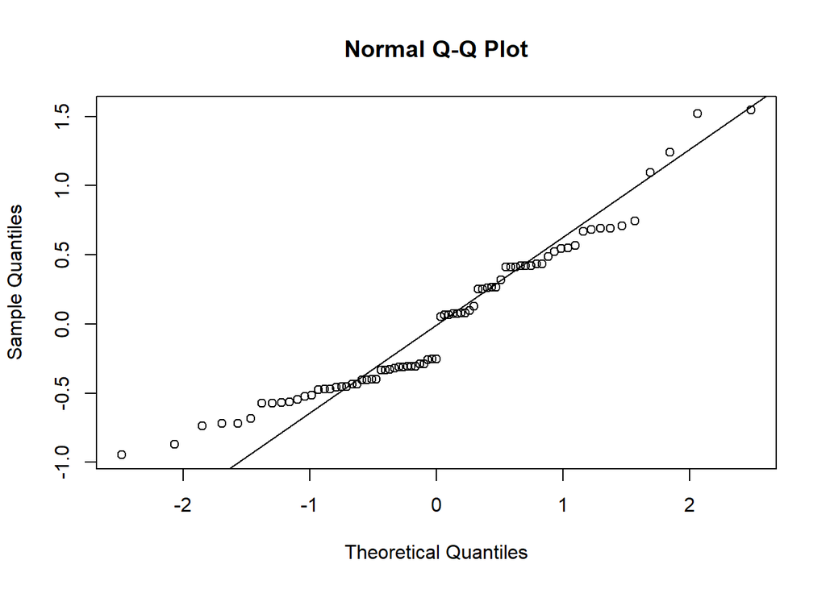

```r
#create Q-Q plot for residuals
qqnorm(res)

#add a straight diagonal line to the plot
qqline(res)
```

### **3d)** Fouling

#### 1. Visualise differences

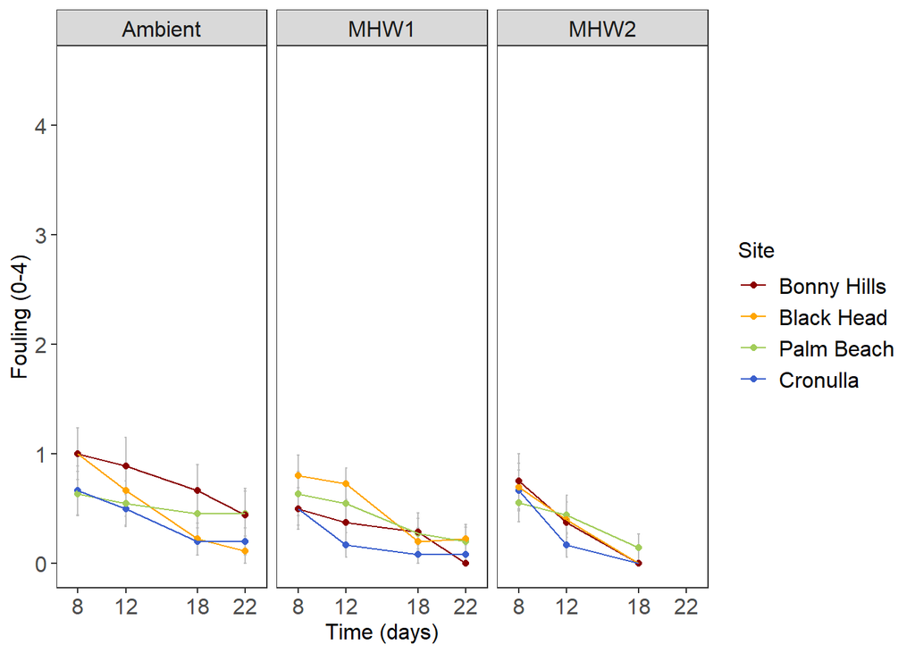

```r
Fouling_plot <- Juv_means %>%
  filter(Day_equivalent == 8|Day_equivalent == 12|Day_equivalent == 18| Day_equivalent == 22)  %>%
ggplot(aes(x= Day_equivalent, y= Mean_fouling, colour = Site)) +
   geom_errorbar(aes(ymin=Mean_fouling-se_fouling, ymax=Mean_fouling+se_fouling),colour = "grey", width=.2) +
  geom_point() +
  geom_line()+
Theme1 +
labs( y="Fouling (0-4)", x="Time (days)")  +
 scale_colour_manual(values = c("darkred", "orange", "darkolivegreen3", "royalblue3"))   +
theme(strip.text.x = element_text(size = 12))+
scale_y_continuous(limits = c(0, 4.5), breaks = seq(0, 4, by = 1))+
scale_x_continuous(limits = c(7, 23), breaks = c(8, 12, 18,22))+
facet_wrap(~ factor(Treatment, c("Ambient","MHW1","MHW2")), ncol = 3)

Fouling_plot
```

```r
ggsave("Fouling_juv.jpeg", width = 220, height = 60, units = "mm")
```

#### 2. Statistical analyses

##### 2.1. Day 8

1. Run LMM for fouling at day 8

```r
my_lmer<- lmer(Fouling ~ Site*Treatment + (1|Location), data=Juveniles_stat8_1)
```

```
## boundary (singular) fit: see help('isSingular')
```

```r
summary(my_lmer)
```

```
## Linear mixed model fit by REML ['lmerMod']
## Formula: Fouling ~ Site * Treatment + (1 | Location)
##    Data: Juveniles_stat8_1
##
## REML criterion at convergence: 244.9
##
## Scaled residuals:
##     Min      1Q  Median      3Q     Max
## -1.5254 -0.9707  0.3051  0.5547  2.0800
##
## Random effects:
##  Groups   Name        Variance Std.Dev.
##  Location (Intercept) 0.0000   0.0000
##  Residual             0.4298   0.6556
## Number of obs: 121, groups:  Location, 6
##
## Fixed effects:
##                                 Estimate Std. Error t value
## (Intercept)                    1.000e+00  2.185e-01   4.576
## SiteBonny Hills               -1.047e-15  3.090e-01   0.000
## SiteCronulla                  -3.333e-01  2.891e-01  -1.153
## SitePalm Beach                -3.636e-01  2.947e-01  -1.234
## TreatmentMHW1                 -2.000e-01  3.012e-01  -0.664
## TreatmentMHW2                 -3.000e-01  3.012e-01  -0.996
## SiteBonny Hills:TreatmentMHW1 -3.000e-01  4.384e-01  -0.684
## SiteCronulla:TreatmentMHW1     3.333e-02  4.029e-01   0.083
## SitePalm Beach:TreatmentMHW1   2.000e-01  4.109e-01   0.487
## SiteBonny Hills:TreatmentMHW2  5.000e-02  4.384e-01   0.114
## SiteCronulla:TreatmentMHW2     3.000e-01  4.029e-01   0.745
## SitePalm Beach:TreatmentMHW2   2.192e-01  4.214e-01   0.520
##
## Correlation of Fixed Effects:
##             (Intr) StBnnH StCrnl StPlmB TrMHW1 TrMHW2 SBH:TMHW1 SC:TMHW1
## SitBnnyHlls -0.707
## SiteCronull -0.756  0.535
## SitePalmBch -0.742  0.524  0.561
## TretmntMHW1 -0.725  0.513  0.548  0.538
## TretmntMHW2 -0.725  0.513  0.548  0.538  0.526
## StBHl:TMHW1  0.498 -0.705 -0.377 -0.370 -0.687 -0.362
## StCrn:TMHW1  0.542 -0.383 -0.717 -0.402 -0.748 -0.393  0.514
## StPBc:TMHW1  0.532 -0.376 -0.402 -0.717 -0.733 -0.386  0.504     0.548
## StBHl:TMHW2  0.498 -0.705 -0.377 -0.370 -0.362 -0.687  0.497     0.270
## StCrn:TMHW2  0.542 -0.383 -0.717 -0.402 -0.393 -0.748  0.270     0.515
## StPBc:TMHW2  0.519 -0.367 -0.392 -0.699 -0.376 -0.715  0.258     0.281
##             SPB:TMHW1 SBH:TMHW2 SC:TMHW2
## SitBnnyHlls
## SiteCronull
## SitePalmBch
## TretmntMHW1
## TretmntMHW2
## StBHl:TMHW1
## StCrn:TMHW1
## StPBc:TMHW1
## StBHl:TMHW2  0.265
## StCrn:TMHW2  0.288     0.514
## StPBc:TMHW2  0.501     0.491     0.534
## optimizer (nloptwrap) convergence code: 0 (OK)
## boundary (singular) fit: see help('isSingular')
```

```r
my_glmer_anova <- car::Anova(my_lmer)
my_glmer_anova
```

```
## Analysis of Deviance Table (Type II Wald chisquare tests)
##
## Response: Fouling
##                 Chisq Df Pr(>Chisq)
## Site           2.5669  3     0.4633
## Treatment      1.9772  2     0.3721
## Site:Treatment 2.1223  6     0.9081
```

2. Check model assumptions

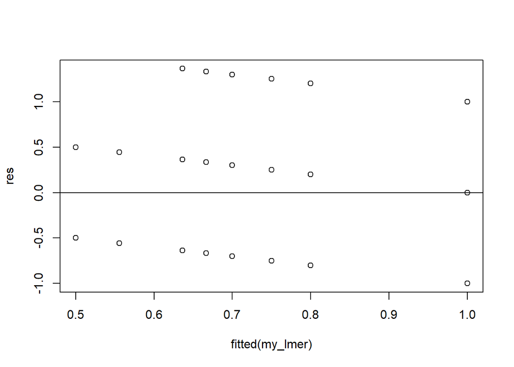

```r
res <- resid(my_lmer)
#produce residual vs. fitted plot
plot(fitted(my_lmer), res)

#add a horizontal line at 0
abline(0,0)
```

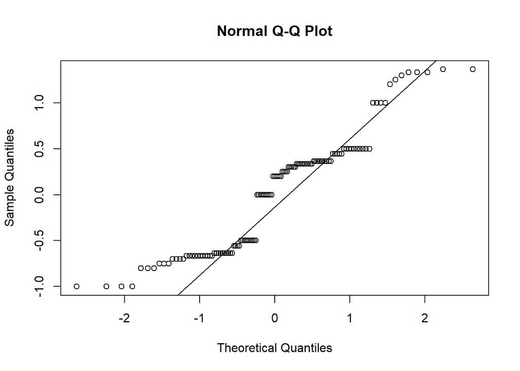

```r
#create Q-Q plot for residuals
qqnorm(res)

#add a straight diagonal line to the plot
qqline(res)
```

##### 2.2. Day 12

1. Run LMM for fouling at day 12

```r
my_glmer<- lmer(Fouling ~ Site*Treatment + (1|Location), data=Juveniles_stat12_1)
```

```
## boundary (singular) fit: see help('isSingular')
```

```r
summary(my_glmer)
```

```
## Linear mixed model fit by REML ['lmerMod']
## Formula: Fouling ~ Site * Treatment + (1 | Location)
##    Data: Juveniles_stat12_1
##
## REML criterion at convergence: 208.2
##
## Scaled residuals:
##     Min      1Q  Median      3Q     Max
## -1.6172 -0.8086 -0.3032  0.8270  2.6464
##
## Random effects:
##  Groups   Name        Variance Std.Dev.
##  Location (Intercept) 0.0000   0.0000
##  Residual             0.3021   0.5496
## Number of obs: 122, groups:  Location, 6
##
## Fixed effects:
##                               Estimate Std. Error t value
## (Intercept)                    0.66667    0.18321   3.639
## SiteBonny Hills                0.22222    0.25910   0.858
## SiteCronulla                  -0.16667    0.24237  -0.688
## SitePalm Beach                -0.12121    0.24704  -0.491
## TreatmentMHW1                  0.06061    0.24704   0.245
## TreatmentMHW2                 -0.26667    0.25254  -1.056
## SiteBonny Hills:TreatmentMHW1 -0.57449    0.36381  -1.579
## SiteCronulla:TreatmentMHW1    -0.39394    0.33374  -1.180
## SitePalm Beach:TreatmentMHW1  -0.06061    0.34052  -0.178
## SiteBonny Hills:TreatmentMHW2 -0.24722    0.36757  -0.673
## SiteCronulla:TreatmentMHW2    -0.06667    0.33783  -0.197
## SitePalm Beach:TreatmentMHW2   0.16566    0.35328   0.469
##
## Correlation of Fixed Effects:
##             (Intr) StBnnH StCrnl StPlmB TrMHW1 TrMHW2 SBH:TMHW1 SC:TMHW1
## SitBnnyHlls -0.707
## SiteCronull -0.756  0.535
## SitePalmBch -0.742  0.524  0.561
## TretmntMHW1 -0.742  0.524  0.561  0.550
## TretmntMHW2 -0.725  0.513  0.548  0.538  0.538
## StBHl:TMHW1  0.504 -0.712 -0.381 -0.373 -0.679 -0.365
## StCrn:TMHW1  0.549 -0.388 -0.726 -0.407 -0.740 -0.398  0.503
## StPBc:TMHW1  0.538 -0.380 -0.407 -0.725 -0.725 -0.390  0.493     0.537
## StBHl:TMHW2  0.498 -0.705 -0.377 -0.370 -0.370 -0.687  0.502     0.274
## StCrn:TMHW2  0.542 -0.383 -0.717 -0.402 -0.402 -0.748  0.273     0.521
## StPBc:TMHW2  0.519 -0.367 -0.392 -0.699 -0.385 -0.715  0.261     0.285
##             SPB:TMHW1 SBH:TMHW2 SC:TMHW2
## SitBnnyHlls
## SiteCronull
## SitePalmBch
## TretmntMHW1
## TretmntMHW2
## StBHl:TMHW1
## StCrn:TMHW1
## StPBc:TMHW1
## StBHl:TMHW2  0.268
## StCrn:TMHW2  0.292     0.514
## StPBc:TMHW2  0.507     0.491     0.534
## optimizer (nloptwrap) convergence code: 0 (OK)
## boundary (singular) fit: see help('isSingular')
```

```r
my_glmer_anova <- car::Anova(my_glmer)
my_glmer_anova
```

```
## Analysis of Deviance Table (Type II Wald chisquare tests)
##
## Response: Fouling
##                 Chisq Df Pr(>Chisq)
## Site           6.9582  3    0.07324 .
## Treatment      6.0994  2    0.04737 *
## Site:Treatment 4.1402  6    0.65771
## ---
## Signif. codes:  0 '***' 0.001 '**' 0.01 '*' 0.05 '.' 0.1 ' ' 1
```

```r
overdisp.glmer(my_glmer)
```

```
## Residual deviance: 33.231 on 109 degrees of freedom (ratio: 0.305)
```

2. Post-hoc test

```r
emm3 <- emmeans(my_glmer, specs = pairwise ~ Treatment, type = "response", adjust = "tukey")
```

```
## NOTE: Results may be misleading due to involvement in interactions
```

```r
summary(emm3)
```

```
## $emmeans
##  Treatment emmean     SE   df lower.CL upper.CL
##  Ambient    0.650 0.0870 35.4    0.474    0.827
##  MHW1       0.454 0.0860 35.9    0.279    0.628
##  MHW2       0.347 0.0898 36.2    0.164    0.529
##
## Results are averaged over the levels of: Site
## Degrees-of-freedom method: kenward-roger
## Confidence level used: 0.95
##
## $contrasts
##  contrast       estimate    SE  df t.ratio p.value
##  Ambient - MHW1    0.197 0.122 106   1.610  0.2460
##  Ambient - MHW2    0.304 0.125 107   2.438  0.0430
##  MHW1 - MHW2       0.107 0.124 107   0.863  0.6650
##
## Results are averaged over the levels of: Site
## Degrees-of-freedom method: kenward-roger
## P value adjustment: tukey method for comparing a family of 3 estimates
```

3. Check model assumptions

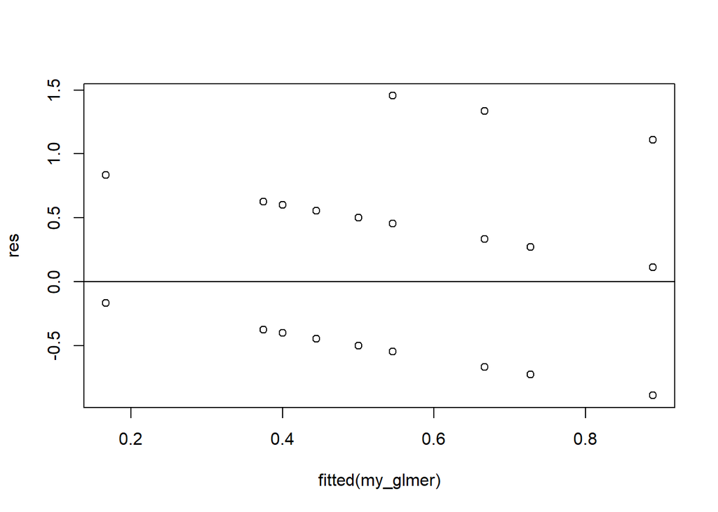

```r
res <- resid(my_glmer)
#produce residual vs. fitted plot
plot(fitted(my_glmer), res)

#add a horizontal line at 0
abline(0,0)
```

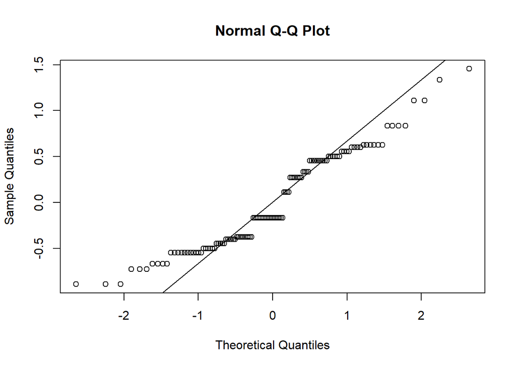

```r
#create Q-Q plot for residuals
qqnorm(res)

#add a straight diagonal line to the plot
qqline(res)
```

##### 2.3 Day 18

1. Run LMM for fouling at day 18

```r
my_glmer1<- lmer(Fouling ~ Site*Treatment + (1|Location), data=Juveniles_stat18_1)
```

```
## boundary (singular) fit: see help('isSingular')
```

```r
summary(my_glmer1)
```

```
## Linear mixed model fit by REML ['lmerMod']
## Formula: Fouling ~ Site * Treatment + (1 | Location)
##    Data: Juveniles_stat18_1
##
## REML criterion at convergence: 142
##
## Scaled residuals:
##     Min      1Q  Median      3Q     Max
## -1.4960 -0.4987 -0.1870  0.0000  3.4679
##
## Random effects:
##  Groups   Name        Variance Std.Dev.
##  Location (Intercept) 0.0000   0.0000
##  Residual             0.1986   0.4456
## Number of obs: 107, groups:  Location, 6
##
## Fixed effects:
##                               Estimate Std. Error t value
## (Intercept)                    0.22222    0.14855   1.496
## SiteBonny Hills                0.44444    0.21008   2.116
## SiteCronulla                  -0.02222    0.20476  -0.109
## SitePalm Beach                 0.23232    0.20030   1.160
## TreatmentMHW1                 -0.02222    0.20476  -0.109
## TreatmentMHW2                 -0.22222    0.23488  -0.946
## SiteBonny Hills:TreatmentMHW1 -0.35873    0.30392  -1.180
## SiteCronulla:TreatmentMHW1    -0.09444    0.27989  -0.337
## SitePalm Beach:TreatmentMHW1  -0.15960    0.27935  -0.571
## SiteBonny Hills:TreatmentMHW2 -0.44444    0.32497  -1.368
## SiteCronulla:TreatmentMHW2     0.02222    0.31599   0.070
## SitePalm Beach:TreatmentMHW2  -0.08947    0.31874  -0.281
##
## Correlation of Fixed Effects:
##             (Intr) StBnnH StCrnl StPlmB TrMHW1 TrMHW2 SBH:TMHW1 SC:TMHW1
## SitBnnyHlls -0.707
## SiteCronull -0.725  0.513
## SitePalmBch -0.742  0.524  0.538
## TretmntMHW1 -0.725  0.513  0.526  0.538
## TretmntMHW2 -0.632  0.447  0.459  0.469  0.459
## StBHl:TMHW1  0.489 -0.691 -0.355 -0.362 -0.674 -0.309
## StCrn:TMHW1  0.531 -0.375 -0.732 -0.394 -0.732 -0.336  0.493
## StPBc:TMHW1  0.532 -0.376 -0.386 -0.717 -0.733 -0.336  0.494     0.536
## StBHl:TMHW2  0.457 -0.646 -0.332 -0.339 -0.332 -0.723  0.447     0.243
## StCrn:TMHW2  0.470 -0.332 -0.648 -0.349 -0.341 -0.743  0.230     0.474
## StPBc:TMHW2  0.466 -0.330 -0.338 -0.628 -0.338 -0.737  0.228     0.247
##             SPB:TMHW1 SBH:TMHW2 SC:TMHW2
## SitBnnyHlls
## SiteCronull
## SitePalmBch
## TretmntMHW1
## TretmntMHW2
## StBHl:TMHW1
## StCrn:TMHW1
## StPBc:TMHW1
## StBHl:TMHW2  0.243
## StCrn:TMHW2  0.250     0.537
## StPBc:TMHW2  0.451     0.533     0.548
## optimizer (nloptwrap) convergence code: 0 (OK)
## boundary (singular) fit: see help('isSingular')
```

```r
overdisp.glmer(my_glmer1)
```

```
## Residual deviance: 18.867 on 94 degrees of freedom (ratio: 0.201)
```

```r
my_glmer_anova <- car::Anova(my_glmer1)
my_glmer_anova
```

```
## Analysis of Deviance Table (Type II Wald chisquare tests)
##
## Response: Fouling
##                 Chisq Df Pr(>Chisq)
## Site           5.4415  3   0.142179
## Treatment      9.9190  2   0.007016 **
## Site:Treatment 3.2595  6   0.775641
## ---
## Signif. codes:  0 '***' 0.001 '**' 0.01 '*' 0.05 '.' 0.1 ' ' 1
```

2. Post-hoc test

```r
emm3 <- emmeans(my_glmer1, specs = pairwise ~ Treatment, type = "response", adjust = "tukey")
```

```
## NOTE: Results may be misleading due to involvement in interactions
```

```r
summary(emm3)
```

```
## $emmeans
##  Treatment emmean     SE   df lower.CL upper.CL
##  Ambient   0.3859 0.0723 28.9   0.2380    0.534
##  MHW1      0.2104 0.0723 30.6   0.0628    0.358
##  MHW2      0.0357 0.0866 36.8  -0.1399    0.211
##
## Results are averaged over the levels of: Site
## Degrees-of-freedom method: kenward-roger
## Confidence level used: 0.95
##
## $contrasts
##  contrast       estimate    SE   df t.ratio p.value
##  Ambient - MHW1    0.175 0.102 92.2   1.720  0.2031
##  Ambient - MHW2    0.350 0.112 93.6   3.134  0.0065
##  MHW1 - MHW2       0.175 0.112 94.1   1.559  0.2687
##
## Results are averaged over the levels of: Site
## Degrees-of-freedom method: kenward-roger
## P value adjustment: tukey method for comparing a family of 3 estimates
```

3. Check model assumptions

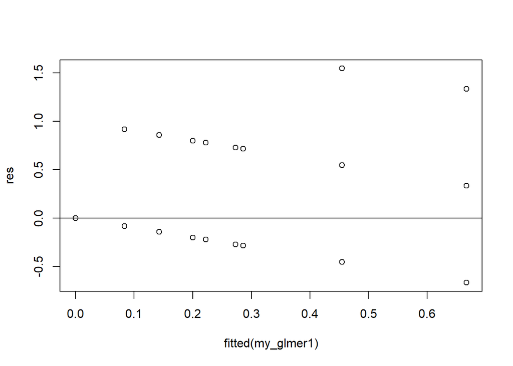

```r
res <- resid(my_glmer1)
#produce residual vs. fitted plot
plot(fitted(my_glmer1), res)

#add a horizontal line at 0
abline(0,0)
```

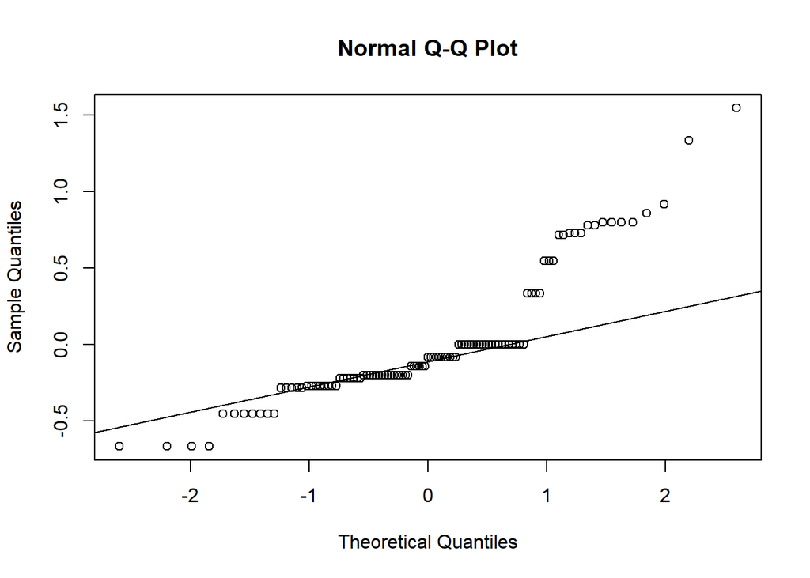

```r
#create Q-Q plot for residuals
qqnorm(res)

#add a straight diagonal line to the plot
qqline(res)
```

##### 2.3. Day 22

1. Run LMM for fouling at day 22

```r
my_glmer1<- lmer(Fouling ~ Site*Treatment + (1|Location), data=Juveniles_stat22_1)
```

```
## boundary (singular) fit: see help('isSingular')
```

```r
summary(my_glmer1)
```

```
## Linear mixed model fit by REML ['lmerMod']
## Formula: Fouling ~ Site * Treatment + (1 | Location)
##    Data: Juveniles_stat22_1
##
## REML criterion at convergence: 110.9
##
## Scaled residuals:
##     Min      1Q  Median      3Q     Max
## -0.9587 -0.4687 -0.2344  0.0000  3.2809
##
## Random effects:
##  Groups   Name        Variance Std.Dev.
##  Location (Intercept) 0.0000   0.0000
##  Residual             0.2248   0.4741
## Number of obs: 77, groups:  Location, 6
##
## Fixed effects:
##                               Estimate Std. Error t value
## (Intercept)                    0.11111    0.15804   0.703
## SiteBonny Hills                0.33333    0.22350   1.491
## SiteCronulla                   0.08889    0.21784   0.408
## SitePalm Beach                 0.34343    0.21310   1.612
## TreatmentMHW1                  0.11111    0.22350   0.497
## SiteBonny Hills:TreatmentMHW1 -0.55556    0.32718  -1.698
## SiteCronulla:TreatmentMHW1    -0.22778    0.30194  -0.754
## SitePalm Beach:TreatmentMHW1  -0.36566    0.30474  -1.200
##
## Correlation of Fixed Effects:
##             (Intr) StBnnH StCrnl StPlmB TrMHW1 SBH:TM SC:TMH
## SitBnnyHlls -0.707
## SiteCronull -0.725  0.513
## SitePalmBch -0.742  0.524  0.538
## TretmntMHW1 -0.707  0.500  0.513  0.524
## StBHl:TMHW1  0.483 -0.683 -0.350 -0.358 -0.683
## StCrn:TMHW1  0.523 -0.370 -0.721 -0.388 -0.740  0.506
## StPBc:TMHW1  0.519 -0.367 -0.376 -0.699 -0.733  0.501  0.543
## optimizer (nloptwrap) convergence code: 0 (OK)
## boundary (singular) fit: see help('isSingular')
```

```r
overdisp.glmer(my_glmer1)
```

```
## Residual deviance: 15.511 on 68 degrees of freedom (ratio: 0.228)
```

```r
my_glmer_anova <- car::Anova(my_glmer1)
my_glmer_anova
```

```
## Analysis of Deviance Table (Type II Wald chisquare tests)
##
## Response: Fouling
##                 Chisq Df Pr(>Chisq)
## Site           1.9312  3     0.5868
## Treatment      2.4106  1     0.1205
## Site:Treatment 3.1366  3     0.3710
```

2. Post-hoc test

```r
emm3 <- emmeans(my_glmer1, specs = pairwise ~ Treatment|Site, type = "response", adjust = "tukey")
summary(emm3)
```

```
## $emmeans
## Site = Black Head:
##  Treatment emmean    SE   df lower.CL upper.CL
##  Ambient   0.1111 0.160 63.2  -0.2084    0.431
##  MHW1      0.2222 0.160 63.2  -0.0977    0.542
##
## Site = Bonny Hills:
##  Treatment emmean    SE   df lower.CL upper.CL
##  Ambient   0.4444 0.159 65.4   0.1271    0.762
##  MHW1      0.0000 0.183 63.6  -0.3655    0.365
##
## Site = Cronulla:
##  Treatment emmean    SE   df lower.CL upper.CL
##  Ambient   0.2000 0.151 64.2  -0.1007    0.501
##  MHW1      0.0833 0.137 62.0  -0.1903    0.357
##
## Site = Palm Beach:
##  Treatment emmean    SE   df lower.CL upper.CL
##  Ambient   0.4545 0.143 63.0   0.1682    0.741
##  MHW1      0.2000 0.151 64.2  -0.1008    0.501
##
## Degrees-of-freedom method: kenward-roger
## Confidence level used: 0.95
##
## $contrasts
## Site = Black Head:
##  contrast       estimate    SE   df t.ratio p.value
##  Ambient - MHW1   -0.111 0.227 68.2  -0.489  0.6264
##
## Site = Bonny Hills:
##  contrast       estimate    SE   df t.ratio p.value
##  Ambient - MHW1    0.444 0.241 66.5   1.845  0.0695
##
## Site = Cronulla:
##  contrast       estimate    SE   df t.ratio p.value
##  Ambient - MHW1    0.117 0.203 64.8   0.573  0.5683
##
## Site = Palm Beach:
##  contrast       estimate    SE   df t.ratio p.value
##  Ambient - MHW1    0.255 0.208 65.4   1.224  0.2254
##
## Degrees-of-freedom method: kenward-roger
```

```r
emm3 <- emmeans(my_glmer1, specs = pairwise ~ Site|Treatment, type = "response", adjust = "tukey")
summary(emm3)
```

```
## $emmeans
## Treatment = Ambient:
##  Site        emmean    SE   df lower.CL upper.CL
##  Black Head  0.1111 0.160 63.2  -0.2084    0.431
##  Bonny Hills 0.4444 0.159 65.4   0.1271    0.762
##  Cronulla    0.2000 0.151 64.2  -0.1007    0.501
##  Palm Beach  0.4545 0.143 63.0   0.1682    0.741
##
## Treatment = MHW1:
##  Site        emmean    SE   df lower.CL upper.CL
##  Black Head  0.2222 0.160 63.2  -0.0977    0.542
##  Bonny Hills 0.0000 0.183 63.6  -0.3655    0.365
##  Cronulla    0.0833 0.137 62.0  -0.1903    0.357
##  Palm Beach  0.2000 0.151 64.2  -0.1008    0.501
##
## Degrees-of-freedom method: kenward-roger
## Confidence level used: 0.95
##
## $contrasts
## Treatment = Ambient:
##  contrast                 estimate    SE   df t.ratio p.value
##  Black Head - Bonny Hills  -0.3333 0.224 65.2  -1.487  0.4512
##  Black Head - Cronulla     -0.0889 0.218 64.7  -0.407  0.9770
##  Black Head - Palm Beach   -0.3434 0.215 66.7  -1.598  0.3868
##  Bonny Hills - Cronulla     0.2444 0.218 64.6   1.121  0.6783
##  Bonny Hills - Palm Beach  -0.0101 0.214 64.9  -0.047  1.0000
##  Cronulla - Palm Beach     -0.2545 0.208 65.4  -1.224  0.6141
##
## Treatment = MHW1:
##  contrast                 estimate    SE   df t.ratio p.value
##  Black Head - Bonny Hills   0.2222 0.244 68.5   0.913  0.7982
##  Black Head - Cronulla      0.1389 0.211 66.1   0.659  0.9119
##  Black Head - Palm Beach    0.0222 0.219 65.7   0.102  0.9996
##  Bonny Hills - Cronulla    -0.0833 0.228 67.6  -0.365  0.9833
##  Bonny Hills - Palm Beach  -0.2000 0.238 68.6  -0.840  0.8353
##  Cronulla - Palm Beach     -0.1167 0.203 64.8  -0.573  0.9397
##
## Degrees-of-freedom method: kenward-roger
## P value adjustment: tukey method for comparing a family of 4 estimates
```

3. Check model assumptions

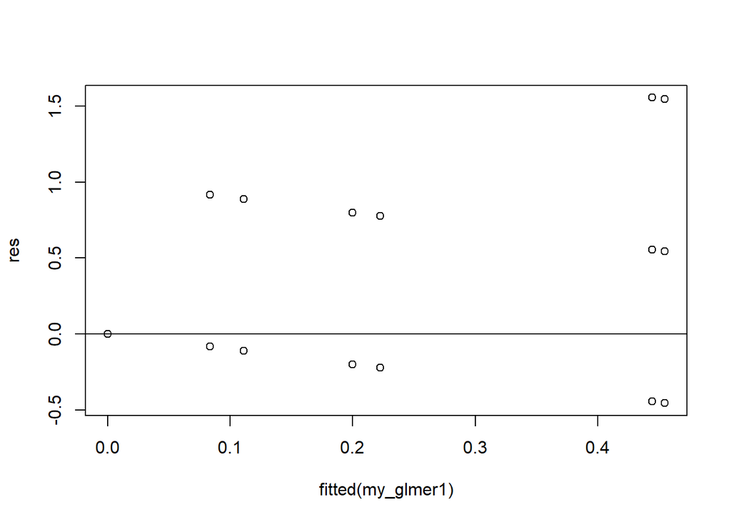

```r
res <- resid(my_glmer1)
#produce residual vs. fitted plot
plot(fitted(my_glmer1), res)

#add a horizontal line at 0
abline(0,0)
```

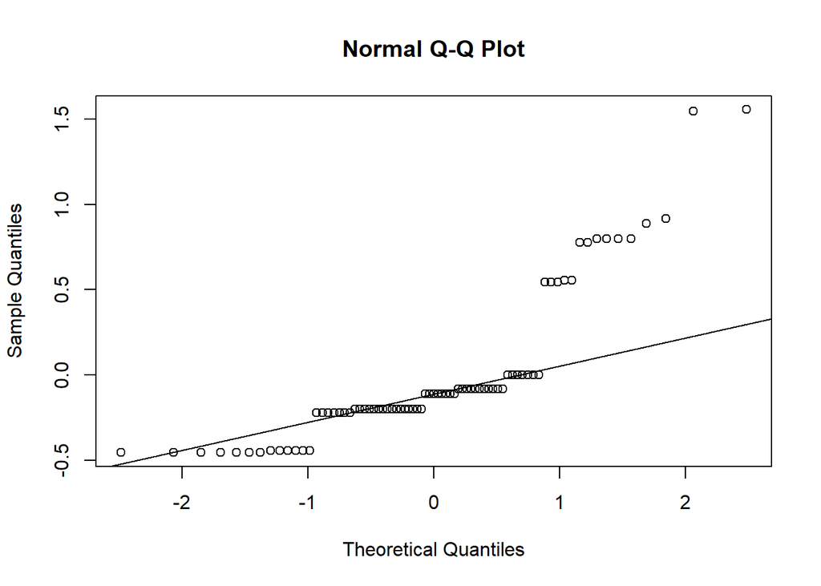

```r
#create Q-Q plot for residuals
qqnorm(res)

#add a straight diagonal line to the plot
qqline(res)
```

### **3e)** Green colouration

#### 1. Visualise differences

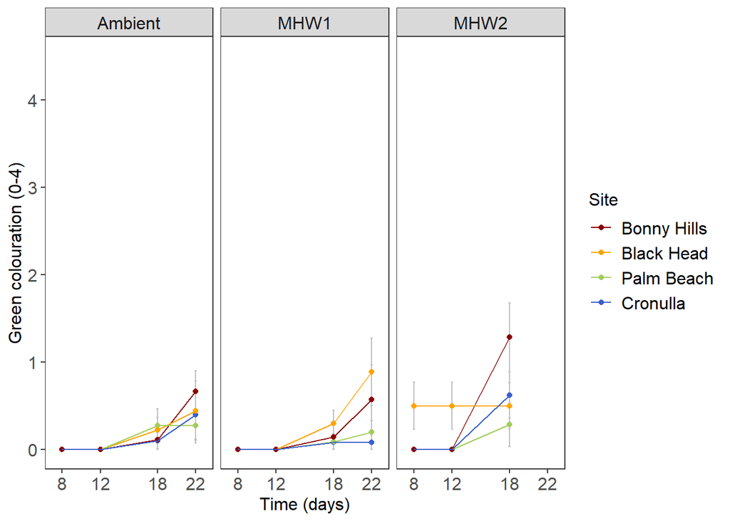

```r
Green_plot <- Juv_means %>%
  filter(Day_equivalent == 8|Day_equivalent == 12|Day_equivalent == 18| Day_equivalent == 22)  %>%
ggplot(aes(x= Day_equivalent, y= Mean_green, colour = Site)) +
   geom_errorbar(aes(ymin=Mean_green-se_green, ymax=Mean_green+se_green),colour = "grey", width=.2) +
  geom_point() +
  geom_line()+
Theme1 +
labs( y="Green colouration (0-4)", x="Time (days)")  +
 scale_colour_manual(values = c("darkred", "orange", "darkolivegreen3", "royalblue3"))   +
theme(strip.text.x = element_text(size = 12))+
scale_y_continuous(limits = c(0, 4.5), breaks = seq(0, 4, by = 1))+
scale_x_continuous(limits = c(7, 23), breaks = c(8, 12, 18,22))+
facet_wrap(~ factor(Treatment, c("Ambient","MHW1","MHW2")), ncol = 3)



Green_plot
```

```r
ggsave("Green_juv.jpeg", width = 220, height = 60, units = "mm")
```

#### 2. Statistical analyses

##### 2.1. Day 8

1. Run LMM for green colouration at day 8

```r
my_lmer<- lmer(Green ~ Site*Treatment + (1|Location), data=Juveniles_stat8_1)
```

```
## boundary (singular) fit: see help('isSingular')
```

```r
summary(my_lmer)
```

```
## Linear mixed model fit by REML ['lmerMod']
## Formula: Green ~ Site * Treatment + (1 | Location)
##    Data: Juveniles_stat8_1
##
## REML criterion at convergence: 29.6
##
## Scaled residuals:
##    Min     1Q Median     3Q    Max
## -2.047  0.000  0.000  0.000  6.143
##
## Random effects:
##  Groups   Name        Variance Std.Dev.
##  Location (Intercept) 0.00000  0.0000
##  Residual             0.05963  0.2442
## Number of obs: 121, groups:  Location, 6
##
## Fixed effects:
##                                 Estimate Std. Error t value
## (Intercept)                   -1.238e-16  8.140e-02   0.000
## SiteBonny Hills                1.773e-16  1.151e-01   0.000
## SiteCronulla                   1.404e-16  1.077e-01   0.000
## SitePalm Beach                 0.000e+00  1.098e-01   0.000
## TreatmentMHW1                  1.173e-16  1.122e-01   0.000
## TreatmentMHW2                  5.000e-01  1.122e-01   4.456
## SiteBonny Hills:TreatmentMHW1 -1.598e-16  1.633e-01   0.000
## SiteCronulla:TreatmentMHW1    -9.887e-17  1.501e-01   0.000
## SitePalm Beach:TreatmentMHW1   6.018e-17  1.531e-01   0.000
## SiteBonny Hills:TreatmentMHW2 -5.000e-01  1.633e-01  -3.062
## SiteCronulla:TreatmentMHW2    -5.000e-01  1.501e-01  -3.331
## SitePalm Beach:TreatmentMHW2  -5.000e-01  1.570e-01  -3.186
##
## Correlation of Fixed Effects:
##             (Intr) StBnnH StCrnl StPlmB TrMHW1 TrMHW2 SBH:TMHW1 SC:TMHW1
## SitBnnyHlls -0.707
## SiteCronull -0.756  0.535
## SitePalmBch -0.742  0.524  0.561
## TretmntMHW1 -0.725  0.513  0.548  0.538
## TretmntMHW2 -0.725  0.513  0.548  0.538  0.526
## StBHl:TMHW1  0.498 -0.705 -0.377 -0.370 -0.687 -0.362
## StCrn:TMHW1  0.542 -0.383 -0.717 -0.402 -0.748 -0.393  0.514
## StPBc:TMHW1  0.532 -0.376 -0.402 -0.717 -0.733 -0.386  0.504     0.548
## StBHl:TMHW2  0.498 -0.705 -0.377 -0.370 -0.362 -0.687  0.497     0.270
## StCrn:TMHW2  0.542 -0.383 -0.717 -0.402 -0.393 -0.748  0.270     0.515
## StPBc:TMHW2  0.519 -0.367 -0.392 -0.699 -0.376 -0.715  0.258     0.281
##             SPB:TMHW1 SBH:TMHW2 SC:TMHW2
## SitBnnyHlls
## SiteCronull
## SitePalmBch
## TretmntMHW1
## TretmntMHW2
## StBHl:TMHW1
## StCrn:TMHW1
## StPBc:TMHW1
## StBHl:TMHW2  0.265
## StCrn:TMHW2  0.288     0.514
## StPBc:TMHW2  0.501     0.491     0.534
## optimizer (nloptwrap) convergence code: 0 (OK)
## boundary (singular) fit: see help('isSingular')
```

```r
my_glmer_anova <- car::Anova(my_lmer)
my_glmer_anova
```

```
## Analysis of Deviance Table (Type II Wald chisquare tests)
##
## Response: Green
##                  Chisq Df Pr(>Chisq)
## Site           10.5346  3    0.01453 *
## Treatment       6.8278  2    0.03291 *
## Site:Treatment 20.6390  6    0.00213 **
## ---
## Signif. codes:  0 '***' 0.001 '**' 0.01 '*' 0.05 '.' 0.1 ' ' 1
```

2. Post-hoc test

```r
emm3 <- emmeans(my_lmer, specs = pairwise ~ Treatment|Site, type = "response", adjust = "tukey")
summary(emm3)
```

```
## $emmeans
## Site = Black Head:
##  Treatment emmean     SE  df lower.CL upper.CL
##  Ambient      0.0 0.0820 103   -0.163    0.163
##  MHW1         0.0 0.0774 104   -0.154    0.154
##  MHW2         0.5 0.0777 102    0.346    0.654
##
## Site = Bonny Hills:
##  Treatment emmean     SE  df lower.CL upper.CL
##  Ambient      0.0 0.0817 105   -0.162    0.162
##  MHW1         0.0 0.0870 105   -0.173    0.173
##  MHW2         0.0 0.0870 105   -0.173    0.173
##
## Site = Cronulla:
##  Treatment emmean     SE  df lower.CL upper.CL
##  Ambient      0.0 0.0705 102   -0.140    0.140
##  MHW1         0.0 0.0705 102   -0.140    0.140
##  MHW2         0.0 0.0705 102   -0.140    0.140
##
## Site = Palm Beach:
##  Treatment emmean     SE  df lower.CL upper.CL
##  Ambient      0.0 0.0737 103   -0.146    0.146
##  MHW1         0.0 0.0737 103   -0.146    0.146
##  MHW2         0.0 0.0817 105   -0.162    0.162
##
## Degrees-of-freedom method: kenward-roger
## Confidence level used: 0.95
##
## $contrasts
## Site = Black Head:
##  contrast       estimate     SE  df t.ratio p.value
##  Ambient - MHW1      0.0 0.1131 107   0.000  1.0000
##  Ambient - MHW2     -0.5 0.1127 106  -4.435  0.0001
##  MHW1 - MHW2        -0.5 0.1098 107  -4.553  <.0001
##
## Site = Bonny Hills:
##  contrast       estimate     SE  df t.ratio p.value
##  Ambient - MHW1      0.0 0.1191 106   0.000  1.0000
##  Ambient - MHW2      0.0 0.1191 106   0.000  1.0000
##  MHW1 - MHW2         0.0 0.1227 106   0.000  1.0000
##
## Site = Cronulla:
##  contrast       estimate     SE  df t.ratio p.value
##  Ambient - MHW1      0.0 0.0997 104   0.000  1.0000
##  Ambient - MHW2      0.0 0.0997 104   0.000  1.0000
##  MHW1 - MHW2         0.0 0.0997 104   0.000  1.0000
##
## Site = Palm Beach:
##  contrast       estimate     SE  df t.ratio p.value
##  Ambient - MHW1      0.0 0.1043 105   0.000  1.0000
##  Ambient - MHW2      0.0 0.1099 105   0.000  1.0000
##  MHW1 - MHW2         0.0 0.1099 105   0.000  1.0000
##
## Degrees-of-freedom method: kenward-roger
## P value adjustment: tukey method for comparing a family of 3 estimates
```

```r
emm3 <- emmeans(my_lmer, specs = pairwise ~ Site|Treatment, type = "response", adjust = "tukey")
summary(emm3)
```

```
## $emmeans
## Treatment = Ambient:
##  Site        emmean     SE  df lower.CL upper.CL
##  Black Head     0.0 0.0820 103   -0.163    0.163
##  Bonny Hills    0.0 0.0817 105   -0.162    0.162
##  Cronulla       0.0 0.0705 102   -0.140    0.140
##  Palm Beach     0.0 0.0737 103   -0.146    0.146
##
## Treatment = MHW1:
##  Site        emmean     SE  df lower.CL upper.CL
##  Black Head     0.0 0.0774 104   -0.154    0.154
##  Bonny Hills    0.0 0.0870 105   -0.173    0.173
##  Cronulla       0.0 0.0705 102   -0.140    0.140
##  Palm Beach     0.0 0.0737 103   -0.146    0.146
##
## Treatment = MHW2:
##  Site        emmean     SE  df lower.CL upper.CL
##  Black Head     0.5 0.0777 102    0.346    0.654
##  Bonny Hills    0.0 0.0870 105   -0.173    0.173
##  Cronulla       0.0 0.0705 102   -0.140    0.140
##  Palm Beach     0.0 0.0817 105   -0.162    0.162
##
## Degrees-of-freedom method: kenward-roger
## Confidence level used: 0.95
##
## $contrasts
## Treatment = Ambient:
##  contrast                 estimate    SE  df t.ratio p.value
##  Black Head - Bonny Hills      0.0 0.115 105   0.000  1.0000
##  Black Head - Cronulla         0.0 0.108 106   0.000  1.0000
##  Black Head - Palm Beach       0.0 0.110 107   0.000  1.0000
##  Bonny Hills - Cronulla        0.0 0.108 105   0.000  1.0000
##  Bonny Hills - Palm Beach      0.0 0.110 105   0.000  1.0000
##  Cronulla - Palm Beach         0.0 0.102 104   0.000  1.0000
##
## Treatment = MHW1:
##  contrast                 estimate    SE  df t.ratio p.value
##  Black Head - Bonny Hills      0.0 0.117 108   0.000  1.0000
##  Black Head - Cronulla         0.0 0.105 105   0.000  1.0000
##  Black Head - Palm Beach       0.0 0.107 105   0.000  1.0000
##  Bonny Hills - Cronulla        0.0 0.112 106   0.000  1.0000
##  Bonny Hills - Palm Beach      0.0 0.114 107   0.000  1.0000
##  Cronulla - Palm Beach         0.0 0.102 104   0.000  1.0000
##
## Treatment = MHW2:
##  contrast                 estimate    SE  df t.ratio p.value
##  Black Head - Bonny Hills      0.5 0.116 105   4.309  0.0002
##  Black Head - Cronulla         0.5 0.105 106   4.767  <.0001
##  Black Head - Palm Beach       0.5 0.112 105   4.445  0.0001
##  Bonny Hills - Cronulla        0.0 0.112 106   0.000  1.0000
##  Bonny Hills - Palm Beach      0.0 0.119 106   0.000  1.0000
##  Cronulla - Palm Beach         0.0 0.108 105   0.000  1.0000
##
## Degrees-of-freedom method: kenward-roger
## P value adjustment: tukey method for comparing a family of 4 estimates
```

3. Check model assumptions

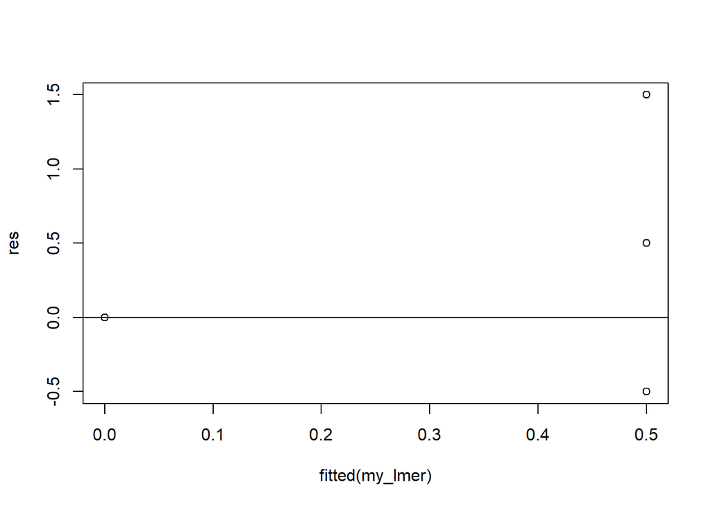

```r
res <- resid(my_lmer)
#produce residual vs. fitted plot
plot(fitted(my_lmer), res)

#add a horizontal line at 0
abline(0,0)
```

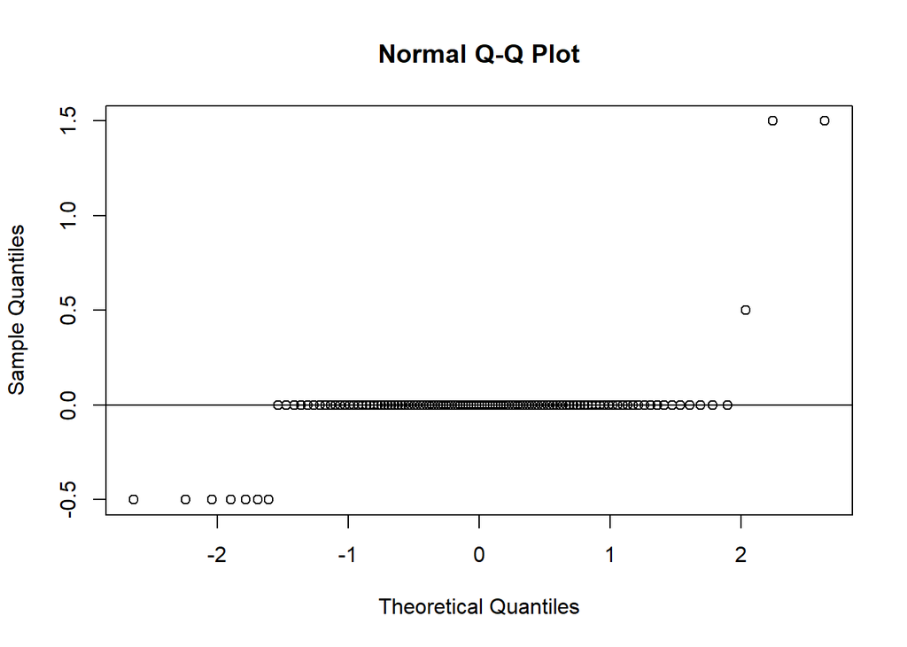

```r
#create Q-Q plot for residuals
qqnorm(res)

#add a straight diagonal line to the plot
qqline(res)
```

##### 2.2. Day 12

1. Run LMM for green colouration at day 12

```r
my_glmer<- lmer(Green ~ Site*Treatment + (1|Location), data=Juveniles_stat12_1)
```

```
## boundary (singular) fit: see help('isSingular')
```

```r
summary(my_glmer)
```

```
## Linear mixed model fit by REML ['lmerMod']
## Formula: Green ~ Site * Treatment + (1 | Location)
##    Data: Juveniles_stat12_1
##
## REML criterion at convergence: 28.7
##
## Scaled residuals:
##    Min     1Q Median     3Q    Max
## -2.057  0.000  0.000  0.000  6.171
##
## Random effects:
##  Groups   Name        Variance Std.Dev.
##  Location (Intercept) 0.00000  0.0000
##  Residual             0.05909  0.2431
## Number of obs: 122, groups:  Location, 6
##
## Fixed effects:
##                                 Estimate Std. Error t value
## (Intercept)                   -7.935e-17  8.103e-02   0.000
## SiteBonny Hills                1.490e-16  1.146e-01   0.000
## SiteCronulla                   8.670e-17  1.072e-01   0.000
## SitePalm Beach                 1.706e-16  1.093e-01   0.000
## TreatmentMHW1                 -1.058e-17  1.093e-01   0.000
## TreatmentMHW2                  5.000e-01  1.117e-01   4.477
## SiteBonny Hills:TreatmentMHW1 -5.315e-17  1.609e-01   0.000
## SiteCronulla:TreatmentMHW1     0.000e+00  1.476e-01   0.000
## SitePalm Beach:TreatmentMHW1  -1.185e-16  1.506e-01   0.000
## SiteBonny Hills:TreatmentMHW2 -5.000e-01  1.626e-01  -3.076
## SiteCronulla:TreatmentMHW2    -5.000e-01  1.494e-01  -3.347
## SitePalm Beach:TreatmentMHW2  -5.000e-01  1.562e-01  -3.200
##
## Correlation of Fixed Effects:
##             (Intr) StBnnH StCrnl StPlmB TrMHW1 TrMHW2 SBH:TMHW1 SC:TMHW1
## SitBnnyHlls -0.707
## SiteCronull -0.756  0.535
## SitePalmBch -0.742  0.524  0.561
## TretmntMHW1 -0.742  0.524  0.561  0.550
## TretmntMHW2 -0.725  0.513  0.548  0.538  0.538
## StBHl:TMHW1  0.504 -0.712 -0.381 -0.373 -0.679 -0.365
## StCrn:TMHW1  0.549 -0.388 -0.726 -0.407 -0.740 -0.398  0.503
## StPBc:TMHW1  0.538 -0.380 -0.407 -0.725 -0.725 -0.390  0.493     0.537
## StBHl:TMHW2  0.498 -0.705 -0.377 -0.370 -0.370 -0.687  0.502     0.274
## StCrn:TMHW2  0.542 -0.383 -0.717 -0.402 -0.402 -0.748  0.273     0.521
## StPBc:TMHW2  0.519 -0.367 -0.392 -0.699 -0.385 -0.715  0.261     0.285
##             SPB:TMHW1 SBH:TMHW2 SC:TMHW2
## SitBnnyHlls
## SiteCronull
## SitePalmBch
## TretmntMHW1
## TretmntMHW2
## StBHl:TMHW1
## StCrn:TMHW1
## StPBc:TMHW1
## StBHl:TMHW2  0.268
## StCrn:TMHW2  0.292     0.514
## StPBc:TMHW2  0.507     0.491     0.534
## optimizer (nloptwrap) convergence code: 0 (OK)
## boundary (singular) fit: see help('isSingular')
```

```r
my_glmer_anova <- car::Anova(my_glmer)
my_glmer_anova
```

```
## Analysis of Deviance Table (Type II Wald chisquare tests)
##
## Response: Green
##                  Chisq Df Pr(>Chisq)
## Site           10.3689  3   0.015677 *
## Treatment       7.1145  2   0.028518 *
## Site:Treatment 21.0907  6   0.001767 **
## ---
## Signif. codes:  0 '***' 0.001 '**' 0.01 '*' 0.05 '.' 0.1 ' ' 1
```

```r
overdisp.glmer(my_glmer)
```

```
## Residual deviance: 6.5 on 109 degrees of freedom (ratio: 0.06)
```

2. Post-hoc test

```r
emm3 <- emmeans(my_glmer, specs = pairwise ~ Treatment|Site, type = "response", adjust = "tukey")
summary(emm3)
```

```
## $emmeans
## Site = Black Head:
##  Treatment emmean     SE  df lower.CL upper.CL
##  Ambient      0.0 0.0816 104   -0.162    0.162
##  MHW1         0.0 0.0734 104   -0.146    0.146
##  MHW2         0.5 0.0773 103    0.347    0.653
##
## Site = Bonny Hills:
##  Treatment emmean     SE  df lower.CL upper.CL
##  Ambient      0.0 0.0813 106   -0.161    0.161
##  MHW1         0.0 0.0866 106   -0.172    0.172
##  MHW2         0.0 0.0866 106   -0.172    0.172
##
## Site = Cronulla:
##  Treatment emmean     SE  df lower.CL upper.CL
##  Ambient      0.0 0.0702 103   -0.139    0.139
##  MHW1         0.0 0.0702 103   -0.139    0.139
##  MHW2         0.0 0.0702 103   -0.139    0.139
##
## Site = Palm Beach:
##  Treatment emmean     SE  df lower.CL upper.CL
##  Ambient      0.0 0.0734 104   -0.146    0.146
##  MHW1         0.0 0.0734 104   -0.146    0.146
##  MHW2         0.0 0.0813 106   -0.161    0.161
##
## Degrees-of-freedom method: kenward-roger
## Confidence level used: 0.95
##
## $contrasts
## Site = Black Head:
##  contrast       estimate     SE  df t.ratio p.value
##  Ambient - MHW1      0.0 0.1099 108   0.000  1.0000
##  Ambient - MHW2     -0.5 0.1122 107  -4.456  0.0001
##  MHW1 - MHW2        -0.5 0.1067 107  -4.688  <.0001
##
## Site = Bonny Hills:
##  contrast       estimate     SE  df t.ratio p.value
##  Ambient - MHW1      0.0 0.1185 107   0.000  1.0000
##  Ambient - MHW2      0.0 0.1185 107   0.000  1.0000
##  MHW1 - MHW2         0.0 0.1221 107   0.000  1.0000
##
## Site = Cronulla:
##  contrast       estimate     SE  df t.ratio p.value
##  Ambient - MHW1      0.0 0.0992 105   0.000  1.0000
##  Ambient - MHW2      0.0 0.0992 105   0.000  1.0000
##  MHW1 - MHW2         0.0 0.0992 105   0.000  1.0000
##
## Site = Palm Beach:
##  contrast       estimate     SE  df t.ratio p.value
##  Ambient - MHW1      0.0 0.1038 106   0.000  1.0000
##  Ambient - MHW2      0.0 0.1094 106   0.000  1.0000
##  MHW1 - MHW2         0.0 0.1094 106   0.000  1.0000
##
## Degrees-of-freedom method: kenward-roger
## P value adjustment: tukey method for comparing a family of 3 estimates
```

```r
emm3 <- emmeans(my_glmer, specs = pairwise ~ Site|Treatment, type = "response", adjust = "tukey")
summary(emm3)
```

```
## $emmeans
## Treatment = Ambient:
##  Site        emmean     SE  df lower.CL upper.CL
##  Black Head     0.0 0.0816 104   -0.162    0.162
##  Bonny Hills    0.0 0.0813 106   -0.161    0.161
##  Cronulla       0.0 0.0702 103   -0.139    0.139
##  Palm Beach     0.0 0.0734 104   -0.146    0.146
##
## Treatment = MHW1:
##  Site        emmean     SE  df lower.CL upper.CL
##  Black Head     0.0 0.0734 104   -0.146    0.146
##  Bonny Hills    0.0 0.0866 106   -0.172    0.172
##  Cronulla       0.0 0.0702 103   -0.139    0.139
##  Palm Beach     0.0 0.0734 104   -0.146    0.146
##
## Treatment = MHW2:
##  Site        emmean     SE  df lower.CL upper.CL
##  Black Head     0.5 0.0773 103    0.347    0.653
##  Bonny Hills    0.0 0.0866 106   -0.172    0.172
##  Cronulla       0.0 0.0702 103   -0.139    0.139
##  Palm Beach     0.0 0.0813 106   -0.161    0.161
##
## Degrees-of-freedom method: kenward-roger
## Confidence level used: 0.95
##
## $contrasts
## Treatment = Ambient:
##  contrast                 estimate    SE  df t.ratio p.value
##  Black Head - Bonny Hills      0.0 0.115 106   0.000  1.0000
##  Black Head - Cronulla         0.0 0.108 107   0.000  1.0000
##  Black Head - Palm Beach       0.0 0.110 108   0.000  1.0000
##  Bonny Hills - Cronulla        0.0 0.107 106   0.000  1.0000
##  Bonny Hills - Palm Beach      0.0 0.109 106   0.000  1.0000
##  Cronulla - Palm Beach         0.0 0.102 106   0.000  1.0000
##
## Treatment = MHW1:
##  contrast                 estimate    SE  df t.ratio p.value
##  Black Head - Bonny Hills      0.0 0.114 108   0.000  1.0000
##  Black Head - Cronulla         0.0 0.102 106   0.000  1.0000
##  Black Head - Palm Beach       0.0 0.104 106   0.000  1.0000
##  Bonny Hills - Cronulla        0.0 0.111 107   0.000  1.0000
##  Bonny Hills - Palm Beach      0.0 0.114 108   0.000  1.0000
##  Cronulla - Palm Beach         0.0 0.102 106   0.000  1.0000
##
## Treatment = MHW2:
##  contrast                 estimate    SE  df t.ratio p.value
##  Black Head - Bonny Hills      0.5 0.116 106   4.329  0.0002
##  Black Head - Cronulla         0.5 0.104 107   4.789  <.0001
##  Black Head - Palm Beach       0.5 0.112 106   4.465  0.0001
##  Bonny Hills - Cronulla        0.0 0.111 107   0.000  1.0000
##  Bonny Hills - Palm Beach      0.0 0.119 107   0.000  1.0000
##  Cronulla - Palm Beach         0.0 0.107 106   0.000  1.0000
##
## Degrees-of-freedom method: kenward-roger
## P value adjustment: tukey method for comparing a family of 4 estimates
```

3. Check model assumptions

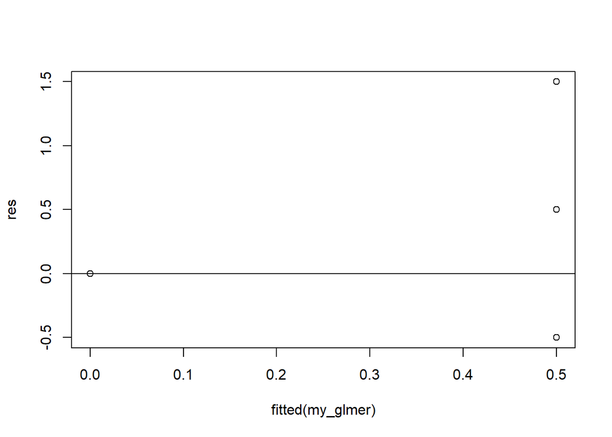

```r
res <- resid(my_glmer)
#produce residual vs. fitted plot
plot(fitted(my_glmer), res)

#add a horizontal line at 0
abline(0,0)
```

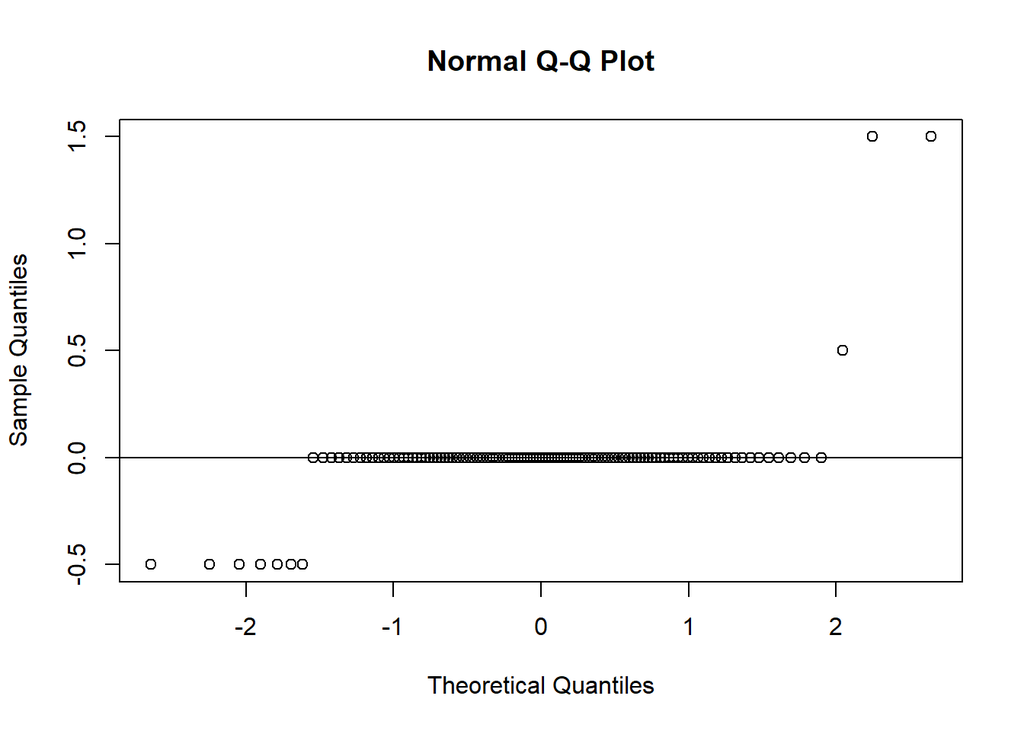

```r
#create Q-Q plot for residuals
qqnorm(res)

#add a straight diagonal line to the plot
qqline(res)
```

##### 2.3. Day 18

1. Run LMM for green colouration at day 18

```r
my_glmer1<- lmer(Green ~ Site*Treatment + (1|Location), data=Juveniles_stat18_1)
```

```
## boundary (singular) fit: see help('isSingular')
```

```r
summary(my_glmer1)
```

```
## Linear mixed model fit by REML ['lmerMod']
## Formula: Green ~ Site * Treatment + (1 | Location)
##    Data: Juveniles_stat18_1
##
## REML criterion at convergence: 193.8
##
## Scaled residuals:
##     Min      1Q  Median      3Q     Max
## -2.1968 -0.4660 -0.1898 -0.1424  2.9512
##
## Random effects:
##  Groups   Name        Variance Std.Dev.
##  Location (Intercept) 0.0000   0.0000
##  Residual             0.3425   0.5853
## Number of obs: 107, groups:  Location, 6
##
## Fixed effects:
##                               Estimate Std. Error t value
## (Intercept)                    0.22222    0.19509   1.139
## SiteBonny Hills               -0.11111    0.27590  -0.403
## SiteCronulla                  -0.12222    0.26891  -0.455
## SitePalm Beach                 0.05051    0.26306   0.192
## TreatmentMHW1                  0.07778    0.26891   0.289
## TreatmentMHW2                  0.27778    0.30846   0.901
## SiteBonny Hills:TreatmentMHW1 -0.04603    0.39913  -0.115
## SiteCronulla:TreatmentMHW1    -0.09444    0.36758  -0.257
## SitePalm Beach:TreatmentMHW1  -0.25960    0.36687  -0.708
## SiteBonny Hills:TreatmentMHW2  0.89683    0.42678   2.101
## SiteCronulla:TreatmentMHW2     0.24722    0.41500   0.596
## SitePalm Beach:TreatmentMHW2  -0.26479    0.41860  -0.633
##
## Correlation of Fixed Effects:
##             (Intr) StBnnH StCrnl StPlmB TrMHW1 TrMHW2 SBH:TMHW1 SC:TMHW1
## SitBnnyHlls -0.707
## SiteCronull -0.725  0.513
## SitePalmBch -0.742  0.524  0.538
## TretmntMHW1 -0.725  0.513  0.526  0.538
## TretmntMHW2 -0.632  0.447  0.459  0.469  0.459
## StBHl:TMHW1  0.489 -0.691 -0.355 -0.362 -0.674 -0.309
## StCrn:TMHW1  0.531 -0.375 -0.732 -0.394 -0.732 -0.336  0.493
## StPBc:TMHW1  0.532 -0.376 -0.386 -0.717 -0.733 -0.336  0.494     0.536
## StBHl:TMHW2  0.457 -0.646 -0.332 -0.339 -0.332 -0.723  0.447     0.243
## StCrn:TMHW2  0.470 -0.332 -0.648 -0.349 -0.341 -0.743  0.230     0.474
## StPBc:TMHW2  0.466 -0.330 -0.338 -0.628 -0.338 -0.737  0.228     0.247
##             SPB:TMHW1 SBH:TMHW2 SC:TMHW2
## SitBnnyHlls
## SiteCronull
## SitePalmBch
## TretmntMHW1
## TretmntMHW2
## StBHl:TMHW1
## StCrn:TMHW1
## StPBc:TMHW1
## StBHl:TMHW2  0.243
## StCrn:TMHW2  0.250     0.537
## StPBc:TMHW2  0.451     0.533     0.548
## optimizer (nloptwrap) convergence code: 0 (OK)
## boundary (singular) fit: see help('isSingular')
```

```r
overdisp.glmer(my_glmer1)
```

```
## Residual deviance: 32.541 on 94 degrees of freedom (ratio: 0.346)
```

```r
my_glmer_anova <- car::Anova(my_glmer1)
my_glmer_anova
```

```
## Analysis of Deviance Table (Type II Wald chisquare tests)
##
## Response: Green
##                  Chisq Df Pr(>Chisq)
## Site            2.6847  3   0.442830
## Treatment      15.3947  2   0.000454 ***
## Site:Treatment 10.1880  6   0.116955
## ---
## Signif. codes:  0 '***' 0.001 '**' 0.01 '*' 0.05 '.' 0.1 ' ' 1
```

2. Post-hoc test

```r
emm3 <- emmeans(my_glmer1, specs = pairwise ~ Treatment, type = "response", adjust = "tukey")
```

```
## NOTE: Results may be misleading due to involvement in interactions
```

```r
summary(emm3)
```

```
## $emmeans
##  Treatment emmean     SE   df lower.CL upper.CL
##  Ambient    0.177 0.0949 28.9  -0.0177    0.371
##  MHW1       0.154 0.0950 30.6  -0.0396    0.348
##  MHW2       0.674 0.1138 36.8   0.4435    0.905
##
## Results are averaged over the levels of: Site
## Degrees-of-freedom method: kenward-roger
## Confidence level used: 0.95
##
## $contrasts
##  contrast       estimate    SE   df t.ratio p.value
##  Ambient - MHW1   0.0222 0.134 92.2   0.166  0.9849
##  Ambient - MHW2  -0.4976 0.147 93.6  -3.391  0.0029
##  MHW1 - MHW2     -0.5198 0.147 94.1  -3.531  0.0018
##
## Results are averaged over the levels of: Site
## Degrees-of-freedom method: kenward-roger
## P value adjustment: tukey method for comparing a family of 3 estimates
```

3. Check model assumptions

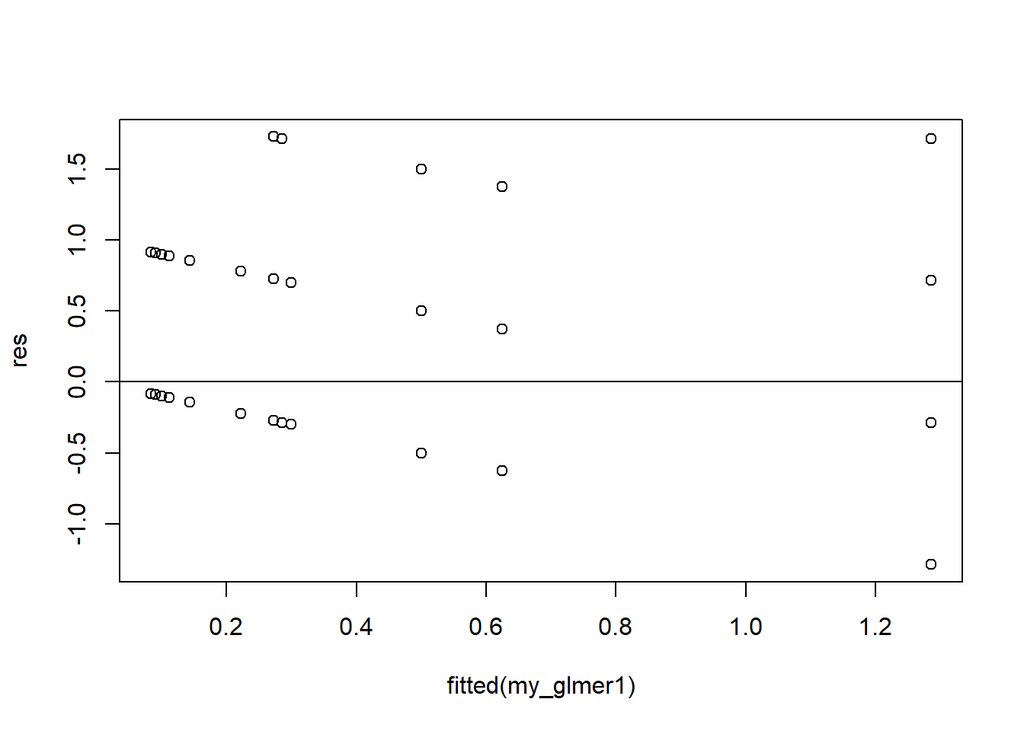

```r
res <- resid(my_glmer1)
#produce residual vs. fitted plot
plot(fitted(my_glmer1), res)

#add a horizontal line at 0
abline(0,0)
```

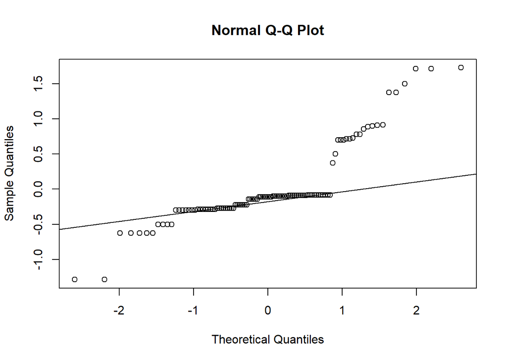

```r
#create Q-Q plot for residuals
qqnorm(res)

#add a straight diagonal line to the plot
qqline(res)
```

##### 2.4. Day 22

1. Run LMM for green colouration at day 22

```r
my_glmer1<- lmer(Green~ Site*Treatment + (1|Location), data=Juveniles_stat22_1)
```

```
## boundary (singular) fit: see help('isSingular')
```

```r
summary(my_glmer1)
```

```
## Linear mixed model fit by REML ['lmerMod']
## Formula: Green ~ Site * Treatment + (1 | Location)
##    Data: Juveniles_stat22_1
##
## REML criterion at convergence: 188.7
##
## Scaled residuals:
##     Min      1Q  Median      3Q     Max
## -1.0666 -0.5333 -0.2400  0.1333  3.1198
##
## Random effects:
##  Groups   Name        Variance Std.Dev.
##  Location (Intercept) 0.0000   0.0000
##  Residual             0.6945   0.8334
## Number of obs: 77, groups:  Location, 6
##
## Fixed effects:
##                               Estimate Std. Error t value
## (Intercept)                    0.44444    0.27780   1.600
## SiteBonny Hills                0.22222    0.39287   0.566
## SiteCronulla                  -0.04444    0.38292  -0.116
## SitePalm Beach                -0.17172    0.37458  -0.458
## TreatmentMHW1                  0.44444    0.39287   1.131
## SiteBonny Hills:TreatmentMHW1 -0.53968    0.57510  -0.938
## SiteCronulla:TreatmentMHW1    -0.76111    0.53073  -1.434
## SitePalm Beach:TreatmentMHW1  -0.51717    0.53567  -0.965
##
## Correlation of Fixed Effects:
##             (Intr) StBnnH StCrnl StPlmB TrMHW1 SBH:TM SC:TMH
## SitBnnyHlls -0.707
## SiteCronull -0.725  0.513
## SitePalmBch -0.742  0.524  0.538
## TretmntMHW1 -0.707  0.500  0.513  0.524
## StBHl:TMHW1  0.483 -0.683 -0.350 -0.358 -0.683
## StCrn:TMHW1  0.523 -0.370 -0.721 -0.388 -0.740  0.506
## StPBc:TMHW1  0.519 -0.367 -0.376 -0.699 -0.733  0.501  0.543
## optimizer (nloptwrap) convergence code: 0 (OK)
## boundary (singular) fit: see help('isSingular')
```

```r
overdisp.glmer(my_glmer1)
```

```
## Residual deviance: 47.924 on 68 degrees of freedom (ratio: 0.705)
```

```r
my_glmer_anova <- car::Anova(my_glmer1)
my_glmer_anova
```

```
## Analysis of Deviance Table (Type II Wald chisquare tests)
##
## Response: Green
##                 Chisq Df Pr(>Chisq)
## Site           4.6904  3     0.1959
## Treatment      0.0176  1     0.8945
## Site:Treatment 2.1411  3     0.5437
```

2. Check model assumptions

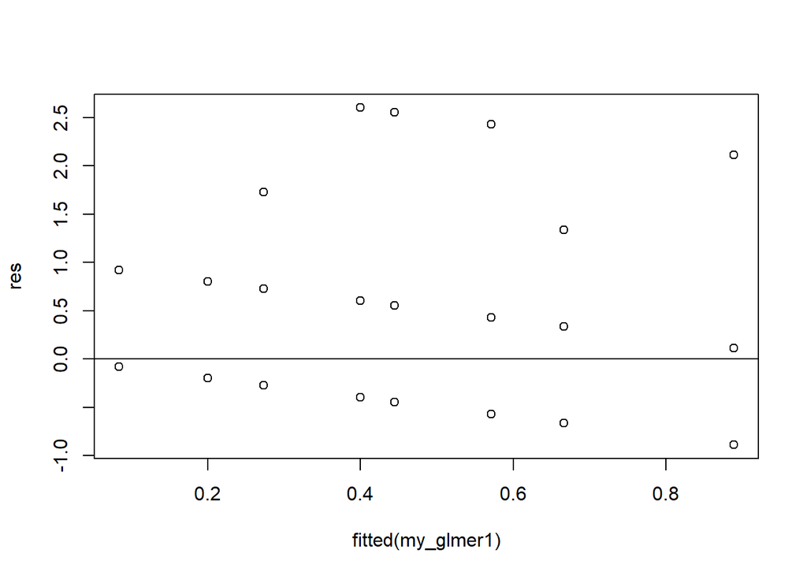

```r
res <- resid(my_glmer1)
#produce residual vs. fitted plot
plot(fitted(my_glmer1), res)

#add a horizontal line at 0
abline(0,0)
```

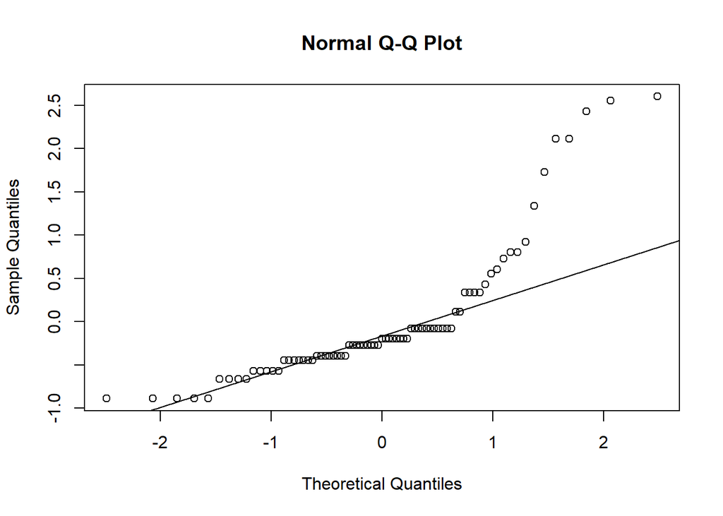

```r
#create Q-Q plot for residuals
qqnorm(res)

#add a straight diagonal line to the plot
qqline(res)
```

### **3f)** Necrosis

#### 1. Visualise differences

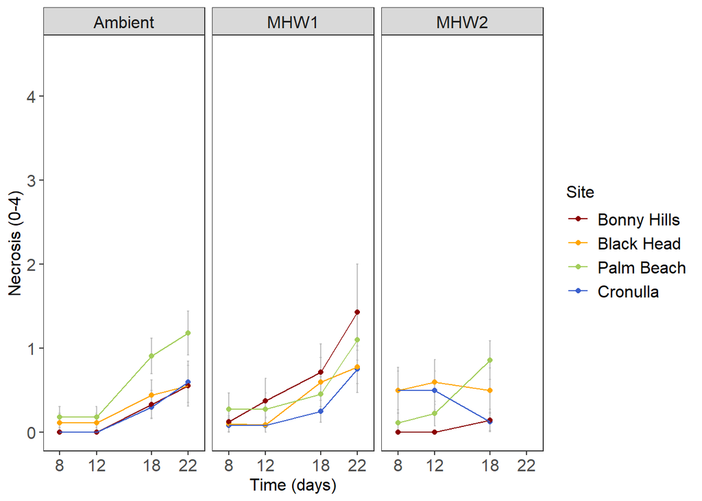

```r
Necrosis_plot <- Juv_means %>%
  filter(Day_equivalent == 8|Day_equivalent == 12|Day_equivalent == 18| Day_equivalent == 22)  %>%
ggplot(aes(x= Day_equivalent, y= Mean_necrosis, colour = Site)) +
   geom_errorbar(aes(ymin=Mean_necrosis-se_necrosis, ymax=Mean_necrosis+se_necrosis),colour = "grey", width=.2) +
  geom_point() +
  geom_line()+
Theme1 +
labs( y="Necrosis (0-4)", x="Time (days)")  +
 scale_colour_manual(values = c("darkred", "orange", "darkolivegreen3", "royalblue3"))   +
theme(strip.text.x = element_text(size = 12))+
scale_y_continuous(limits = c(0, 4.5), breaks = seq(0, 4, by = 1))+
scale_x_continuous(limits = c(7, 23), breaks = c(8, 12, 18,22))+
facet_wrap(~ factor(Treatment, c("Ambient","MHW1","MHW2")), ncol = 3)


Necrosis_plot
```

```r
ggsave("Necrosis_juv.jpeg", width = 220, height = 60, units = "mm")
```

#### 2. Statistical analyses

##### 2.1. Day 8

1. Run LMM for necrosis at day 8

```r
my_lmer<- lmer(Black ~ Site*Treatment + (1|Location), data=Juveniles_stat8_1)
summary(my_lmer)
```

```
## Linear mixed model fit by REML ['lmerMod']
## Formula: Black ~ Site * Treatment + (1 | Location)
##    Data: Juveniles_stat8_1
##
## REML criterion at convergence: 170.2
##
## Scaled residuals:
##     Min      1Q  Median      3Q     Max
## -1.2562 -0.3858 -0.1838  0.0310  3.6470
##
## Random effects:
##  Groups   Name        Variance Std.Dev.
##  Location (Intercept) 0.00869  0.09322
##  Residual             0.21083  0.45916
## Number of obs: 121, groups:  Location, 6
##
## Fixed effects:
##                                Estimate Std. Error t value
## (Intercept)                    0.102387   0.158384   0.646
## SiteBonny Hills               -0.095433   0.216736  -0.440
## SiteCronulla                  -0.102387   0.202993  -0.504
## SitePalm Beach                 0.084893   0.207102   0.410
## TreatmentMHW1                 -0.008753   0.211872  -0.041
## TreatmentMHW2                  0.414317   0.211615   1.958
## SiteBonny Hills:TreatmentMHW1  0.152393   0.307582   0.495
## SiteCronulla:TreatmentMHW1     0.092086   0.282892   0.326
## SitePalm Beach:TreatmentMHW1   0.086835   0.288972   0.300
## SiteBonny Hills:TreatmentMHW2 -0.395530   0.307182  -1.288
## SiteCronulla:TreatmentMHW2     0.085683   0.282700   0.303
## SitePalm Beach:TreatmentMHW2  -0.483532   0.295861  -1.634
##
## Correlation of Fixed Effects:
##             (Intr) StBnnH StCrnl StPlmB TrMHW1 TrMHW2 SBH:TMHW1 SC:TMHW1
## SitBnnyHlls -0.686
## SiteCronull -0.735  0.535
## SitePalmBch -0.721  0.526  0.563
## TretmntMHW1 -0.706  0.513  0.551  0.540
## TretmntMHW2 -0.704  0.513  0.549  0.538  0.526
## StBHl:TMHW1  0.483 -0.703 -0.377 -0.369 -0.687 -0.360
## StCrn:TMHW1  0.529 -0.384 -0.718 -0.405 -0.749 -0.394  0.514
## StPBc:TMHW1  0.520 -0.378 -0.406 -0.719 -0.735 -0.388  0.503     0.550
## StBHl:TMHW2  0.483 -0.705 -0.377 -0.370 -0.361 -0.686  0.496     0.270
## StCrn:TMHW2  0.527 -0.384 -0.717 -0.403 -0.394 -0.749  0.270     0.515
## StPBc:TMHW2  0.506 -0.368 -0.395 -0.700 -0.379 -0.716  0.259     0.284
##             SPB:TMHW1 SBH:TMHW2 SC:TMHW2
## SitBnnyHlls
## SiteCronull
## SitePalmBch
## TretmntMHW1
## TretmntMHW2
## StBHl:TMHW1
## StCrn:TMHW1
## StPBc:TMHW1
## StBHl:TMHW2  0.265
## StCrn:TMHW2  0.290     0.513
## StPBc:TMHW2  0.504     0.491     0.536
```

```r
my_glmer_anova <- car::Anova(my_lmer)
my_glmer_anova
```

```
## Analysis of Deviance Table (Type II Wald chisquare tests)
##
## Response: Black
##                 Chisq Df Pr(>Chisq)
## Site           2.1995  3    0.53205
## Treatment      5.7962  2    0.05513 .
## Site:Treatment 8.7888  6    0.18581
## ---
## Signif. codes:  0 '***' 0.001 '**' 0.01 '*' 0.05 '.' 0.1 ' ' 1
```

2. Check model assumptions

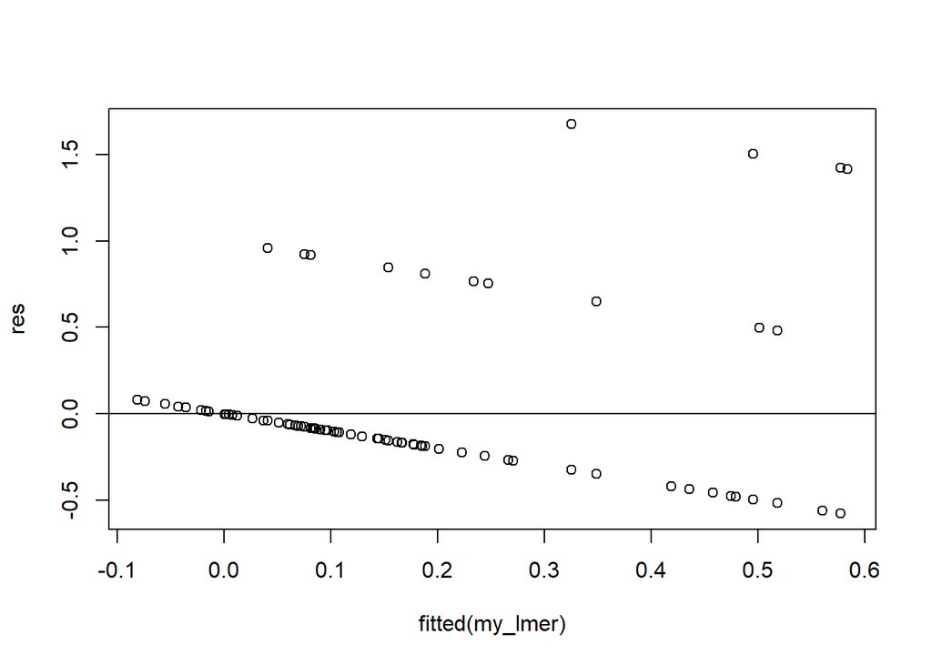

```r
res <- resid(my_lmer)
#produce residual vs. fitted plot
plot(fitted(my_lmer), res)

#add a horizontal line at 0
abline(0,0)
```

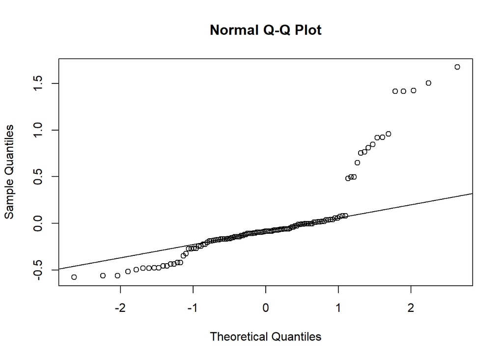

```r
#create Q-Q plot for residuals
qqnorm(res)

#add a straight diagonal line to the plot
qqline(res)
```

##### 2.2. Day 12

1. Run LMM for necrosis at day 12

```r
my_glmer<- lmer(Black ~ Site*Treatment + (1|Location), data=Juveniles_stat12_1)
summary(my_glmer)
```

```
## Linear mixed model fit by REML ['lmerMod']
## Formula: Black ~ Site * Treatment + (1 | Location)
##    Data: Juveniles_stat12_1
##
## REML criterion at convergence: 186.8
##
## Scaled residuals:
##     Min      1Q  Median      3Q     Max
## -1.2525 -0.4755 -0.1819  0.0069  3.4461
##
## Random effects:
##  Groups   Name        Variance Std.Dev.
##  Location (Intercept) 0.002206 0.04697
##  Residual             0.246803 0.49679
## Number of obs: 122, groups:  Location, 6
##
## Fixed effects:
##                                Estimate Std. Error t value
## (Intercept)                    0.108318   0.166949   0.649
## SiteBonny Hills               -0.106455   0.234291  -0.454
## SiteCronulla                  -0.108318   0.219251  -0.494
## SitePalm Beach                 0.075089   0.223548   0.336
## TreatmentMHW1                 -0.018640   0.223546  -0.083
## TreatmentMHW2                  0.496421   0.228487   2.173
## SiteBonny Hills:TreatmentMHW1  0.398622   0.328957   1.212
## SiteCronulla:TreatmentMHW1     0.101973   0.301839   0.338
## SitePalm Beach:TreatmentMHW1   0.105740   0.308146   0.343
## SiteBonny Hills:TreatmentMHW2 -0.491866   0.332273  -1.480
## SiteCronulla:TreatmentMHW2     0.003579   0.305516   0.012
## SitePalm Beach:TreatmentMHW2  -0.455743   0.319577  -1.426
##
## Correlation of Fixed Effects:
##             (Intr) StBnnH StCrnl StPlmB TrMHW1 TrMHW2 SBH:TMHW1 SC:TMHW1
## SitBnnyHlls -0.702
## SiteCronull -0.751  0.535
## SitePalmBch -0.737  0.525  0.561
## TretmntMHW1 -0.737  0.524  0.561  0.551
## TretmntMHW2 -0.720  0.513  0.549  0.538  0.538
## StBHl:TMHW1  0.500 -0.712 -0.381 -0.373 -0.679 -0.365
## StCrn:TMHW1  0.546 -0.388 -0.727 -0.408 -0.741 -0.399  0.503
## StPBc:TMHW1  0.536 -0.381 -0.408 -0.726 -0.726 -0.391  0.492     0.538
## StBHl:TMHW2  0.495 -0.705 -0.377 -0.370 -0.369 -0.687  0.502     0.274
## StCrn:TMHW2  0.539 -0.384 -0.717 -0.402 -0.402 -0.748  0.273     0.521
## StPBc:TMHW2  0.516 -0.367 -0.393 -0.699 -0.385 -0.715  0.261     0.285
##             SPB:TMHW1 SBH:TMHW2 SC:TMHW2
## SitBnnyHlls
## SiteCronull
## SitePalmBch
## TretmntMHW1
## TretmntMHW2
## StBHl:TMHW1
## StCrn:TMHW1
## StPBc:TMHW1
## StBHl:TMHW2  0.268
## StCrn:TMHW2  0.292     0.514
## StPBc:TMHW2  0.508     0.491     0.535
```

```r
my_glmer_anova <- car::Anova(my_glmer)
my_glmer_anova
```

```
## Analysis of Deviance Table (Type II Wald chisquare tests)
##
## Response: Black
##                  Chisq Df Pr(>Chisq)
## Site            1.1086  3    0.77499
## Treatment       6.7140  2    0.03484 *
## Site:Treatment 10.5056  6    0.10491
## ---
## Signif. codes:  0 '***' 0.001 '**' 0.01 '*' 0.05 '.' 0.1 ' ' 1
```

```r
overdisp.glmer(my_glmer)
```

```
## Residual deviance: 26.962 on 109 degrees of freedom (ratio: 0.247)
```

2. Post-hoc test

```r
emm3 <- emmeans(my_glmer, specs = pairwise ~ Treatment, type = "response", adjust = "tukey")
```

```
## NOTE: Results may be misleading due to involvement in interactions
```

```r
summary(emm3)
```

```
## $emmeans
##  Treatment emmean     SE   df lower.CL upper.CL
##  Ambient   0.0734 0.0810 30.2  -0.0919    0.239
##  MHW1      0.2063 0.0800 30.4   0.0429    0.370
##  MHW2      0.3338 0.0835 31.4   0.1636    0.504
##
## Results are averaged over the levels of: Site
## Degrees-of-freedom method: kenward-roger
## Confidence level used: 0.95
##
## $contrasts
##  contrast       estimate    SE  df t.ratio p.value
##  Ambient - MHW1   -0.133 0.110 106  -1.204  0.4535
##  Ambient - MHW2   -0.260 0.113 107  -2.312  0.0585
##  MHW1 - MHW2      -0.127 0.112 107  -1.135  0.4945
##
## Results are averaged over the levels of: Site
## Degrees-of-freedom method: kenward-roger
## P value adjustment: tukey method for comparing a family of 3 estimates
```

Check model assumptions

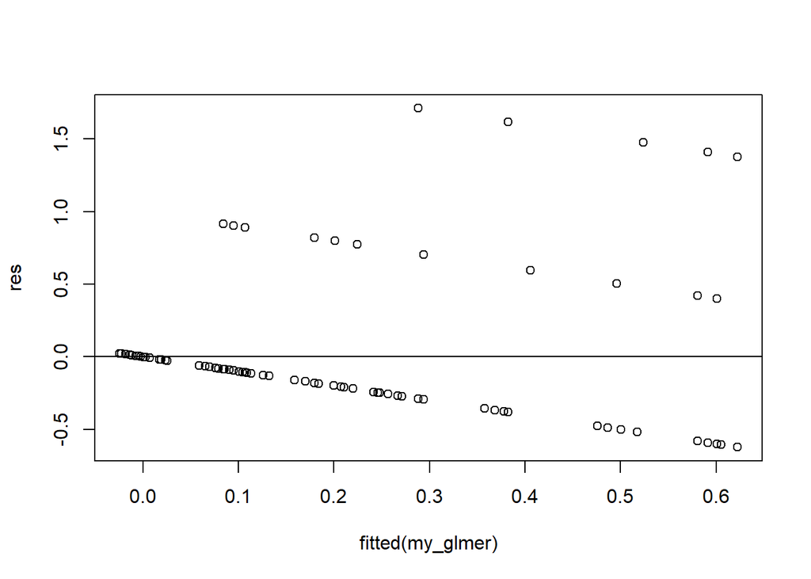

```r
res <- resid(my_glmer)
#produce residual vs. fitted plot
plot(fitted(my_glmer), res)

#add a horizontal line at 0
abline(0,0)
```

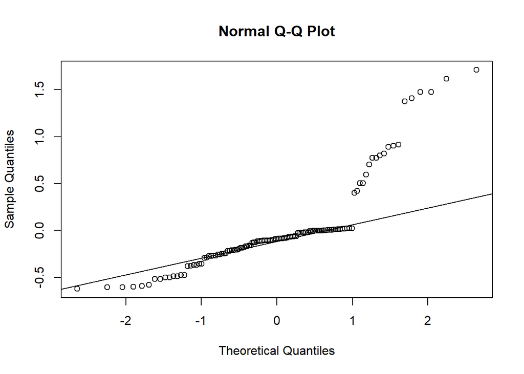

```r
#create Q-Q plot for residuals
qqnorm(res)

#add a straight diagonal line to the plot
qqline(res)
```

##### 2.3. Day 18

1. Run LMM for necrosis at day 18

```r
my_glmer1<- lmer(Black ~ Site*Treatment + (1|Location), data=Juveniles_stat18_1)
```

```
## boundary (singular) fit: see help('isSingular')
```

```r
summary(my_glmer1)
```

```
## Linear mixed model fit by REML ['lmerMod']
## Formula: Black ~ Site * Treatment + (1 | Location)
##    Data: Juveniles_stat18_1
##
## REML criterion at convergence: 213.7
##
## Scaled residuals:
##     Min      1Q  Median      3Q     Max
## -1.3988 -0.6839 -0.2198  0.6924  3.6928
##
## Random effects:
##  Groups   Name        Variance Std.Dev.
##  Location (Intercept) 0.0000   0.0000
##  Residual             0.4224   0.6499
## Number of obs: 107, groups:  Location, 6
##
## Fixed effects:
##                               Estimate Std. Error t value
## (Intercept)                    0.44444    0.21664   2.052
## SiteBonny Hills               -0.11111    0.30637  -0.363
## SiteCronulla                  -0.14444    0.29861  -0.484
## SitePalm Beach                 0.46465    0.29211   1.591
## TreatmentMHW1                  0.15556    0.29861   0.521
## TreatmentMHW2                  0.05556    0.34253   0.162
## SiteBonny Hills:TreatmentMHW1  0.22540    0.44322   0.509
## SiteCronulla:TreatmentMHW1    -0.20556    0.40818  -0.504
## SitePalm Beach:TreatmentMHW1  -0.61010    0.40739  -1.498
## SiteBonny Hills:TreatmentMHW2 -0.24603    0.47392  -0.519
## SiteCronulla:TreatmentMHW2    -0.23056    0.46083  -0.500
## SitePalm Beach:TreatmentMHW2  -0.10750    0.46483  -0.231
##
## Correlation of Fixed Effects:
##             (Intr) StBnnH StCrnl StPlmB TrMHW1 TrMHW2 SBH:TMHW1 SC:TMHW1
## SitBnnyHlls -0.707
## SiteCronull -0.725  0.513
## SitePalmBch -0.742  0.524  0.538
## TretmntMHW1 -0.725  0.513  0.526  0.538
## TretmntMHW2 -0.632  0.447  0.459  0.469  0.459
## StBHl:TMHW1  0.489 -0.691 -0.355 -0.362 -0.674 -0.309
## StCrn:TMHW1  0.531 -0.375 -0.732 -0.394 -0.732 -0.336  0.493
## StPBc:TMHW1  0.532 -0.376 -0.386 -0.717 -0.733 -0.336  0.494     0.536
## StBHl:TMHW2  0.457 -0.646 -0.332 -0.339 -0.332 -0.723  0.447     0.243
## StCrn:TMHW2  0.470 -0.332 -0.648 -0.349 -0.341 -0.743  0.230     0.474
## StPBc:TMHW2  0.466 -0.330 -0.338 -0.628 -0.338 -0.737  0.228     0.247
##             SPB:TMHW1 SBH:TMHW2 SC:TMHW2
## SitBnnyHlls
## SiteCronull
## SitePalmBch
## TretmntMHW1
## TretmntMHW2
## StBHl:TMHW1
## StCrn:TMHW1
## StPBc:TMHW1
## StBHl:TMHW2  0.243
## StCrn:TMHW2  0.250     0.537
## StPBc:TMHW2  0.451     0.533     0.548
## optimizer (nloptwrap) convergence code: 0 (OK)
## boundary (singular) fit: see help('isSingular')
```

```r
overdisp.glmer(my_glmer1)
```

```
## Residual deviance: 40.126 on 94 degrees of freedom (ratio: 0.427)
```

```r
my_glmer_anova <- car::Anova(my_glmer1)
my_glmer_anova
```

```
## Analysis of Deviance Table (Type II Wald chisquare tests)
##
## Response: Black
##                 Chisq Df Pr(>Chisq)
## Site           8.7464  3    0.03286 *
## Treatment      0.4148  2    0.81271
## Site:Treatment 6.0997  6    0.41212
## ---
## Signif. codes:  0 '***' 0.001 '**' 0.01 '*' 0.05 '.' 0.1 ' ' 1
```

2. Post-hoc test

```r
emm3 <- emmeans(my_glmer1, specs = pairwise ~ Site, type = "response", adjust = "tukey")
```

```
## NOTE: Results may be misleading due to involvement in interactions
```

```r
summary(emm3)
```

```
## $emmeans
##  Site        emmean    SE   df lower.CL upper.CL
##  Black Head   0.515 0.134 54.6    0.246    0.784
##  Bonny Hills  0.397 0.139 50.1    0.118    0.676
##  Cronulla     0.225 0.121 43.4   -0.019    0.469
##  Palm Beach   0.740 0.124 47.5    0.491    0.990
##
## Results are averaged over the levels of: Treatment
## Degrees-of-freedom method: kenward-roger
## Confidence level used: 0.95
##
## $contrasts
##  contrast                 estimate    SE   df t.ratio p.value
##  Black Head - Bonny Hills    0.118 0.191 92.1   0.616  0.9266
##  Black Head - Cronulla       0.290 0.180 91.2   1.611  0.3776
##  Black Head - Palm Beach    -0.225 0.182 91.0  -1.239  0.6038
##  Bonny Hills - Cronulla      0.172 0.183 93.1   0.938  0.7846
##  Bonny Hills - Palm Beach   -0.343 0.185 92.1  -1.859  0.2529
##  Cronulla - Palm Beach      -0.515 0.173 91.1  -2.984  0.0188
##
## Results are averaged over the levels of: Treatment
## Degrees-of-freedom method: kenward-roger
## P value adjustment: tukey method for comparing a family of 4 estimates
```

3. Check model assumptions

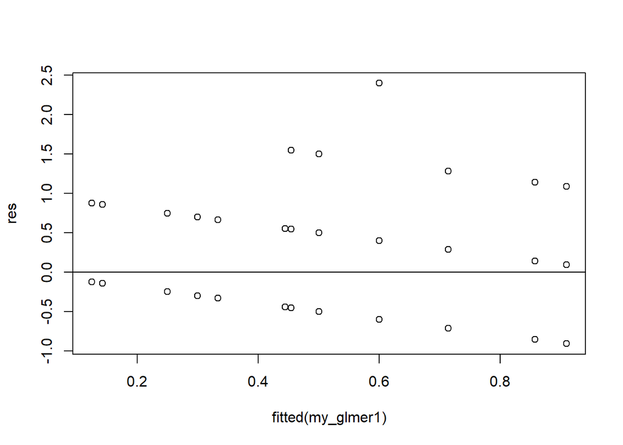

```r
res <- resid(my_glmer1)
#produce residual vs. fitted plot
plot(fitted(my_glmer1), res)

#add a horizontal line at 0
abline(0,0)
```

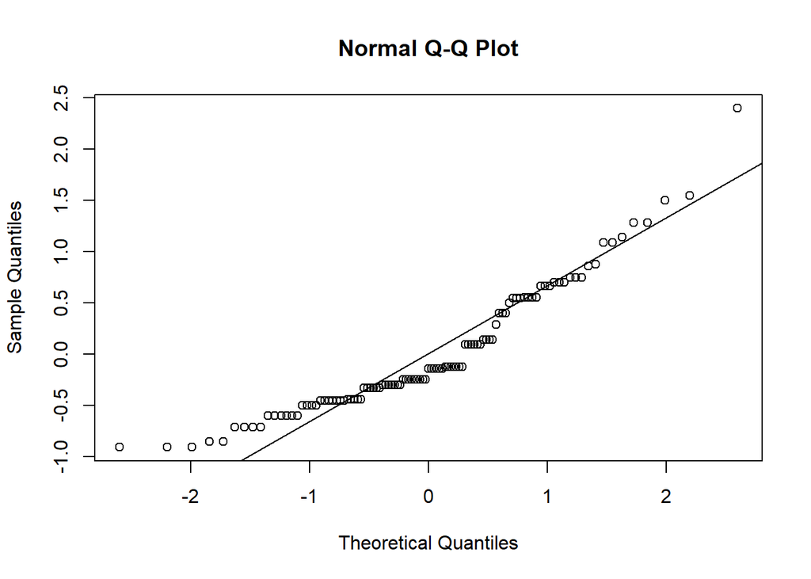

```r
#create Q-Q plot for residuals
qqnorm(res)

#add a straight diagonal line to the plot
qqline(res)
```

##### 2.4. Day 22

1. Run LMM for necrosis at day 22

```r
my_glmer1<- lmer(Black~ Site*Treatment + (1|Location), data=Juveniles_stat22_1)
```

```
## boundary (singular) fit: see help('isSingular')
```

```r
summary(my_glmer1)
```

```
## Linear mixed model fit by REML ['lmerMod']
## Formula: Black ~ Site * Treatment + (1 | Location)
##    Data: Juveniles_stat22_1
##
## REML criterion at convergence: 207.5
##
## Scaled residuals:
##     Min      1Q  Median      3Q     Max
## -1.4962 -0.6284 -0.1904  0.4655  2.6932
##
## Random effects:
##  Groups   Name        Variance  Std.Dev.
##  Location (Intercept) 8.337e-18 2.887e-09
##  Residual             9.116e-01 9.548e-01
## Number of obs: 77, groups:  Location, 6
##
## Fixed effects:
##                                 Estimate Std. Error t value
## (Intercept)                    5.556e-01  3.183e-01   1.746
## SiteBonny Hills               -1.091e-16  4.501e-01   0.000
## SiteCronulla                   4.444e-02  4.387e-01   0.101
## SitePalm Beach                 6.263e-01  4.291e-01   1.459
## TreatmentMHW1                  2.222e-01  4.501e-01   0.494
## SiteBonny Hills:TreatmentMHW1  6.508e-01  6.589e-01   0.988
## SiteCronulla:TreatmentMHW1    -7.222e-02  6.080e-01  -0.119
## SitePalm Beach:TreatmentMHW1  -3.040e-01  6.137e-01  -0.495
##
## Correlation of Fixed Effects:
##             (Intr) StBnnH StCrnl StPlmB TrMHW1 SBH:TM SC:TMH
## SitBnnyHlls -0.707
## SiteCronull -0.725  0.513
## SitePalmBch -0.742  0.524  0.538
## TretmntMHW1 -0.707  0.500  0.513  0.524
## StBHl:TMHW1  0.483 -0.683 -0.350 -0.358 -0.683
## StCrn:TMHW1  0.523 -0.370 -0.721 -0.388 -0.740  0.506
## StPBc:TMHW1  0.519 -0.367 -0.376 -0.699 -0.733  0.501  0.543
## optimizer (nloptwrap) convergence code: 0 (OK)
## boundary (singular) fit: see help('isSingular')
```

```r
overdisp.glmer(my_glmer1)
```

```
## Residual deviance: 62.901 on 68 degrees of freedom (ratio: 0.925)
```

```r
my_glmer_anova <- car::Anova(my_glmer1)
my_glmer_anova
```

```
## Analysis of Deviance Table (Type II Wald chisquare tests)
##
## Response: Black
##                 Chisq Df Pr(>Chisq)
## Site           3.6704  3     0.2993
## Treatment      1.3361  1     0.2477
## Site:Treatment 2.3727  3     0.4987
```

2. Check model assumptions

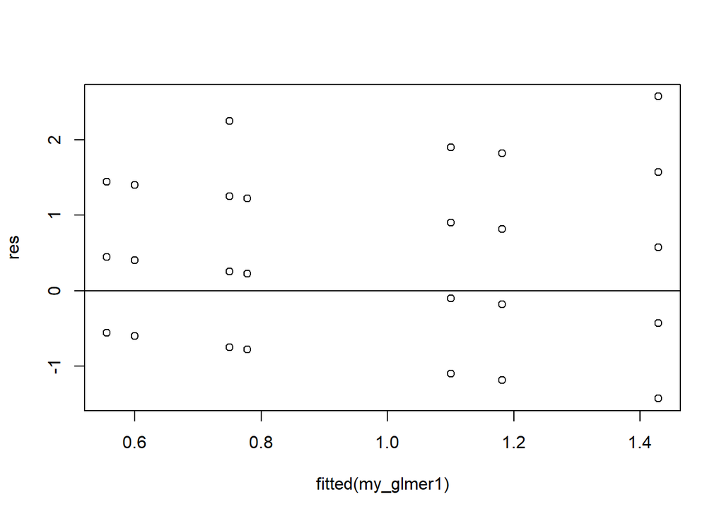

```r
res <- resid(my_glmer1)
#produce residual vs. fitted plot
plot(fitted(my_glmer1), res)

#add a horizontal line at 0
abline(0,0)
```

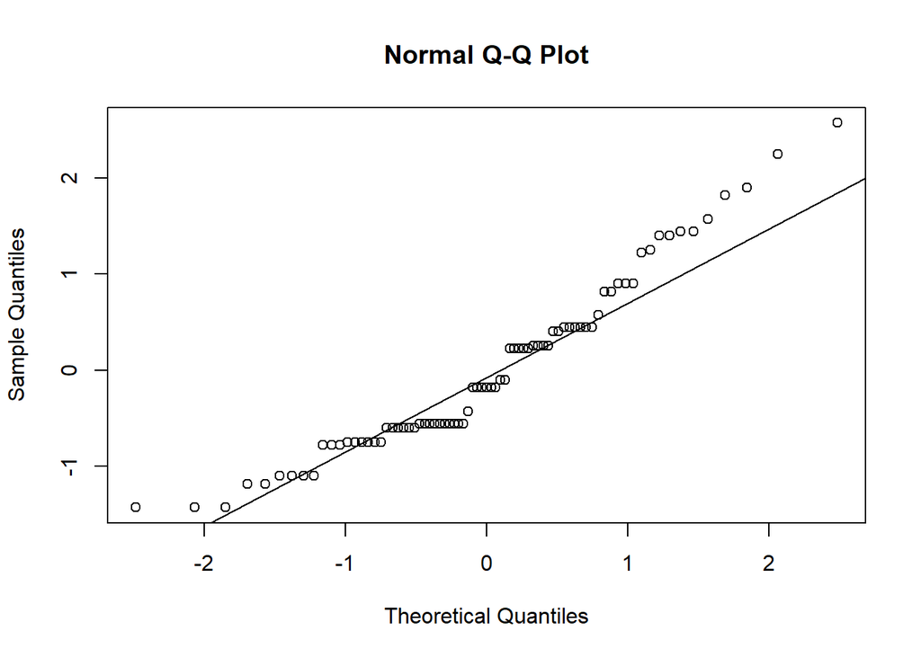

```r
#create Q-Q plot for residuals
qqnorm(res)

#add a straight diagonal line to the plot
qqline(res)
```

### **3g)** Photosynthetic efficiency

#### 1. Visualise differences

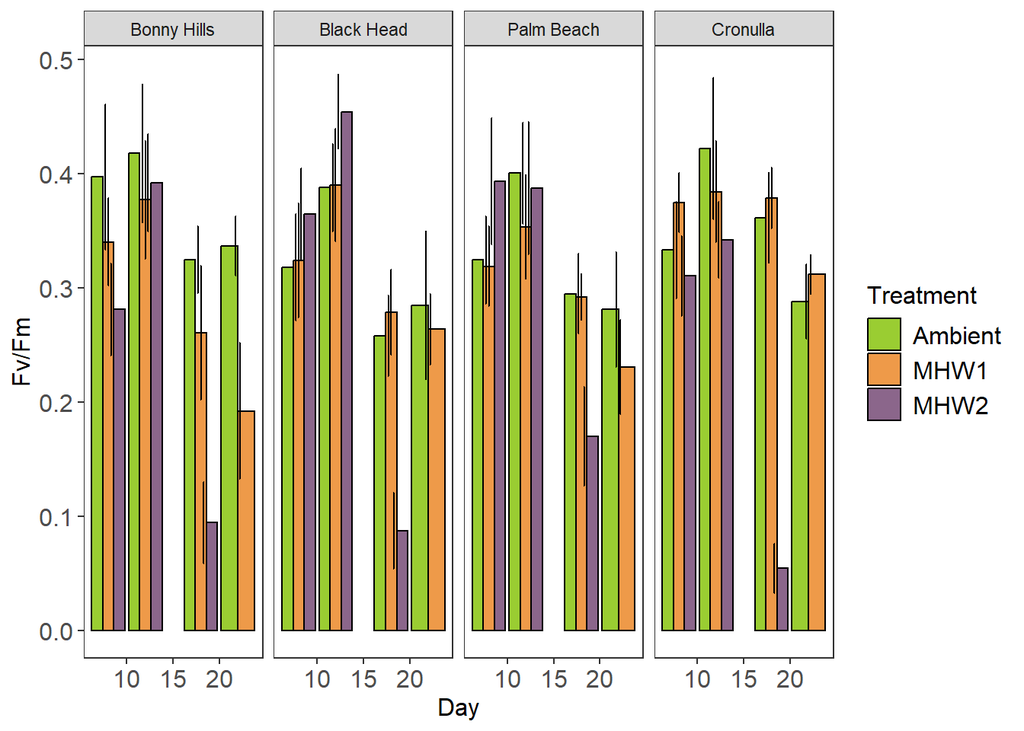

```r
FvFm_plot <- Photo_means %>%
ggplot(aes(x= Day_equivalent, y= Mean_FvFm, colour = Site)) +
   geom_errorbar(aes(ymin=Mean_FvFm-se_FvFm, ymax=Mean_FvFm+se_FvFm),colour = "grey", width=.2) +
  geom_point() +
  geom_line()+
Theme1 +
labs( y="Fv/Fm", x="Time (days)")  +
 scale_colour_manual(values = c("darkred", "orange", "darkolivegreen3", "royalblue3"))   +
theme(strip.text.x = element_text(size = 12))+
scale_x_continuous(limits = c(7, 23), breaks = c(8, 12, 18,22))+
facet_wrap(~ factor(Treatment, c("Ambient","MHW1","MHW2")), ncol = 3)


Photo_means$Day_equivalent <- as.numeric(Photo_means$Day_equivalent)
FvFm_plot <- Photo_means %>%
ggplot(aes(x= Day_equivalent, y=Mean_FvFm, fill = Treatment)) +
  geom_bar(stat="identity", color="black",
           position=position_dodge()) +
  geom_errorbar(aes(ymin=Mean_FvFm-se_FvFm, ymax=Mean_FvFm+se_FvFm), width=.2,
                 position=position_dodge(0.9))+
Theme1 +
labs( y="Fv/Fm", x="Day") +
facet_wrap(~ factor(Site, c("Bonny Hills","Black Head","Palm Beach","Cronulla")), ncol = 4)  +
 scale_fill_manual(breaks = c("Ambient", "MHW1", "MHW2"),
                        values=c("yellowgreen", "tan2", "plum4"))



FvFm_plot
```

```r
ggsave("photosynthesis_juv.jpeg", width = 220, height = 60, units = "mm")
```

#### 2. Statistical analyses

##### 2.1. Day 8

1. Run LMM for photosynthetic efficiency at day 8

```r
my_lmer<- lmer(Fv_Fm ~ Site*Treatment + (1|Location), data=Juveniles_stat8_1)
summary(my_lmer)
```

```
## Linear mixed model fit by REML ['lmerMod']
## Formula: Fv_Fm ~ Site * Treatment + (1 | Location)
##    Data: Juveniles_stat8_1
##
## REML criterion at convergence: -97
##
## Scaled residuals:
##     Min      1Q  Median      3Q     Max
## -1.9255 -0.6606 -0.1445  0.5488  2.9051
##
## Random effects:
##  Groups   Name        Variance  Std.Dev.
##  Location (Intercept) 0.0008462 0.02909
##  Residual             0.0177656 0.13329
## Number of obs: 119, groups:  Location, 6
##
## Fixed effects:
##                                 Estimate Std. Error t value
## (Intercept)                    0.3223903  0.0488391   6.601
## SiteBonny Hills                0.0724598  0.0649163   1.116
## SiteCronulla                   0.0105264  0.0610303   0.172
## SitePalm Beach                 0.0002837  0.0622072   0.005
## TreatmentMHW1                  0.0032988  0.0634863   0.052
## TreatmentMHW2                  0.0414982  0.0634764   0.654
## SiteBonny Hills:TreatmentMHW1 -0.0626829  0.0906227  -0.692
## SiteCronulla:TreatmentMHW1     0.0384512  0.0836149   0.460
## SitePalm Beach:TreatmentMHW1  -0.0071139  0.0865142  -0.082
## SiteBonny Hills:TreatmentMHW2 -0.1602109  0.0905539  -1.769
## SiteCronulla:TreatmentMHW2    -0.0642482  0.0836073  -0.768
## SitePalm Beach:TreatmentMHW2   0.0267890  0.0873586   0.307
##
## Correlation of Fixed Effects:
##             (Intr) StBnnH StCrnl StPlmB TrMHW1 TrMHW2 SBH:TMHW1 SC:TMHW1
## SitBnnyHlls -0.706
## SiteCronull -0.753  0.565
## SitePalmBch -0.740  0.556  0.592
## TretmntMHW1 -0.724  0.542  0.580  0.569
## TretmntMHW2 -0.723  0.543  0.578  0.568  0.556
## StBHl:TMHW1  0.503 -0.713 -0.403 -0.395 -0.698 -0.386
## StCrn:TMHW1  0.550 -0.412 -0.730 -0.432 -0.759 -0.422  0.530
## StPBc:TMHW1  0.536 -0.401 -0.429 -0.722 -0.738 -0.412  0.512     0.560
## StBHl:TMHW2  0.504 -0.715 -0.403 -0.396 -0.387 -0.697  0.510     0.294
## StCrn:TMHW2  0.549 -0.413 -0.729 -0.431 -0.422 -0.759  0.293     0.532
## StPBc:TMHW2  0.527 -0.396 -0.422 -0.712 -0.406 -0.727  0.282     0.308
##             SPB:TMHW1 SBH:TMHW2 SC:TMHW2
## SitBnnyHlls
## SiteCronull
## SitePalmBch
## TretmntMHW1
## TretmntMHW2
## StBHl:TMHW1
## StCrn:TMHW1
## StPBc:TMHW1
## StBHl:TMHW2  0.285
## StCrn:TMHW2  0.312     0.529
## StPBc:TMHW2  0.515     0.507     0.552
```

```r
my_glmer_anova <- car::Anova(my_lmer)
my_glmer_anova
```

```
## Analysis of Deviance Table (Type II Wald chisquare tests)
##
## Response: Fv_Fm
##                 Chisq Df Pr(>Chisq)
## Site           0.0136  3     0.9996
## Treatment      0.0481  2     0.9762
## Site:Treatment 7.0699  6     0.3144
```

2. Check model assumptions

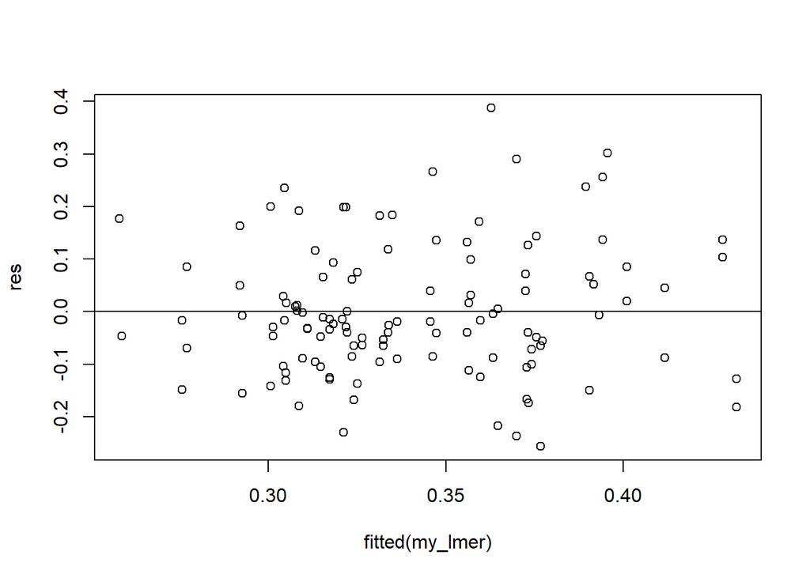

```r
res <- resid(my_lmer)
#produce residual vs. fitted plot
plot(fitted(my_lmer), res)

#add a horizontal line at 0
abline(0,0)
```

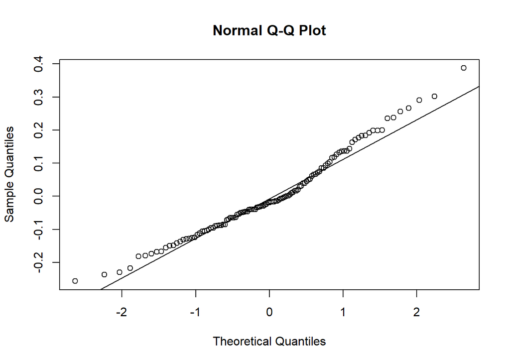

```r
#create Q-Q plot for residuals
qqnorm(res)

#add a straight diagonal line to the plot
qqline(res)
```

##### 2.2. Day 12

1. Run LMM for photosynthetic efficiency at day 12

```r
my_glmer<- lmer(Fv_Fm ~ Site*Treatment + (1|Location), data=Juveniles_stat12_1)
summary(my_glmer)
```

```
## Linear mixed model fit by REML ['lmerMod']
## Formula: Fv_Fm ~ Site * Treatment + (1 | Location)
##    Data: Juveniles_stat12_1
##
## REML criterion at convergence: -105.7
##
## Scaled residuals:
##      Min       1Q   Median       3Q      Max
## -1.88331 -0.67063 -0.08341  0.67070  3.09137
##
## Random effects:
##  Groups   Name        Variance Std.Dev.
##  Location (Intercept) 0.009179 0.09581
##  Residual             0.015165 0.12315
## Number of obs: 120, groups:  Location, 6
##
## Fixed effects:
##                                Estimate Std. Error t value
## (Intercept)                    0.395555   0.056995   6.940
## SiteBonny Hills                0.029451   0.058227   0.506
## SiteCronulla                   0.026195   0.054610   0.480
## SitePalm Beach                 0.011625   0.055787   0.208
## TreatmentMHW1                 -0.007157   0.055760  -0.128
## TreatmentMHW2                  0.046812   0.058582   0.799
## SiteBonny Hills:TreatmentMHW1 -0.024015   0.081695  -0.294
## SiteCronulla:TreatmentMHW1    -0.030677   0.075078  -0.409
## SitePalm Beach:TreatmentMHW1  -0.030540   0.078139  -0.391
## SiteBonny Hills:TreatmentMHW2 -0.094983   0.083525  -1.137
## SiteCronulla:TreatmentMHW2    -0.126645   0.077197  -1.641
## SitePalm Beach:TreatmentMHW2  -0.059208   0.080761  -0.733
##
## Correlation of Fixed Effects:
##             (Intr) StBnnH StCrnl StPlmB TrMHW1 TrMHW2 SBH:TMHW1 SC:TMHW1
## SitBnnyHlls -0.514
## SiteCronull -0.552  0.536
## SitePalmBch -0.542  0.528  0.566
## TretmntMHW1 -0.542  0.525  0.566  0.555
## TretmntMHW2 -0.514  0.503  0.536  0.527  0.525
## StBHl:TMHW1  0.364 -0.708 -0.380 -0.371 -0.677 -0.351
## StCrn:TMHW1  0.402 -0.390 -0.728 -0.412 -0.743 -0.390  0.503
## StPBc:TMHW1  0.394 -0.381 -0.411 -0.721 -0.721 -0.384  0.483     0.535
## StBHl:TMHW2  0.357 -0.697 -0.373 -0.367 -0.364 -0.694  0.492     0.270
## StCrn:TMHW2  0.390 -0.382 -0.707 -0.400 -0.398 -0.759  0.266     0.514
## StPBc:TMHW2  0.376 -0.367 -0.393 -0.693 -0.385 -0.727  0.256     0.286
##             SPB:TMHW1 SBH:TMHW2 SC:TMHW2
## SitBnnyHlls
## SiteCronull
## SitePalmBch
## TretmntMHW1
## TretmntMHW2
## StBHl:TMHW1
## StCrn:TMHW1
## StPBc:TMHW1
## StBHl:TMHW2  0.263
## StCrn:TMHW2  0.292     0.527
## StPBc:TMHW2  0.503     0.504     0.552
```

```r
my_glmer_anova <- car::Anova(my_glmer)
my_glmer_anova
```

```
## Analysis of Deviance Table (Type II Wald chisquare tests)
##
## Response: Fv_Fm
##                 Chisq Df Pr(>Chisq)
## Site           0.7408  3     0.8636
## Treatment      1.4825  2     0.4765
## Site:Treatment 3.2675  6     0.7746
```

```r
overdisp.glmer(my_glmer)
```

```
## Residual deviance: 1.568 on 107 degrees of freedom (ratio: 0.015)
```

2. Check model assumptions

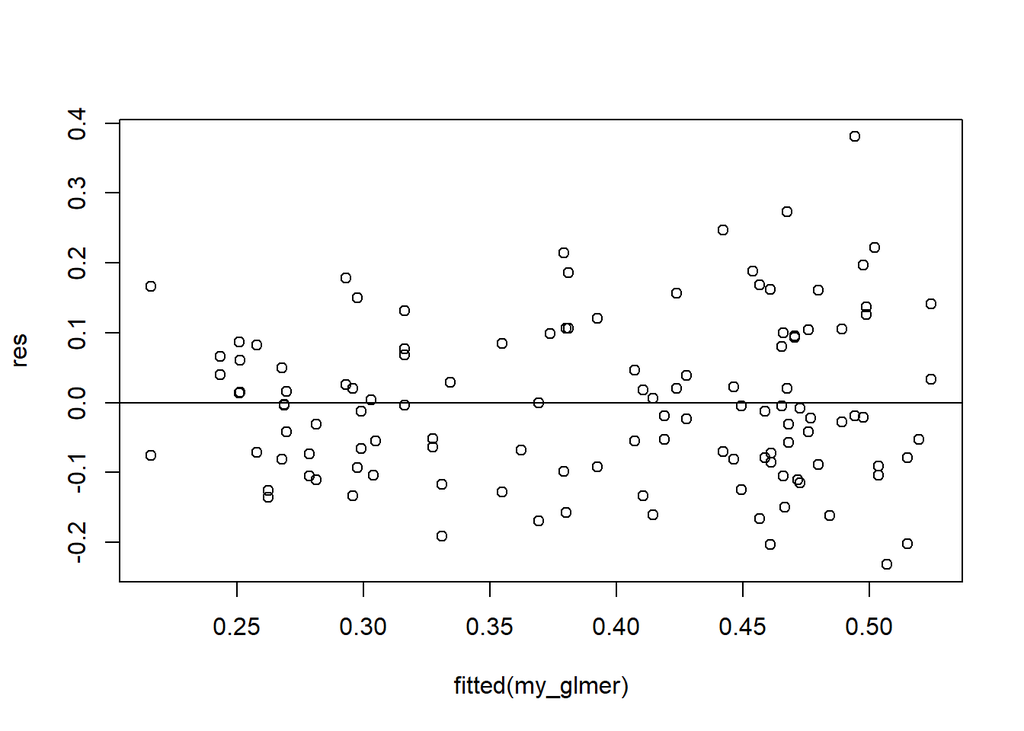

```r
res <- resid(my_glmer)
#produce residual vs. fitted plot
plot(fitted(my_glmer), res)

#add a horizontal line at 0
abline(0,0)
```

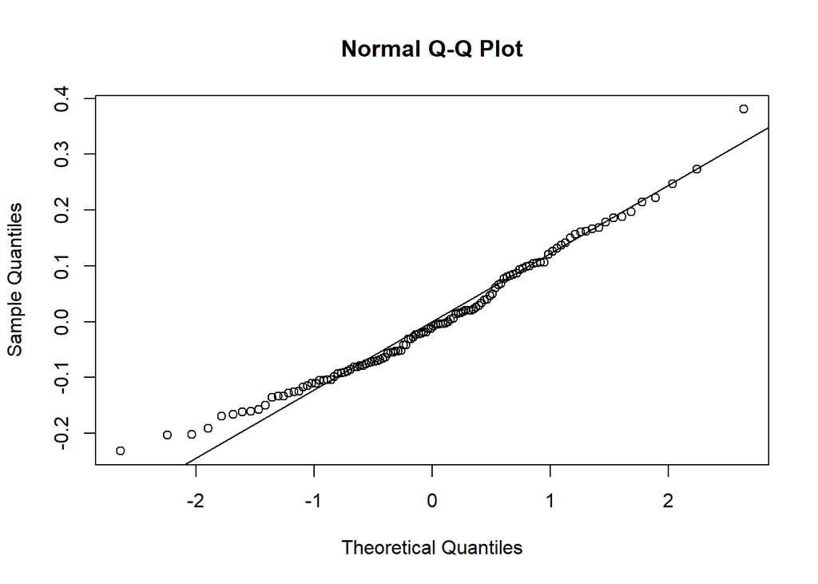

```r
#create Q-Q plot for residuals
qqnorm(res)

#add a straight diagonal line to the plot
qqline(res)
```

##### 2.3. Day 18

1. Run LMM for photosynthetic efficiency at day 18

```r
my_glmer1<- lmer(Fv_Fm ~ Site*Treatment + (1|Location), data=Juveniles_stat18_1)
```

```
## boundary (singular) fit: see help('isSingular')
```

```r
summary(my_glmer1)
```

```
## Linear mixed model fit by REML ['lmerMod']
## Formula: Fv_Fm ~ Site * Treatment + (1 | Location)
##    Data: Juveniles_stat18_1
##
## REML criterion at convergence: -134.7
##
## Scaled residuals:
##      Min       1Q   Median       3Q      Max
## -2.67047 -0.66720  0.01309  0.51564  2.71723
##
## Random effects:
##  Groups   Name        Variance Std.Dev.
##  Location (Intercept) 0.00000  0.0000
##  Residual             0.01218  0.1104
## Number of obs: 115, groups:  Location, 6
##
## Fixed effects:
##                                Estimate Std. Error t value
## (Intercept)                    0.257750   0.039020   6.606
## SiteBonny Hills                0.066806   0.053628   1.246
## SiteCronulla                   0.103361   0.053628   1.927
## SitePalm Beach                 0.036977   0.051282   0.721
## TreatmentMHW1                  0.020705   0.051282   0.404
## TreatmentMHW2                 -0.170639   0.053628  -3.182
## SiteBonny Hills:TreatmentMHW1 -0.084760   0.074201  -1.142
## SiteCronulla:TreatmentMHW1    -0.003399   0.070699  -0.048
## SitePalm Beach:TreatmentMHW1  -0.023795   0.069603  -0.342
## SiteBonny Hills:TreatmentMHW2 -0.059631   0.077262  -0.772
## SiteCronulla:TreatmentMHW2    -0.136199   0.073053  -1.864
## SitePalm Beach:TreatmentMHW2   0.045578   0.073053   0.624
##
## Correlation of Fixed Effects:
##             (Intr) StBnnH StCrnl StPlmB TrMHW1 TrMHW2 SBH:TMHW1 SC:TMHW1
## SitBnnyHlls -0.728
## SiteCronull -0.728  0.529
## SitePalmBch -0.761  0.554  0.554
## TretmntMHW1 -0.761  0.554  0.554  0.579
## TretmntMHW2 -0.728  0.529  0.529  0.554  0.554
## StBHl:TMHW1  0.526 -0.723 -0.383 -0.400 -0.691 -0.383
## StCrn:TMHW1  0.552 -0.402 -0.759 -0.420 -0.725 -0.402  0.501
## StPBc:TMHW1  0.561 -0.408 -0.408 -0.737 -0.737 -0.408  0.509     0.534
## StBHl:TMHW2  0.505 -0.694 -0.367 -0.384 -0.384 -0.694  0.502     0.279
## StCrn:TMHW2  0.534 -0.389 -0.734 -0.406 -0.406 -0.734  0.281     0.557
## StPBc:TMHW2  0.534 -0.389 -0.389 -0.702 -0.406 -0.734  0.281     0.295
##             SPB:TMHW1 SBH:TMHW2 SC:TMHW2
## SitBnnyHlls
## SiteCronull
## SitePalmBch
## TretmntMHW1
## TretmntMHW2
## StBHl:TMHW1
## StCrn:TMHW1
## StPBc:TMHW1
## StBHl:TMHW2  0.283
## StCrn:TMHW2  0.299     0.510
## StPBc:TMHW2  0.517     0.510     0.539
## optimizer (nloptwrap) convergence code: 0 (OK)
## boundary (singular) fit: see help('isSingular')
```

```r
overdisp.glmer(my_glmer1)
```

```
## Residual deviance: 1.255 on 102 degrees of freedom (ratio: 0.012)
```

```r
my_glmer_anova <- car::Anova(my_glmer1)
my_glmer_anova
```

```
## Analysis of Deviance Table (Type II Wald chisquare tests)
##
## Response: Fv_Fm
##                  Chisq Df Pr(>Chisq)
## Site            4.3046  3    0.23040
## Treatment      89.4045  2    < 2e-16 ***
## Site:Treatment 12.7934  6    0.04644 *
## ---
## Signif. codes:  0 '***' 0.001 '**' 0.01 '*' 0.05 '.' 0.1 ' ' 1
```

2. Post-hoc test

```r
emm3 <- emmeans(my_glmer1, specs = pairwise ~ Treatment|Site, type = "response", adjust = "tukey")
summary(emm3)
```

```
## $emmeans
## Site = Black Head:
##  Treatment emmean     SE    df lower.CL upper.CL
##  Ambient   0.2577 0.0394  98.8   0.1796    0.336
##  MHW1      0.2785 0.0333  97.2   0.2123    0.345
##  MHW2      0.0871 0.0370  97.4   0.0136    0.161
##
## Site = Bonny Hills:
##  Treatment emmean     SE    df lower.CL upper.CL
##  Ambient   0.3246 0.0369  99.5   0.2513    0.398
##  MHW1      0.2605 0.0393  98.8   0.1824    0.339
##  MHW2      0.0943 0.0420 100.3   0.0109    0.178
##
## Site = Cronulla:
##  Treatment emmean     SE    df lower.CL upper.CL
##  Ambient   0.3611 0.0370  97.4   0.2876    0.435
##  MHW1      0.3784 0.0319  96.1   0.3152    0.442
##  MHW2      0.0543 0.0333  97.2  -0.0118    0.120
##
## Site = Palm Beach:
##  Treatment emmean     SE    df lower.CL upper.CL
##  Ambient   0.2947 0.0333  97.2   0.2286    0.361
##  MHW1      0.2916 0.0333  97.2   0.2255    0.358
##  MHW2      0.1697 0.0369  99.5   0.0964    0.243
##
## Degrees-of-freedom method: kenward-roger
## Confidence level used: 0.95
##
## $contrasts
## Site = Black Head:
##  contrast       estimate     SE    df t.ratio p.value
##  Ambient - MHW1 -0.02070 0.0517 101.1  -0.401  0.9153
##  Ambient - MHW2  0.17064 0.0539 100.7   3.165  0.0058
##  MHW1 - MHW2     0.19134 0.0499 100.8   3.837  0.0006
##
## Site = Bonny Hills:
##  contrast       estimate     SE    df t.ratio p.value
##  Ambient - MHW1  0.06406 0.0538  99.9   1.190  0.4619
##  Ambient - MHW2  0.23027 0.0557  99.3   4.131  0.0002
##  MHW1 - MHW2     0.16621 0.0575 101.0   2.891  0.0130
##
## Site = Cronulla:
##  contrast       estimate     SE    df t.ratio p.value
##  Ambient - MHW1 -0.01731 0.0488 100.2  -0.354  0.9332
##  Ambient - MHW2  0.30684 0.0497  99.2   6.175  <.0001
##  MHW1 - MHW2     0.32414 0.0461  98.6   7.032  <.0001
##
## Site = Palm Beach:
##  contrast       estimate     SE    df t.ratio p.value
##  Ambient - MHW1  0.00309 0.0471  99.1   0.066  0.9976
##  Ambient - MHW2  0.12506 0.0497  99.0   2.517  0.0355
##  MHW1 - MHW2     0.12197 0.0497  99.0   2.455  0.0415
##
## Degrees-of-freedom method: kenward-roger
## P value adjustment: tukey method for comparing a family of 3 estimates
```

```r
emm3 <- emmeans(my_glmer1, specs = pairwise ~ Site|Treatment, type = "response", adjust = "tukey")
summary(emm3)
```

```
## $emmeans
## Treatment = Ambient:
##  Site        emmean     SE    df lower.CL upper.CL
##  Black Head  0.2577 0.0394  98.8   0.1796    0.336
##  Bonny Hills 0.3246 0.0369  99.5   0.2513    0.398
##  Cronulla    0.3611 0.0370  97.4   0.2876    0.435
##  Palm Beach  0.2947 0.0333  97.2   0.2286    0.361
##
## Treatment = MHW1:
##  Site        emmean     SE    df lower.CL upper.CL
##  Black Head  0.2785 0.0333  97.2   0.2123    0.345
##  Bonny Hills 0.2605 0.0393  98.8   0.1824    0.339
##  Cronulla    0.3784 0.0319  96.1   0.3152    0.442
##  Palm Beach  0.2916 0.0333  97.2   0.2255    0.358
##
## Treatment = MHW2:
##  Site        emmean     SE    df lower.CL upper.CL
##  Black Head  0.0871 0.0370  97.4   0.0136    0.161
##  Bonny Hills 0.0943 0.0420 100.3   0.0109    0.178
##  Cronulla    0.0543 0.0333  97.2  -0.0118    0.120
##  Palm Beach  0.1697 0.0369  99.5   0.0964    0.243
##
## Degrees-of-freedom method: kenward-roger
## Confidence level used: 0.95
##
## $contrasts
## Treatment = Ambient:
##  contrast                 estimate     SE    df t.ratio p.value
##  Black Head - Bonny Hills -0.06681 0.0537  98.8  -1.244  0.6005
##  Black Head - Cronulla    -0.10336 0.0538  99.8  -1.922  0.2256
##  Black Head - Palm Beach  -0.03698 0.0515 100.3  -0.718  0.8899
##  Bonny Hills - Cronulla   -0.03656 0.0521  99.3  -0.701  0.8963
##  Bonny Hills - Palm Beach  0.02983 0.0497  99.0   0.600  0.9317
##  Cronulla - Palm Beach     0.06638 0.0498 100.8   1.332  0.5450
##
## Treatment = MHW1:
##  contrast                 estimate     SE    df t.ratio p.value
##  Black Head - Bonny Hills  0.01795 0.0516 101.1   0.348  0.9855
##  Black Head - Cronulla    -0.09996 0.0461  98.6  -2.168  0.1395
##  Black Head - Palm Beach  -0.01318 0.0472  99.1  -0.280  0.9923
##  Bonny Hills - Cronulla   -0.11792 0.0506 100.4  -2.329  0.0983
##  Bonny Hills - Palm Beach -0.03114 0.0516 101.1  -0.603  0.9308
##  Cronulla - Palm Beach     0.08678 0.0461  98.6   1.882  0.2423
##
## Treatment = MHW2:
##  contrast                 estimate     SE    df t.ratio p.value
##  Black Head - Bonny Hills -0.00717 0.0557  99.0  -0.129  0.9992
##  Black Head - Cronulla     0.03284 0.0497  99.2   0.661  0.9115
##  Black Head - Palm Beach  -0.08256 0.0521  99.3  -1.584  0.3925
##  Bonny Hills - Cronulla    0.04001 0.0535  99.6   0.747  0.8776
##  Bonny Hills - Palm Beach -0.07538 0.0557  99.3  -1.352  0.5322
##  Cronulla - Palm Beach    -0.11539 0.0497  99.0  -2.323  0.0998
##
## Degrees-of-freedom method: kenward-roger
## P value adjustment: tukey method for comparing a family of 4 estimates
```

3. Check model assumptions

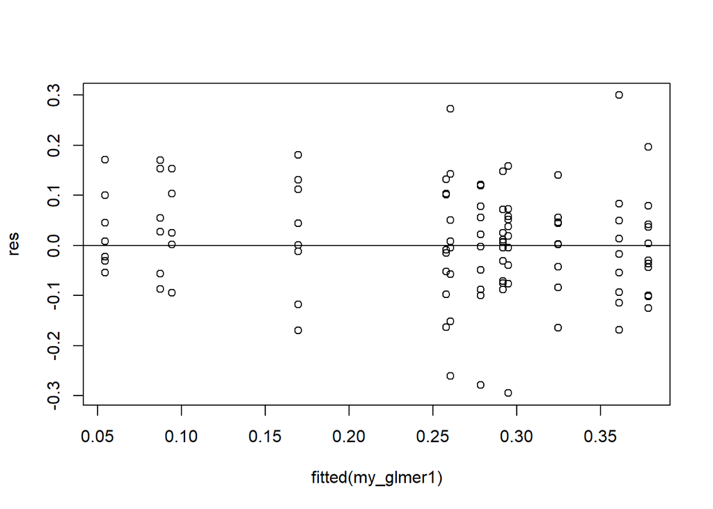

```r
res <- resid(my_glmer1)
#produce residual vs. fitted plot
plot(fitted(my_glmer1), res)

#add a horizontal line at 0
abline(0,0)
```

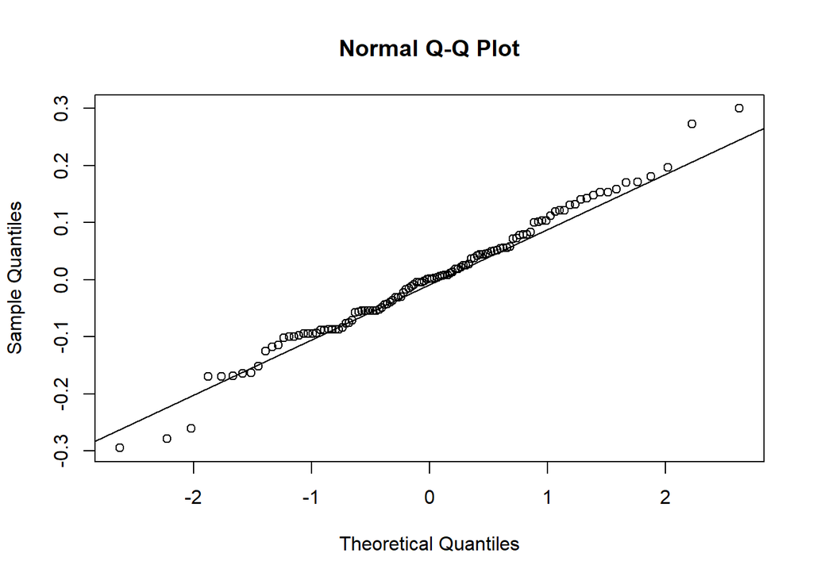

```r
#create Q-Q plot for residuals
qqnorm(res)

#add a straight diagonal line to the plot
qqline(res)
```

##### 2.4. Day 22

1. Run LMM for photosynthetic efficiency at day 22

```r
my_glmer1<- lmer(Fv_Fm~ Site*Treatment + (1|Location), data=Juveniles_stat22_1)
summary(my_glmer1)
```

```
## Linear mixed model fit by REML ['lmerMod']
## Formula: Fv_Fm ~ Site * Treatment + (1 | Location)
##    Data: Juveniles_stat22_1
##
## REML criterion at convergence: -70.8
##
## Scaled residuals:
##      Min       1Q   Median       3Q      Max
## -2.40305 -0.23558  0.07468  0.42078  2.50086
##
## Random effects:
##  Groups   Name        Variance Std.Dev.
##  Location (Intercept) 0.001963 0.04431
##  Residual             0.015619 0.12497
## Number of obs: 79, groups:  Location, 6
##
## Fixed effects:
##                                 Estimate Std. Error t value
## (Intercept)                    0.2826151  0.0458021   6.170
## SiteBonny Hills                0.0503286  0.0590873   0.852
## SiteCronulla                   0.0009258  0.0575091   0.016
## SitePalm Beach                -0.0012438  0.0566122  -0.022
## TreatmentMHW1                 -0.0139916  0.0581092  -0.241
## SiteBonny Hills:TreatmentMHW1 -0.1313075  0.0839806  -1.564
## SiteCronulla:TreatmentMHW1     0.0420341  0.0787639   0.534
## SitePalm Beach:TreatmentMHW1  -0.0316052  0.0798874  -0.396
##
## Correlation of Fixed Effects:
##             (Intr) StBnnH StCrnl StPlmB TrMHW1 SBH:TM SC:TMH
## SitBnnyHlls -0.649
## SiteCronull -0.665  0.514
## SitePalmBch -0.685  0.527  0.539
## TretmntMHW1 -0.669  0.512  0.526  0.542
## StBHl:TMHW1  0.456 -0.699 -0.361 -0.367 -0.687
## StCrn:TMHW1  0.488 -0.375 -0.731 -0.395 -0.733  0.505
## StPBc:TMHW1  0.490 -0.376 -0.384 -0.713 -0.728  0.497  0.532
```

```r
overdisp.glmer(my_glmer1)
```

```
## Residual deviance: 1.061 on 70 degrees of freedom (ratio: 0.015)
```

```r
my_glmer_anova <- car::Anova(my_glmer1)
my_glmer_anova
```

```
## Analysis of Deviance Table (Type II Wald chisquare tests)
##
## Response: Fv_Fm
##                 Chisq Df Pr(>Chisq)
## Site           1.4072  3     0.7038
## Treatment      1.9051  1     0.1675
## Site:Treatment 4.8201  3     0.1855
```

2. Check model assumptions

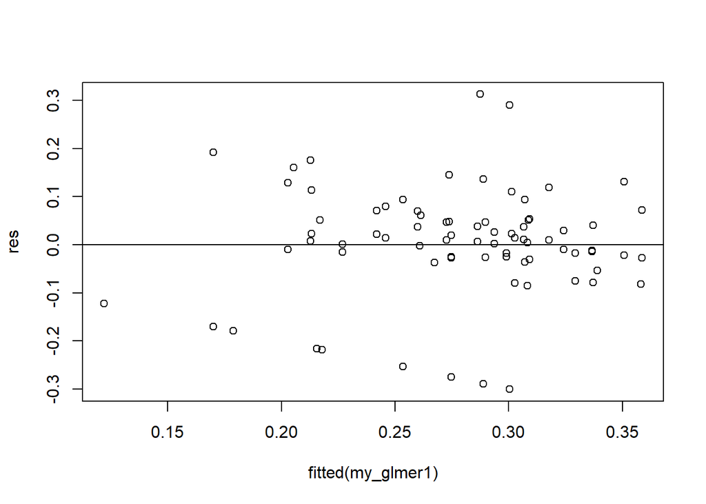

```r
res <- resid(my_glmer1)
#produce residual vs. fitted plot
plot(fitted(my_glmer1), res)

#add a horizontal line at 0
abline(0,0)
```

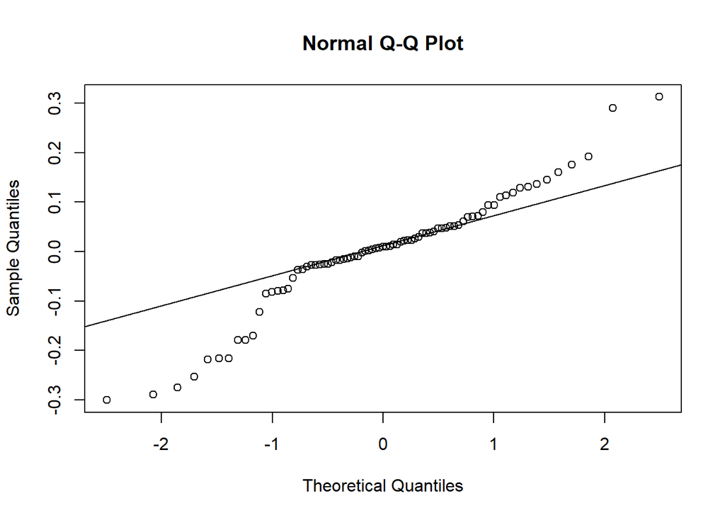

```r
#create Q-Q plot for residuals
qqnorm(res)

#add a straight diagonal line to the plot
qqline(res)
```

### **3h)** Length

#### 1. Visualise differences

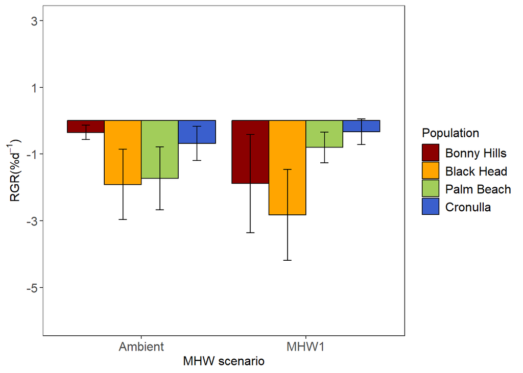

```r
Length_means$Site <- factor(
  Length_means$Site,
  levels = c("Bonny Hills","Black Head","Palm Beach","Cronulla"),
  labels = c(
    "Bonny Hills","Black Head","Palm Beach","Cronulla"
  ))

length_plot <- Length_means  %>%
filter(Treatment != "MHW2") %>%
ggplot(aes(x= Treatment, y=Mean_length, fill = Site)) +
  geom_bar(stat="identity", color="black",
           position=position_dodge()) +
  geom_errorbar(aes(ymin=Mean_length-se, ymax=Mean_length+se), width=.2,
                 position=position_dodge(0.9))+
Theme1 +
labs( y=expression(paste("RGR(%d"^-1*")")), x="MHW scenario", fill = "Population") +
 scale_fill_manual(values = c("darkred", "orange", "darkolivegreen3", "royalblue3"))  +
  scale_y_continuous(limits = c(-6, 3), breaks = seq(-7, 4, by = 2))



length_plot
```

```r
ggsave("length_juv.jpeg", width = 140, height = 80, units = "mm")
```

#### 2. Statistical analyses

1. Keep only alive individuals from MHW1 and ambient

```r
Juveniles_length1 <- filter(Juveniles_length, Treatment != "MHW2")
Juveniles_length1 <- inner_join(Juveniles_length1, Juv_1, by=c("Code"))
Juveniles_length2 <- filter(Juveniles_length1, Survival != "DEAD")
```

2. Run LMM on relative growth rate (diff)

```r
my_lmer <- lmer(sqrt(diff) ~ Site.y*Treatment.y + (1|Location), data=Juveniles_length2)
summary(my_lmer)
```

```
## Linear mixed model fit by REML ['lmerMod']
## Formula: sqrt(diff) ~ Site.y * Treatment.y + (1 | Location)
##    Data: Juveniles_length2
##
## REML criterion at convergence: 15
##
## Scaled residuals:
##     Min      1Q  Median      3Q     Max
## -1.8349 -0.3606 -0.1070  0.5630  2.1325
##
## Random effects:
##  Groups   Name        Variance Std.Dev.
##  Location (Intercept) 0.01489  0.1220
##  Residual             0.06794  0.2607
## Number of obs: 28, groups:  Location, 6
##
## Fixed effects:
##                                   Estimate Std. Error t value
## (Intercept)                        0.48745    0.14575   3.345
## Site.yBonny Hills                  0.11028    0.23705   0.465
## Site.yCronulla                    -0.03022    0.17791  -0.170
## Site.yPalm Beach                   0.21452    0.23687   0.906
## Treatment.yMHW1                    0.14323    0.23994   0.597
## Site.yBonny Hills:Treatment.yMHW1 -0.37396    0.33236  -1.125
## Site.yCronulla:Treatment.yMHW1     0.05631    0.29087   0.194
## Site.yPalm Beach:Treatment.yMHW1  -0.33551    0.35240  -0.952
##
## Correlation of Fixed Effects:
##             (Intr) St.yBH St.yCr St.yPB T.MHW1 S.BH:T S.C:T.
## St.yBnnyHll -0.553
## Site.yCrnll -0.691  0.439
## Sit.yPlmBch -0.547  0.358  0.421
## Trtmnt.MHW1 -0.558  0.353  0.432  0.315
## S.BH:T.MHW1  0.395 -0.692 -0.310 -0.223 -0.728
## St.C:T.MHW1  0.452 -0.286 -0.623 -0.259 -0.831  0.612
## S.PB:T.MHW1  0.388 -0.269 -0.287 -0.681 -0.685  0.510  0.583
```

```r
my_lmer_anova <- car::Anova(my_lmer)
my_lmer_anova
```

```
## Analysis of Deviance Table (Type II Wald chisquare tests)
##
## Response: sqrt(diff)
##                     Chisq Df Pr(>Chisq)
## Site.y             1.2400  3     0.7434
## Treatment.y        0.1030  1     0.7483
## Site.y:Treatment.y 3.4395  3     0.3287
```

3. Check model assumptions

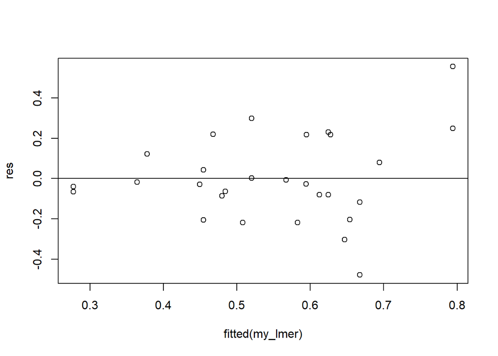

```r
res <- resid(my_lmer)
#produce residual vs. fitted plot
plot(fitted(my_lmer), res)

#add a horizontal line at 0
abline(0,0)
```

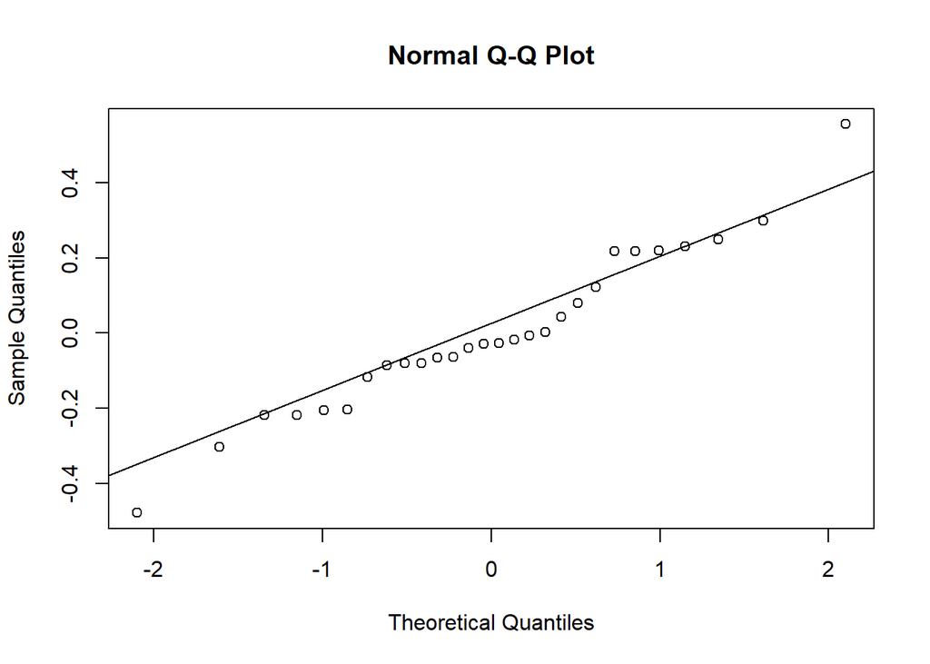

```r
#create Q-Q plot for residuals
qqnorm(res)

#add a straight diagonal line to the plot
qqline(res)
```

### **3i)** C:N ratio

#### 1. Visualise differences

```r
CNresults_mean$Site.x <- factor(
  CNresults_mean$Site.x,
  levels = c("Bonny Hills","Black Head","Palm Beach","Cronulla"),
  labels = c(
    "Bonny Hills","Black Head","Palm Beach","Cronulla"
  ))
```

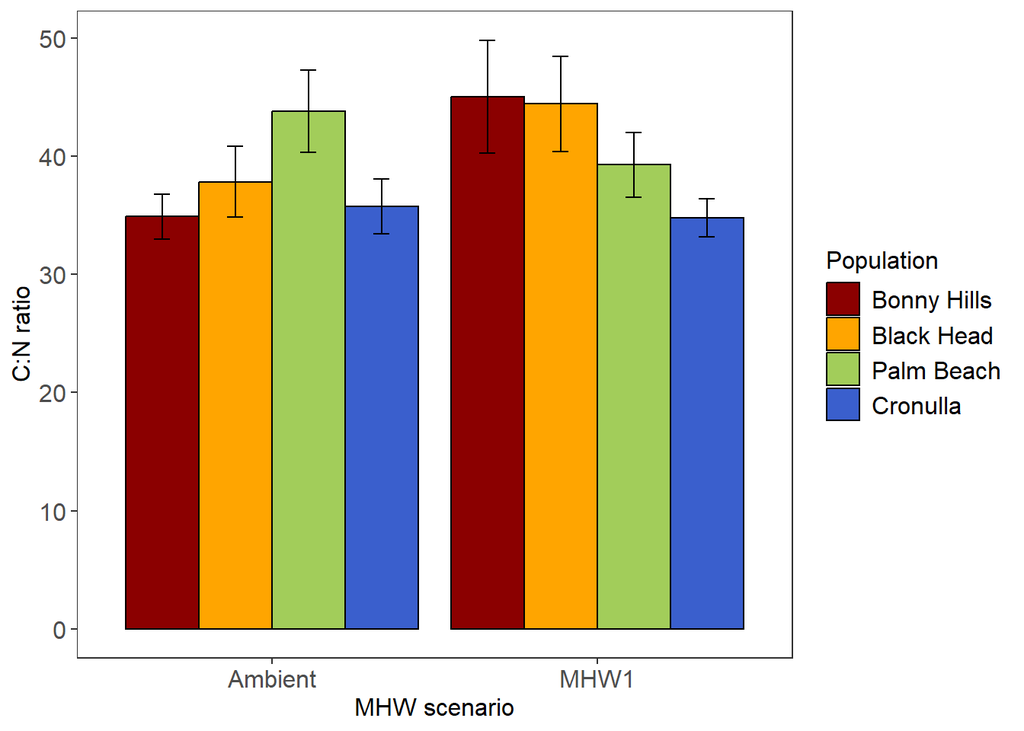

```r
ggplot(data =CNresults_mean, aes(x = Treatment.y, y =Mean_CNratio, fill = Site.x)) +
geom_bar(stat="identity", color="black",
           position=position_dodge()) +
  geom_errorbar(aes(ymin=Mean_CNratio-se, ymax=Mean_CNratio+se), width=.2,
                 position=position_dodge(0.9))+
 scale_fill_manual(values = c("darkred","orange", "darkolivegreen3", "royalblue3")) +
  labs( y=expression(paste("C:N ratio")), x="MHW scenario", fill = "Population") +
  Theme1
```

```r
ggsave("CN.jpeg", width = 150, height = 70, units = "mm")
```

#### 2. Statistical analyses

1. Run LMM for CN ratio

```r
CN_results5 <- inner_join(CN_results4 , Tanks_metadata, by=c("Code"))

my_lmer <- lmer(sqrt(CN_ratio) ~ Site.x*Treatment.y + (1|Location), data=CN_results5)
```

```
## boundary (singular) fit: see help('isSingular')
```

```r
summary(my_lmer)
```

```
## Linear mixed model fit by REML ['lmerMod']
## Formula: sqrt(CN_ratio) ~ Site.x * Treatment.y + (1 | Location)
##    Data: CN_results5
##
## REML criterion at convergence: 80.7
##
## Scaled residuals:
##     Min      1Q  Median      3Q     Max
## -1.7445 -0.6990  0.1454  0.6770  1.6718
##
## Random effects:
##  Groups   Name        Variance Std.Dev.
##  Location (Intercept) 0.000    0.0000
##  Residual             0.339    0.5822
## Number of obs: 46, groups:  Location, 6
##
## Fixed effects:
##                                   Estimate Std. Error t value
## (Intercept)                         6.1246     0.2377  25.768
## Site.xBonny Hills                  -0.2310     0.3361  -0.687
## Site.xCronulla                     -0.1626     0.3361  -0.484
## Site.xPalm Beach                    0.4657     0.3361   1.385
## Treatment.yMHW1                     0.5020     0.3361   1.493
## Site.xBonny Hills:Treatment.yMHW1   0.2770     0.4871   0.569
## Site.xCronulla:Treatment.yMHW1     -0.5748     0.4754  -1.209
## Site.xPalm Beach:Treatment.yMHW1   -0.8416     0.4871  -1.728
##
## Correlation of Fixed Effects:
##             (Intr) St.xBH St.xCr St.xPB T.MHW1 S.BH:T S.C:T.
## St.xBnnyHll -0.707
## Site.xCrnll -0.707  0.500
## Sit.xPlmBch -0.707  0.500  0.500
## Trtmnt.MHW1 -0.707  0.500  0.500  0.500
## S.BH:T.MHW1  0.488 -0.690 -0.345 -0.345 -0.690
## St.C:T.MHW1  0.500 -0.354 -0.707 -0.354 -0.707  0.488
## S.PB:T.MHW1  0.488 -0.345 -0.345 -0.690 -0.690  0.476  0.488
## optimizer (nloptwrap) convergence code: 0 (OK)
## boundary (singular) fit: see help('isSingular')
```

```r
my_lmer_anova <- car::Anova(my_lmer)
my_lmer_anova
```

```
## Analysis of Deviance Table (Type II Wald chisquare tests)
##
## Response: sqrt(CN_ratio)
##                     Chisq Df Pr(>Chisq)
## Site.x             5.5239  3    0.13722
## Treatment.y        1.5911  1    0.20717
## Site.x:Treatment.y 6.4958  3    0.08983 .
## ---
## Signif. codes:  0 '***' 0.001 '**' 0.01 '*' 0.05 '.' 0.1 ' ' 1
```

2. Post-hoc test

```r
emm3 = emmeans(my_lmer, specs = pairwise ~ Site.x, type = "response", adjust = "none")
```

```
## NOTE: Results may be misleading due to involvement in interactions
```

```r
emm3
```

```
## $emmeans
##  Site.x      response   SE   df lower.CL upper.CL
##  Black Head      40.6 2.22 25.6     36.2     45.3
##  Bonny Hills     39.5 2.28 24.5     34.9     44.3
##  Cronulla        35.1 2.03 28.8     31.1     39.4
##  Palm Beach      41.2 2.31 28.2     36.6     46.1
##
## Results are averaged over the levels of: Treatment.y
## Degrees-of-freedom method: kenward-roger
## Confidence level used: 0.95
## Intervals are back-transformed from the sqrt scale
##
## $contrasts
##  contrast                 estimate    SE   df t.ratio p.value
##  Black Head - Bonny Hills   0.0925 0.247 36.4   0.375  0.7100
##  Black Head - Cronulla      0.4499 0.240 35.3   1.873  0.0693
##  Black Head - Palm Beach   -0.0449 0.247 35.8  -0.181  0.8571
##  Bonny Hills - Cronulla     0.3574 0.248 37.2   1.440  0.1582
##  Bonny Hills - Palm Beach  -0.1374 0.252 35.4  -0.546  0.5886
##  Cronulla - Palm Beach     -0.4948 0.246 36.0  -2.011  0.0519
##
## Results are averaged over the levels of: Treatment.y
## Note: contrasts are still on the sqrt scale
## Degrees-of-freedom method: kenward-roger
```

3. Check model assumptions

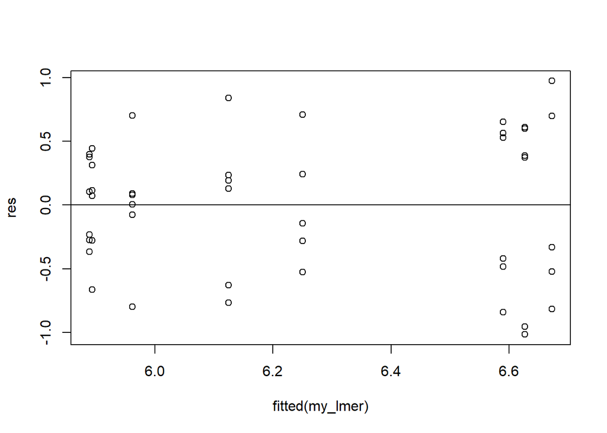

```r
res <- resid(my_lmer)
#produce residual vs. fitted plot
plot(fitted(my_lmer), res)

#add a horizontal line at 0
abline(0,0)
```

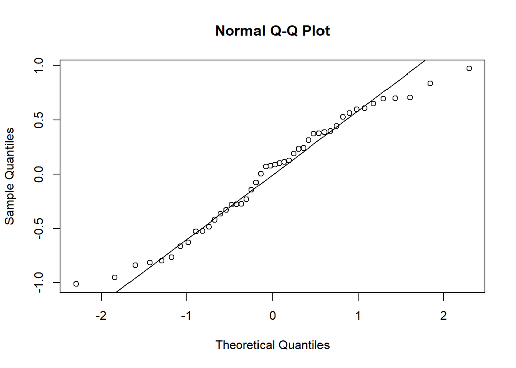

```r
#create Q-Q plot for residuals
qqnorm(res)

#add a straight diagonal line to the plot
qqline(res)
```

### **3j)** Carbon content

#### 1. Visualise differences

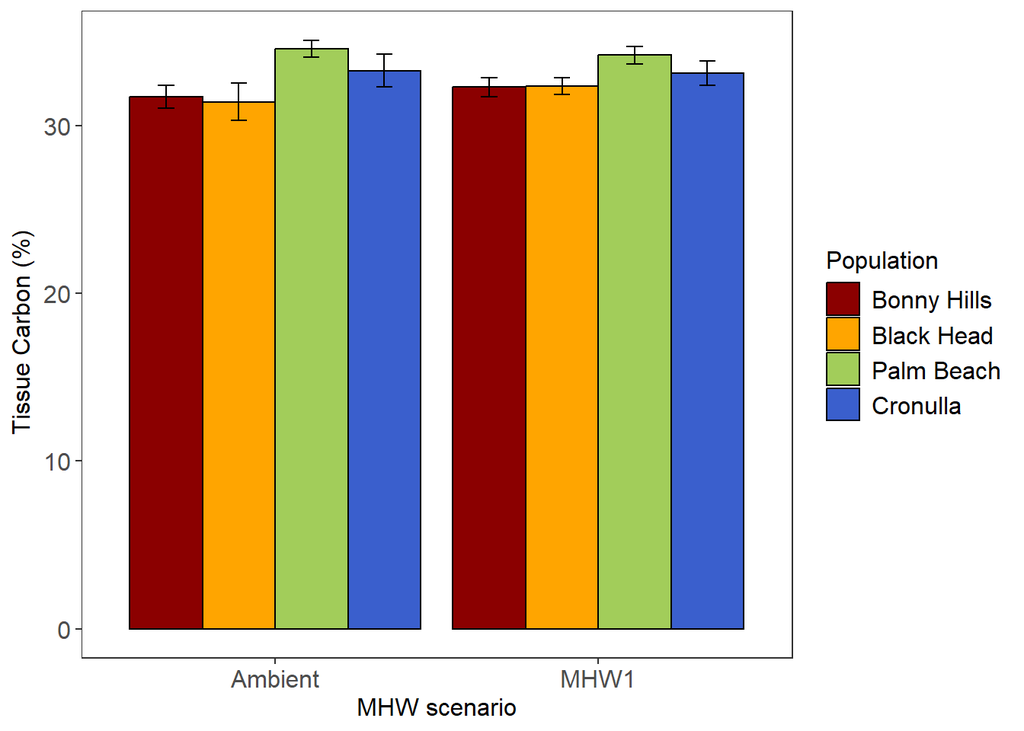

```r
ggplot(data =CNresults_mean, aes(x = Treatment.y, y =Mean_C, fill = Site.x)) +
geom_bar(stat="identity", color="black",
           position=position_dodge()) +
  geom_errorbar(aes(ymin=Mean_C-se_C, ymax=Mean_C+se_C), width=.2,
                 position=position_dodge(0.9))+
 scale_fill_manual(values = c("darkred","orange", "darkolivegreen3", "royalblue3")) +
  labs( y=expression(paste("Tissue Carbon (%)")), x="MHW scenario", fill = "Population") +
  Theme1
```

```r
ggsave("Carbon.jpeg", width = 150, height = 70, units = "mm")
```

#### 2. Statistical analyses

1. Run LMM for carbon content

```r
my_lmer <- lmer(sqrt(C) ~ Site.x*Treatment.y + (1|Location), data=CN_results5)
```

```
## boundary (singular) fit: see help('isSingular')
```

```r
summary(my_lmer)
```

```
## Linear mixed model fit by REML ['lmerMod']
## Formula: sqrt(C) ~ Site.x * Treatment.y + (1 | Location)
##    Data: CN_results5
##
## REML criterion at convergence: -17.8
##
## Scaled residuals:
##      Min       1Q   Median       3Q      Max
## -2.53125 -0.56353 -0.02449  0.62616  2.04468
##
## Random effects:
##  Groups   Name        Variance Std.Dev.
##  Location (Intercept) 0.00000  0.0000
##  Residual             0.02539  0.1593
## Number of obs: 46, groups:  Location, 6
##
## Fixed effects:
##                                   Estimate Std. Error t value
## (Intercept)                        5.60043    0.06505  86.097
## Site.xBonny Hills                  0.03056    0.09199   0.332
## Site.xCronulla                     0.16494    0.09199   1.793
## Site.xPalm Beach                   0.27927    0.09199   3.036
## Treatment.yMHW1                    0.08698    0.09199   0.945
## Site.xBonny Hills:Treatment.yMHW1 -0.03534    0.13331  -0.265
## Site.xCronulla:Treatment.yMHW1    -0.10017    0.13010  -0.770
## Site.xPalm Beach:Treatment.yMHW1  -0.11961    0.13331  -0.897
##
## Correlation of Fixed Effects:
##             (Intr) St.xBH St.xCr St.xPB T.MHW1 S.BH:T S.C:T.
## St.xBnnyHll -0.707
## Site.xCrnll -0.707  0.500
## Sit.xPlmBch -0.707  0.500  0.500
## Trtmnt.MHW1 -0.707  0.500  0.500  0.500
## S.BH:T.MHW1  0.488 -0.690 -0.345 -0.345 -0.690
## St.C:T.MHW1  0.500 -0.354 -0.707 -0.354 -0.707  0.488
## S.PB:T.MHW1  0.488 -0.345 -0.345 -0.690 -0.690  0.476  0.488
## optimizer (nloptwrap) convergence code: 0 (OK)
## boundary (singular) fit: see help('isSingular')
```

```r
my_lmer_anova <- car::Anova(my_lmer)
my_lmer_anova
```

```
## Analysis of Deviance Table (Type II Wald chisquare tests)
##
## Response: sqrt(C)
##                      Chisq Df Pr(>Chisq)
## Site.x             14.3015  3   0.002522 **
## Treatment.y         0.2566  1   0.612462
## Site.x:Treatment.y  1.0587  3   0.787058
## ---
## Signif. codes:  0 '***' 0.001 '**' 0.01 '*' 0.05 '.' 0.1 ' ' 1
```

2. Post-hoc test

```r
emm3 = emmeans(my_lmer, specs = pairwise ~ Site.x, type = "response", adjust = "none")
```

```
## NOTE: Results may be misleading due to involvement in interactions
```

```r
emm3
```

```
## $emmeans
##  Site.x      response    SE   df lower.CL upper.CL
##  Black Head      31.9 0.538 25.6     30.8     33.0
##  Bonny Hills     32.0 0.562 24.5     30.9     33.2
##  Cronulla        33.2 0.539 28.8     32.1     34.3
##  Palm Beach      34.4 0.577 28.2     33.2     35.6
##
## Results are averaged over the levels of: Treatment.y
## Degrees-of-freedom method: kenward-roger
## Confidence level used: 0.95
## Intervals are back-transformed from the sqrt scale
##
## $contrasts
##  contrast                 estimate     SE   df t.ratio p.value
##  Black Head - Bonny Hills  -0.0129 0.0676 36.4  -0.191  0.8498
##  Black Head - Cronulla     -0.1149 0.0657 35.3  -1.747  0.0893
##  Black Head - Palm Beach   -0.2195 0.0677 35.8  -3.243  0.0026
##  Bonny Hills - Cronulla    -0.1020 0.0679 37.2  -1.501  0.1418
##  Bonny Hills - Palm Beach  -0.2066 0.0689 35.4  -3.000  0.0049
##  Cronulla - Palm Beach     -0.1046 0.0673 36.0  -1.553  0.1291
##
## Results are averaged over the levels of: Treatment.y
## Note: contrasts are still on the sqrt scale
## Degrees-of-freedom method: kenward-roger
```

3. Check model assumptions

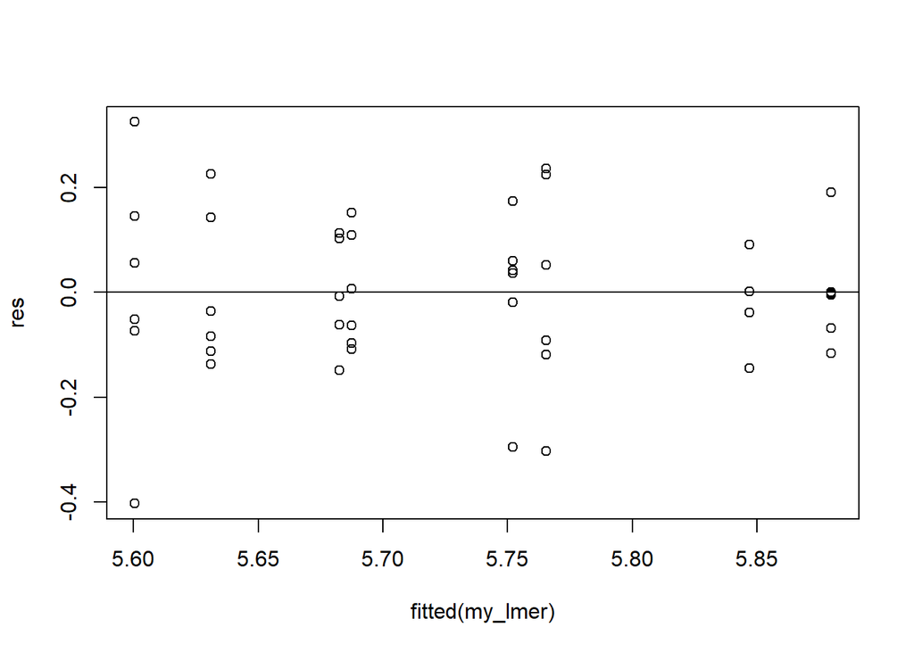

```r
res <- resid(my_lmer)
#produce residual vs. fitted plot
plot(fitted(my_lmer), res)

#add a horizontal line at 0
abline(0,0)
```

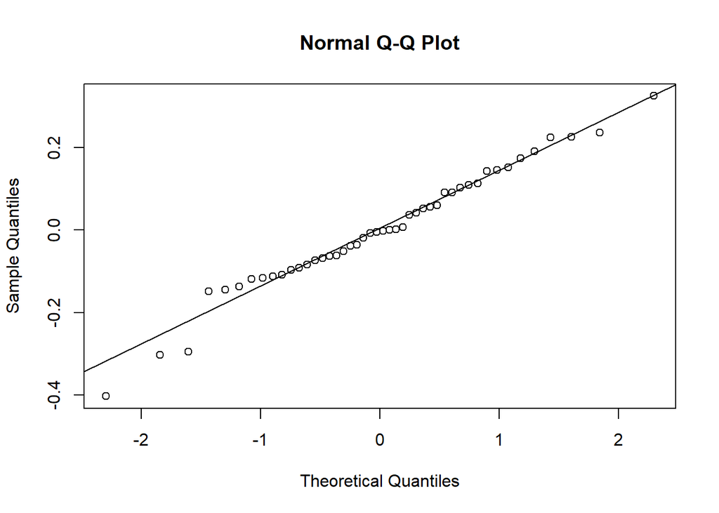

```r
#create Q-Q plot for residuals
qqnorm(res)

#add a straight diagonal line to the plot
qqline(res)
```

### **3k)** Nitrogen content

#### 1. Visualise differences

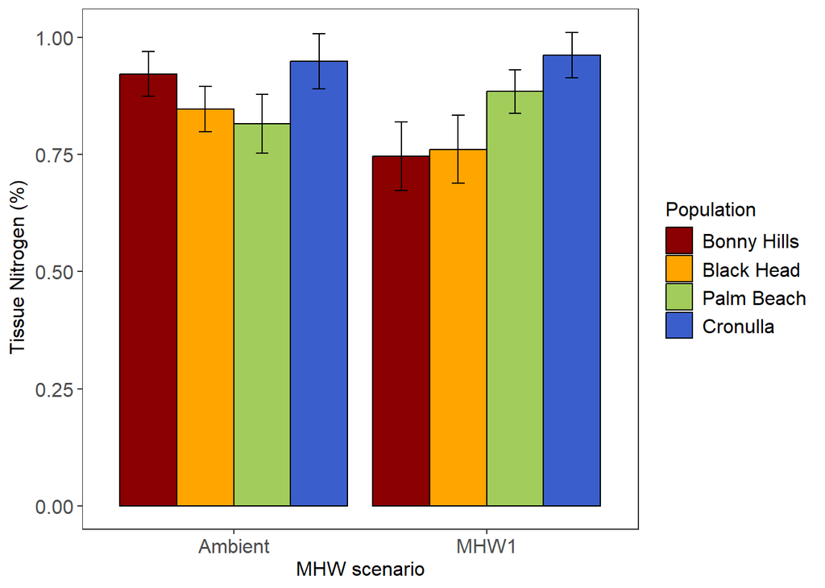

```r
ggplot(data =CNresults_mean, aes(x = Treatment.y, y =Mean_N, fill = Site.x)) +
geom_bar(stat="identity", color="black",
           position=position_dodge()) +
  geom_errorbar(aes(ymin=Mean_N-se_N, ymax=Mean_N+se_N), width=.2,
                 position=position_dodge(0.9))+
 scale_fill_manual(values = c("darkred","orange", "darkolivegreen3", "royalblue3")) +
   labs( y=expression(paste("Tissue Nitrogen (%)")), x="MHW scenario", fill = "Population") +
  Theme1
```

```r
ggsave("Nitrogen.jpeg", width = 150, height = 70, units = "mm")
```

#### 2. Statistical analyses

1. Run LMM for nitrogen content

```r
my_lmer <- lmer(sqrt(N) ~ Treatment.y*Site.x + (1|Location), data=CN_results5)
```

```
## boundary (singular) fit: see help('isSingular')
```

```r
summary(my_lmer)
```

```
## Linear mixed model fit by REML ['lmerMod']
## Formula: sqrt(N) ~ Treatment.y * Site.x + (1 | Location)
##    Data: CN_results5
##
## REML criterion at convergence: -74.5
##
## Scaled residuals:
##     Min      1Q  Median      3Q     Max
## -1.3832 -0.8255 -0.1673  0.5817  1.6883
##
## Random effects:
##  Groups   Name        Variance Std.Dev.
##  Location (Intercept) 0.000000 0.00000
##  Residual             0.005702 0.07551
## Number of obs: 46, groups:  Location, 6
##
## Fixed effects:
##                                   Estimate Std. Error t value
## (Intercept)                        0.91838    0.03083  29.792
## Treatment.yMHW1                   -0.05087    0.04360  -1.167
## Site.xBonny Hills                  0.04012    0.04360   0.920
## Site.xCronulla                     0.05320    0.04360   1.220
## Site.xPalm Beach                  -0.01891    0.04360  -0.434
## Treatment.yMHW1:Site.xBonny Hills -0.04819    0.06318  -0.763
## Treatment.yMHW1:Site.xCronulla     0.05836    0.06165   0.947
## Treatment.yMHW1:Site.xPalm Beach   0.09028    0.06318   1.429
##
## Correlation of Fixed Effects:
##             (Intr) Tr.MHW1 St.xBH St.xCr St.xPB T.MHWH T.MHW1:
## Trtmnt.MHW1 -0.707
## St.xBnnyHll -0.707  0.500
## Site.xCrnll -0.707  0.500   0.500
## Sit.xPlmBch -0.707  0.500   0.500  0.500
## T.MHW1:S.BH  0.488 -0.690  -0.690 -0.345 -0.345
## Tr.MHW1:S.C  0.500 -0.707  -0.354 -0.707 -0.354  0.488
## T.MHW1:S.PB  0.488 -0.690  -0.345 -0.345 -0.690  0.476  0.488
## optimizer (nloptwrap) convergence code: 0 (OK)
## boundary (singular) fit: see help('isSingular')
```

```r
my_lmer_anova <- car::Anova(my_lmer)
my_lmer_anova
```

```
## Analysis of Deviance Table (Type II Wald chisquare tests)
##
## Response: sqrt(N)
##                     Chisq Df Pr(>Chisq)
## Treatment.y        1.3135  1    0.25176
## Site.x             7.9505  3    0.04705 *
## Treatment.y:Site.x 5.5152  3    0.13773
## ---
## Signif. codes:  0 '***' 0.001 '**' 0.01 '*' 0.05 '.' 0.1 ' ' 1
```

2. Post-hoc test

```r
emm3 = emmeans(my_lmer, specs = pairwise ~ Site.x, type = "response", adjust = "none")
```

```
## NOTE: Results may be misleading due to involvement in interactions
```

```r
emm3
```

```
## $emmeans
##  Site.x      response     SE   df lower.CL upper.CL
##  Black Head     0.797 0.0404 25.6    0.716    0.883
##  Bonny Hills    0.826 0.0428 24.5    0.740    0.917
##  Cronulla       0.951 0.0433 28.8    0.865    1.042
##  Palm Beach     0.845 0.0429 28.2    0.759    0.935
##
## Results are averaged over the levels of: Treatment.y
## Degrees-of-freedom method: kenward-roger
## Confidence level used: 0.95
## Intervals are back-transformed from the sqrt scale
##
## $contrasts
##  contrast                 estimate     SE   df t.ratio p.value
##  Black Head - Bonny Hills  -0.0160 0.0320 36.4  -0.500  0.6198
##  Black Head - Cronulla     -0.0824 0.0312 35.3  -2.645  0.0121
##  Black Head - Palm Beach   -0.0262 0.0321 35.8  -0.818  0.4188
##  Bonny Hills - Cronulla    -0.0664 0.0322 37.2  -2.061  0.0463
##  Bonny Hills - Palm Beach  -0.0102 0.0326 35.4  -0.313  0.7562
##  Cronulla - Palm Beach      0.0562 0.0319 36.0   1.759  0.0870
##
## Results are averaged over the levels of: Treatment.y
## Note: contrasts are still on the sqrt scale
## Degrees-of-freedom method: kenward-roger
```

3. Check model assumptions

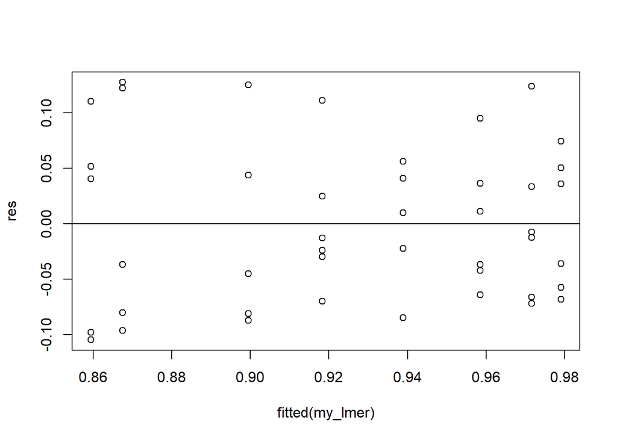

```r
res <- resid(my_lmer)
#produce residual vs. fitted plot
plot(fitted(my_lmer), res)

#add a horizontal line at 0
abline(0,0)
```

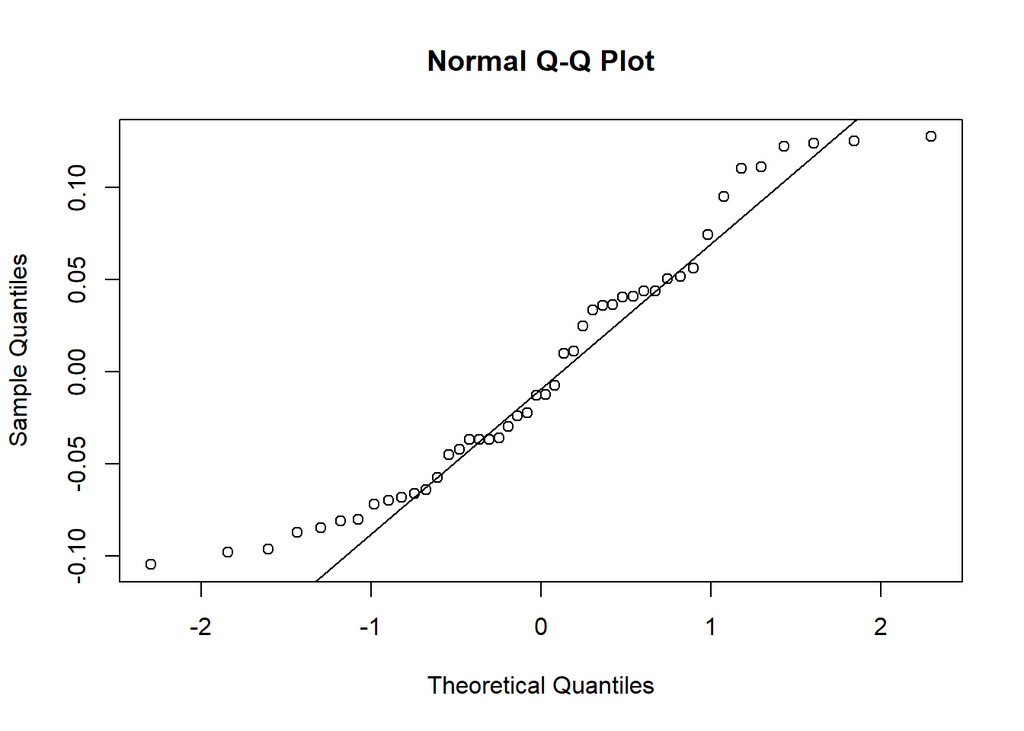

```r
#create Q-Q plot for residuals
qqnorm(res)

#add a straight diagonal line to the plot
qqline(res)
```

### **3l)** Chlorophyll a

#### 1. Visualise differences

```r
Pigments_mean$Site_Code.x <- factor(
  Pigments_mean$Site_Code.x,
  levels = c("Bonny Hills","Black Head","Palm Beach","Cronulla"),
  labels = c("Bonny Hills","Black Head","Palm Beach","Cronulla"
  ))
Pigments_mean4 <- filter(Pigments_mean, Treatment.y != "Initial")
```

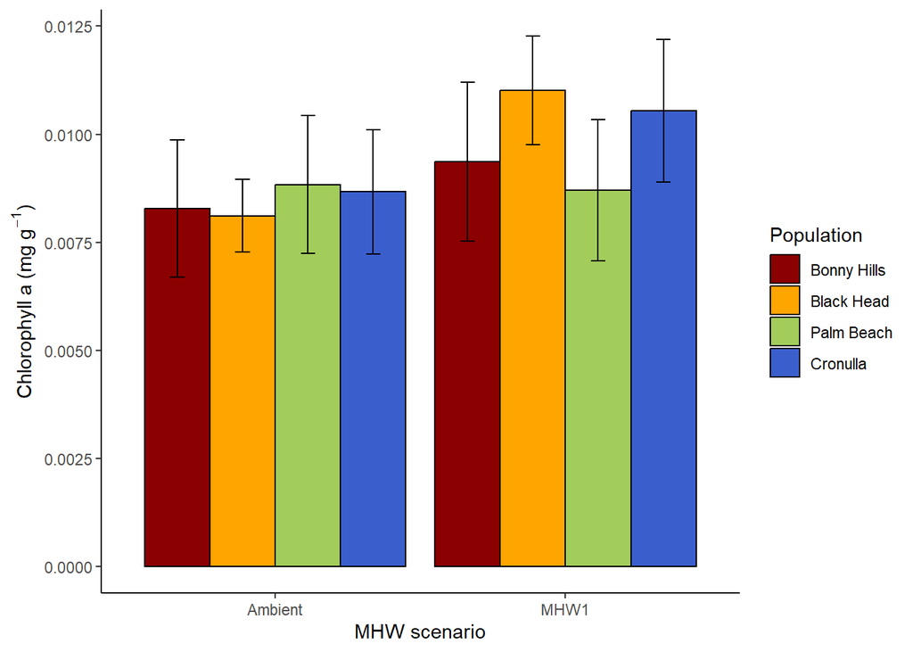

```r
ggplot(data =Pigments_mean4, aes(x = Treatment.y, y =Mean_chla, fill = Site_Code.x)) +
geom_bar(stat="identity", color="black",
           position=position_dodge()) +
  geom_errorbar(aes(ymin=Mean_chla-se_chla, ymax=Mean_chla+se_chla), width=.2,
                 position=position_dodge(0.9))+
 scale_fill_manual(values = c("darkred","orange", "darkolivegreen3", "royalblue3")) +
  labs( y=expression(paste("Chlorophyll a (mg g"^-1*")")), x="MHW scenario", fill = "Population") +
  theme_classic()
```

```r
ggsave("chla.jpeg", width = 150, height = 70, units = "mm")
```

#### 2. Statistical analyses

1. Run LMM for chlorophyll-a

```r
Pigments7 <- inner_join(Pigments6 , Tanks_metadata, by=c("Code"))
my_lmer <- lmer(sqrt(chla) ~ Site_Code.x*Treatment.y + (1|Location), data=Pigments7) # Location is shelf
```

```
## boundary (singular) fit: see help('isSingular')
```

```r
summary(my_lmer)
```

```
## Linear mixed model fit by REML ['lmerMod']
## Formula: sqrt(chla) ~ Site_Code.x * Treatment.y + (1 | Location)
##    Data: Pigments7
##
## REML criterion at convergence: -216.7
##
## Scaled residuals:
##      Min       1Q   Median       3Q      Max
## -1.45970 -0.69387 -0.07341  0.60190  2.59818
##
## Random effects:
##  Groups   Name        Variance Std.Dev.
##  Location (Intercept) 0.000000 0.00000
##  Residual             0.000421 0.02052
## Number of obs: 55, groups:  Location, 6
##
## Fixed effects:
##                                         Estimate Std. Error t value
## (Intercept)                             0.089480   0.008377  10.682
## Site_Code.xBonny Hills                 -0.001068   0.011081  -0.096
## Site_Code.xCronulla                     0.001659   0.011416   0.145
## Site_Code.xPalm Beach                   0.002309   0.010814   0.214
## Treatment.yMHW1                         0.014446   0.011847   1.219
## Site_Code.xBonny Hills:Treatment.yMHW1 -0.008125   0.016648  -0.488
## Site_Code.xCronulla:Treatment.yMHW1    -0.005035   0.015910  -0.317
## Site_Code.xPalm Beach:Treatment.yMHW1  -0.015115   0.016040  -0.942
##
## Correlation of Fixed Effects:
##             (Intr) St_C.BH St_C.C St_C.PB T.MHW1 S_C.BH: S_C.C:
## St_Cd.xBnnH -0.756
## St_Cd.xCrnl -0.734  0.555
## St_Cd.xPlmB -0.775  0.586   0.568
## Trtmnt.MHW1 -0.707  0.535   0.519  0.548
## S_C.BH:T.MH  0.503 -0.666  -0.369 -0.390  -0.712
## S_C.C:T.MHW  0.527 -0.398  -0.718 -0.408  -0.745  0.530
## S_C.PB:T.MH  0.522 -0.395  -0.383 -0.674  -0.739  0.526   0.550
## optimizer (nloptwrap) convergence code: 0 (OK)
## boundary (singular) fit: see help('isSingular')
```

```r
my_lmer_anova <- car::Anova(my_lmer)
my_lmer_anova
```

```
## Analysis of Deviance Table (Type II Wald chisquare tests)
##
## Response: sqrt(chla)
##                          Chisq Df Pr(>Chisq)
## Site_Code.x             0.6091  3     0.8943
## Treatment.y             1.6159  1     0.2037
## Site_Code.x:Treatment.y 0.9524  3     0.8128
```

2. Check model assumptions

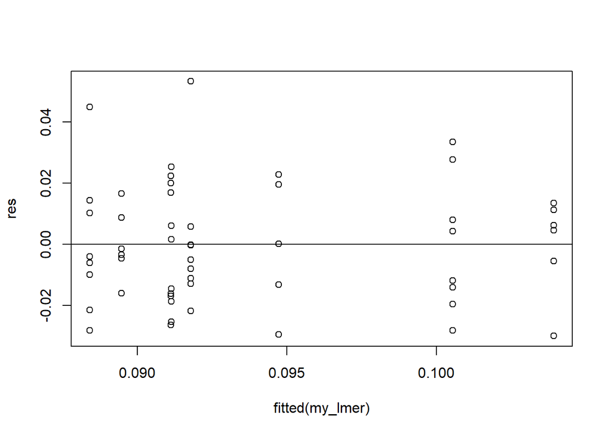

```r
res <- resid(my_lmer)
#produce residual vs. fitted plot
plot(fitted(my_lmer), res)

#add a horizontal line at 0
abline(0,0)
```

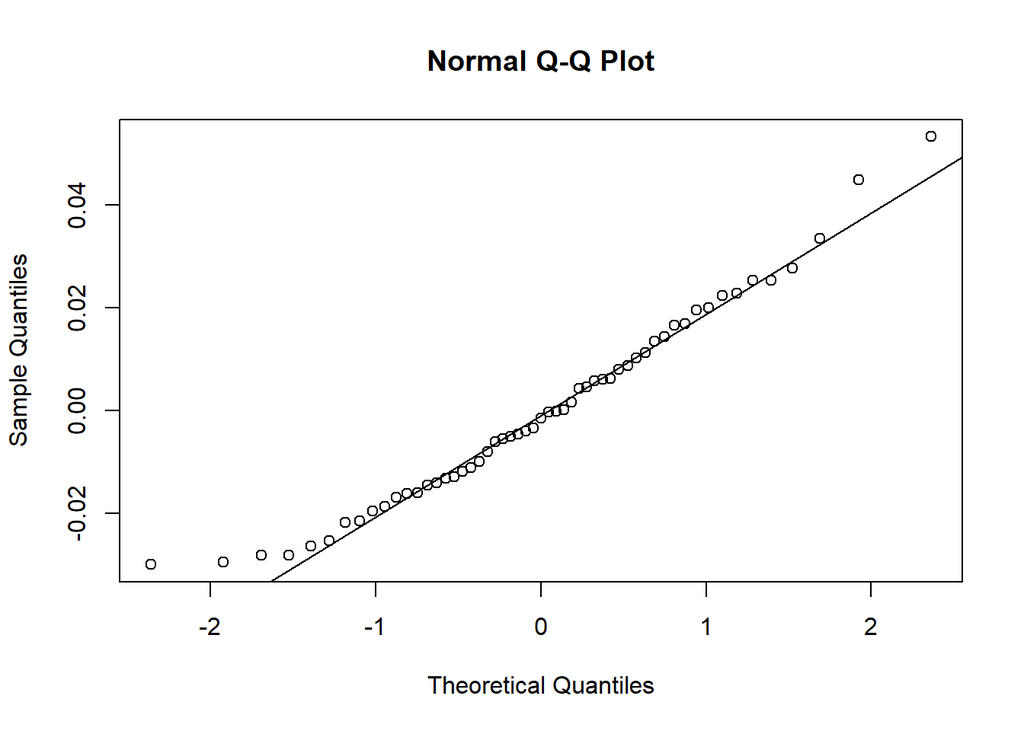

```r
#create Q-Q plot for residuals
qqnorm(res)

#add a straight diagonal line to the plot
qqline(res)
```

### **3m)** Chlorophyll c

#### 1. Visualise differences

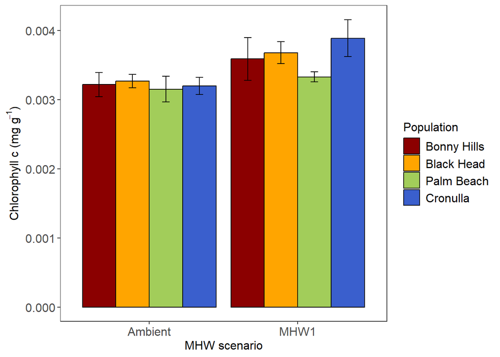

```r
ggplot(data =Pigments_mean, aes(x = Treatment.y, y =Mean_chlc, fill = Site_Code.x)) +
geom_bar(stat="identity", color="black",
           position=position_dodge()) +
  geom_errorbar(aes(ymin=Mean_chlc-se_chlc, ymax=Mean_chlc+se_chlc), width=.2,
                 position=position_dodge(0.9))+
 scale_fill_manual(values = c("darkred","orange", "darkolivegreen3", "royalblue3")) +
  labs( y=expression(paste("Chlorophyll c (mg g"^-1*")")), x="MHW scenario", fill = "Population") +
  Theme1
```

```r
ggsave("chlc.jpeg", width = 150, height = 70, units = "mm")
```

#### 2. Statistical analyses

1. Run LMM for chlorophyll-c

```r
my_lmer <- lmer(sqrt(chlc) ~ Site_Code.x*Treatment.y + (1|Location), data=Pigments7)
summary(my_lmer)
```

```
## Linear mixed model fit by REML ['lmerMod']
## Formula: sqrt(chlc) ~ Site_Code.x * Treatment.y + (1 | Location)
##    Data: Pigments7
##
## REML criterion at convergence: -365.6
##
## Scaled residuals:
##     Min      1Q  Median      3Q     Max
## -2.0758 -0.5949  0.0172  0.5566  2.3716
##
## Random effects:
##  Groups   Name        Variance  Std.Dev.
##  Location (Intercept) 9.915e-07 0.0009958
##  Residual             1.697e-05 0.0041198
## Number of obs: 55, groups:  Location, 6
##
## Fixed effects:
##                                          Estimate Std. Error t value
## (Intercept)                             0.0569419  0.0017531  32.480
## Site_Code.xBonny Hills                 -0.0003781  0.0022305  -0.170
## Site_Code.xCronulla                    -0.0007498  0.0022949  -0.327
## Site_Code.xPalm Beach                  -0.0008956  0.0021836  -0.410
## Treatment.yMHW1                         0.0037292  0.0024006   1.553
## Site_Code.xBonny Hills:Treatment.yMHW1 -0.0002664  0.0033573  -0.079
## Site_Code.xCronulla:Treatment.yMHW1     0.0022075  0.0032029   0.689
## Site_Code.xPalm Beach:Treatment.yMHW1  -0.0019781  0.0032441  -0.610
##
## Correlation of Fixed Effects:
##             (Intr) St_C.BH St_C.C St_C.PB T.MHW1 S_C.BH: S_C.C:
## St_Cd.xBnnH -0.731
## St_Cd.xCrnl -0.705  0.553
## St_Cd.xPlmB -0.752  0.588   0.565
## Trtmnt.MHW1 -0.685  0.536   0.515  0.550
## S_C.BH:T.MH  0.483 -0.662  -0.369 -0.386  -0.710
## S_C.C:T.MHW  0.504 -0.397  -0.717 -0.406  -0.742  0.531
## S_C.PB:T.MH  0.504 -0.397  -0.382 -0.674  -0.740  0.526   0.552
```

```r
my_lmer_anova <- car::Anova(my_lmer)
my_lmer_anova
```

```
## Analysis of Deviance Table (Type II Wald chisquare tests)
##
## Response: sqrt(chlc)
##                           Chisq Df Pr(>Chisq)
## Site_Code.x              2.1338  3    0.54511
## Treatment.y             10.7194  1    0.00106 **
## Site_Code.x:Treatment.y  1.9035  3    0.59268
## ---
## Signif. codes:  0 '***' 0.001 '**' 0.01 '*' 0.05 '.' 0.1 ' ' 1
```

2. Post-hoc test

```r
emm3 = emmeans(my_lmer, specs = pairwise ~ Treatment.y, type = "response", adjust = "none")
```

```
## NOTE: Results may be misleading due to involvement in interactions
```

```r
emm3
```

```
## $emmeans
##  Treatment.y response       SE    df lower.CL upper.CL
##  Ambient      0.00319 0.000103  8.32  0.00295  0.00343
##  MHW1         0.00362 0.000116 12.14  0.00337  0.00388
##
## Results are averaged over the levels of: Site_Code.x
## Degrees-of-freedom method: kenward-roger
## Confidence level used: 0.95
## Intervals are back-transformed from the sqrt scale
##
## $contrasts
##  contrast       estimate      SE   df t.ratio p.value
##  Ambient - MHW1 -0.00372 0.00117 46.4  -3.170  0.0027
##
## Results are averaged over the levels of: Site_Code.x
## Note: contrasts are still on the sqrt scale
## Degrees-of-freedom method: kenward-roger
```

3. Check model assumptions

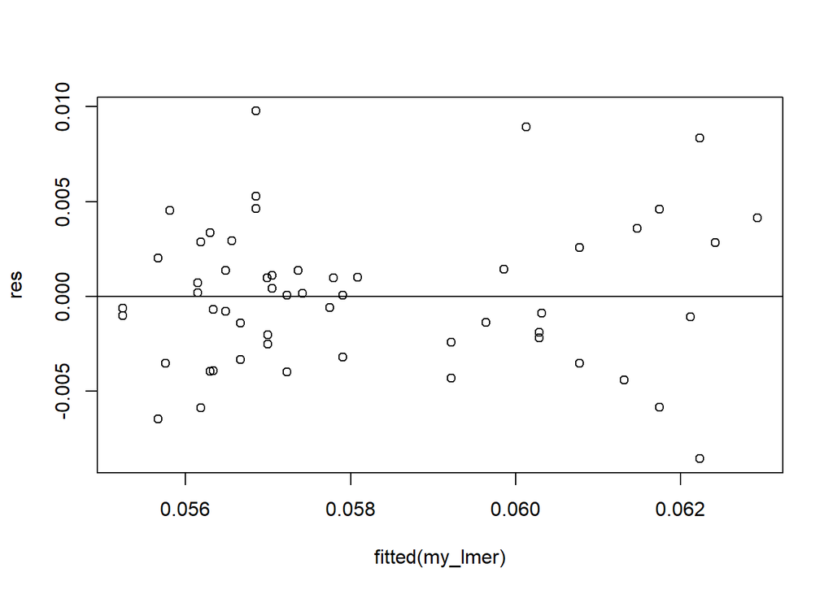

```r
res <- resid(my_lmer)
#produce residual vs. fitted plot
plot(fitted(my_lmer), res)

#add a horizontal line at 0
abline(0,0)
```

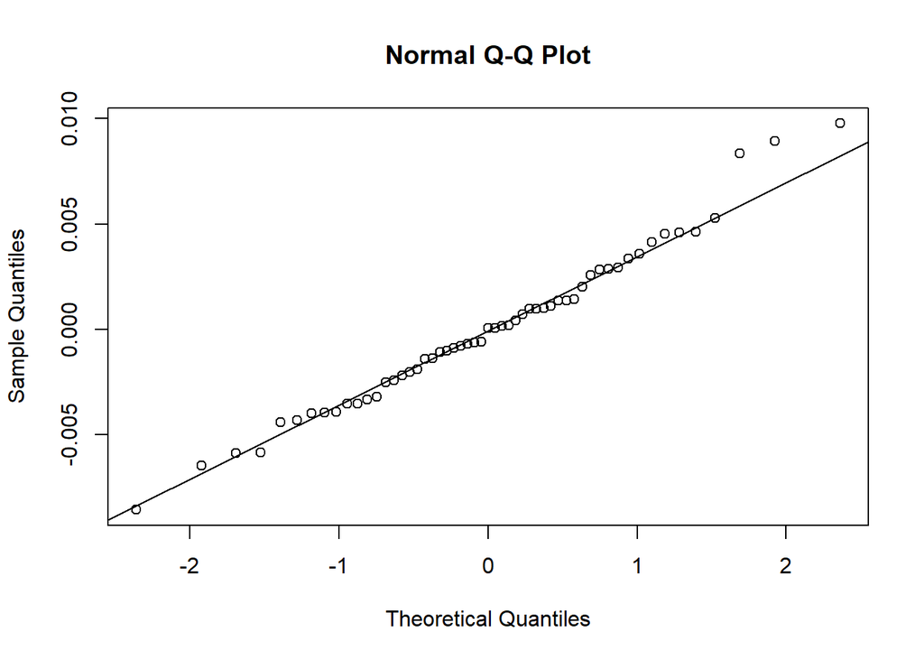

```r
#create Q-Q plot for residuals
qqnorm(res)

#add a straight diagonal line to the plot
qqline(res)
```

### **3n)** Fucoxanthin

#### 1. Visualise differences

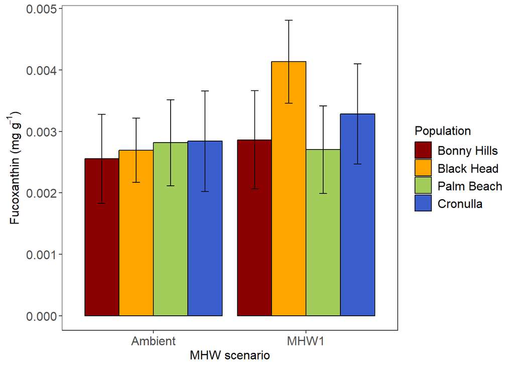

```r
ggplot(data =Pigments_mean, aes(x = Treatment.y, y =Mean_Fucoxanthin, fill = Site_Code.x)) +
geom_bar(stat="identity", color="black",
           position=position_dodge()) +
  geom_errorbar(aes(ymin=Mean_Fucoxanthin-se_Fucoxanthin, ymax=Mean_Fucoxanthin+se_Fucoxanthin), width=.2,
                 position=position_dodge(0.9))+
 scale_fill_manual(values = c("darkred","orange", "darkolivegreen3", "royalblue3")) +
  labs( y=expression(paste("Fucoxanthin (mg g"^-1*")")), x="MHW scenario", fill = "Population") +
  Theme1
```

```r
ggsave("fucoxanthin.jpeg", width = 150, height = 70, units = "mm")
```